# Ch. 14 Aerodynamics — fluidpy

← All chapters🎮 All explainers

← PreviousNext →

[▶ Open in Colab](https://colab.research.google.com/github/shammun/fluidpy/blob/main/notebooks/ch14_aerodynamics_colab.ipynb) ↓ Download .ipynb [View on GitHub](https://github.com/shammun/fluidpy/blob/main/notebooks/ch14_aerodynamics.ipynb)

## Interactive explainers in this chapter

🎮 1**Where do camber and thickness come from?**Drag the centre of a circle and watch one map turn it into a plate, an arc, a fin or a wing section.🎮 2**Which circulation does a wing choose?**Slide the circulation and watch the rear stagnation point crawl to the sharp tail — the only place where the edge speed stays finite.🎮 3**Where does a wing's circulation come from?**Start, stop or pitch the foil and watch it shed a vortex that exactly cancels what it gains.🎮 4**Is a wing pushed up or pulled up?**Turn the angle of attack and watch the suction peak, the pressure loop and the lift grow together.🎮 5**Does more angle always mean more lift?**Drag the angle of attack along the lift curve: camber shifts the line, the slope stays 2π, and stall ends it.🎮 6**How can there be drag without friction?**Build a wing from nested horseshoe vortices, add up their downwash at one station, and watch the lift lean back.🎮 7**What makes one wing better than another?**Choose a planform and a twist; a small linear solve returns the loading as sine amplitudes — the first lifts, the rest only drag.🎮 8**Why are glider wings so long and thin?**Stretch the span and move the speed: induced drag falls with span and speed, profile drag rises with speed, and the best glide is where they meet.🎮 9**How can a boat sail against the wind?**Turn the course toward the wind and watch the apparent wind swing forward and the sail's lift tilt — then see the same triangle on a fish tail and a bird's wing.

# Chapter 14 — Aerodynamics

*Fluid Mechanics, 5th edition — Pijush K. Kundu, Ira M. Cohen, David R. Dowling (2012).* This notebook teaches every new idea of the chapter with plain words, step-by-step mathematics, small worked examples, tested Python from the `fluidpy` package, figures, animations and interactive explainers. It does not reproduce the book's text or figures; equations are cited by their numbers so you can follow along in your copy.

**The big idea in one paragraph**

A wing weighing a few tonnes holds up an aircraft weighing hundreds. How? Chapter 6 gave half the answer: a body in an ideal stream feels a force at right angles to the stream whenever the flow circulates round it, $L=\rho U\Gamma$ (6.62) — but it left the circulation $\Gamma$ free. This chapter supplies the missing half in three sentences. **Lift is circulation.** **The sharp trailing edge chooses it** — viscosity, acting only there, lets exactly one circulation survive, and that gives a lift that grows by $2\pi$ for every radian of incidence. **The wing tips make you pay for it** — the circulation cannot stop at the tips, so it trails behind as two vortices whose downwash tilts the lift backward: a drag that exists even without friction, and that falls as the wing gets long and slender. The last two sections turn the first sentence round: a fish's tail, a bird's wing and a sail all move a wing *across* the stream so that its lift leans forward and becomes thrust.

**Road map** — the new ideas of this chapter, in the order they build on each other:

1. **The wing in numbers** — span, area, aspect ratio, and the lift coefficient level flight demands (`C01`).
2. **The Kutta condition** — ideal flow allows any circulation; the sharp trailing edge allows one (`C02`).
3. **The starting vortex** — the wing gets its circulation by shedding the opposite one (`C03`).
4. **The Zhukhovsky airfoil** — a circle moved off-centre and pushed through one map (`C04`).
5. **The flow round the airfoil** — the circle's flow, rescaled point by point (`C05`).
6. **The lift of the airfoil** — $2\pi$ per radian, shifted by the camber (`C06`).
7. **Surface speed and pressure** — the lift as the area of a pressure loop (`C07`).
8. **Bound vortex and trailing filaments** — what leaves the wing where the circulation drops (`C08`).
9. **Downwash** — the sinking air the wake makes at the wing (`C09`).
10. **Induced drag** — lift tilted back: drag without friction (`C10`).
11. **The sine series and its downwash** — one singular integral, done once (`C11`).
12. **The lifting-line equation** — N stations, N sines, one linear solve (`C12`).
13. **Lift and induced drag from the coefficients** — lift in the first sine, drag in all (`C13`).
14. **The elliptic loading** — uniform downwash, least drag, and why span matters (`C14`).
15. **The drag breakdown and the polar** — profile against induced, and the best glide (`C15`).
16. **Thrust from lift** — a fish tail, a wing beat and a sail (`C16`).

**What you should already know** (each is recapped where it is used):

- the complex potential, the cylinder with circulation, the lift theorem $L=\rho U\Gamma$ (6.62) and the map $z=\zeta+\dfrac{b^2}{\zeta}$ (6.65) (Ch. 6)
- Kelvin's theorem $\dfrac{D\Gamma}{Dt}=0$ (5.8), Helmholtz's theorems and the filament law $d\mathbf u=\dfrac{\Gamma\,d\mathbf l}{4\pi}\times\dfrac{\mathbf x-\mathbf x'}{\lvert\mathbf x-\mathbf x'\rvert^3}$ (5.17) (Ch. 5)
- the coefficients $C_D\equiv\dfrac{D}{\tfrac12\rho U^2A}$ (4.107) and $C_L\equiv\dfrac{L}{\tfrac12\rho U^2A}$ (4.108) (Ch. 4)
- boundary layers and separation (Ch. 9)

## 🎮 Interactive explainers in this chapter

| # | Explainer | What it makes clear |
| --- | --- | --- |
| 1 | **Where does a wing's circulation come from?** | it sheds an equal and opposite vortex and flies away from it |
| 2 | **Where do camber and thickness come from?** | drag the circle's centre: up bends the plate, back fattens the nose |
| 3 | **Which circulation does a wing choose?** | only one puts the rear stagnation point on the sharp edge |
| 4 | **Does more angle always mean more lift?** | camber shifts the line, the angle buys 2π per radian, stall ends it |
| 5 | **Is a wing pushed up or pulled up?** | the lift is the area between two pressure curves, mostly suction near the nose |
| 6 | **How can there be drag without friction?** | the wing flies in its own sinking air, and its lift leans back |
| 7 | **What makes one wing better than another?** | lift lives in the first sine; every other one is pure drag |
| 8 | **Why are glider wings so long and thin?** | the price of lift is set by the span you spread it over |
| 9 | **How can a boat sail against the wind?** | lift is perpendicular to the wind you feel, not the wind that blows |

Each one opens right where its idea is taught and fills the window (no scrolling). Start with the **Walkthrough**, then **Explore** with the sliders and presets, read **Explain** (every number worked out with your settings, and what it means), step through the **Derivation** where there is one, read the **Equations** and the **Code**, and finish with **Check yourself**. On the web page they are full-window; in Colab and Jupyter they appear in the cell output (use ⤢ *Full screen* or *Open in new tab* for more room).

## ⚙️ Setup — run this cell first

It works in three places without changes:

- **Google Colab** — clones the public repository into `/content/fluidpy` (the `fluidpy` package, its tests and the interactive explainers) and installs the one package Colab lacks (`pint`). No GPU is needed.
- **Jupyter / VS Code on your computer** — finds the repository root (the folder with `book.yaml`) and imports from it.
- **The published web page** — already executed; nothing to run.

```python
# ── Setup: find (or fetch) the fluidpy repository, then load the house style ─────────────────────────────
import os, sys, subprocess, pathlib                     # standard library only, so this cell never fails on imports

IN_COLAB = "google.colab" in sys.modules                 # True when this notebook runs inside Google Colab
REPO_URL = "https://github.com/shammun/fluidpy.git"               # the public repository with the fluidpy package

if IN_COLAB:
    ROOT = pathlib.Path("/content/fluidpy")              # where the repository is cloned on Colab
    if not ROOT.exists():                                 # first run in this Colab session: clone it
        subprocess.run(["git", "clone", "--depth", "1", REPO_URL, str(ROOT)], check=True)
    else:                                                 # later runs: fetch the newest version
        subprocess.run(["git", "-C", str(ROOT), "pull", "--ff-only", "-q"], check=False)
    subprocess.run([sys.executable, "-m", "pip", "install", "-q", "-r", str(ROOT / "requirements-colab.txt")], check=True)
else:
    ROOT = pathlib.Path.cwd().resolve()                   # start where Jupyter was launched …
    while not (ROOT / "book.yaml").exists() and ROOT != ROOT.parent:
        ROOT = ROOT.parent                                # … and walk up until we find the repository root

os.chdir(ROOT)                                            # relative paths (outputs/, viz/) now resolve from the root
if str(ROOT) not in sys.path:
    sys.path.insert(0, str(ROOT))                         # make `import fluidpy` work

from fluidpy.core.style import setup_notebook            # matplotlib + plotly style shared with the explainers
from fluidpy.core.embed import show_viz                  # shows an interactive explainer in the notebook
from fluidpy.core.anim import show_animation             # plays a matplotlib animation inline
FAST = setup_notebook()                                   # FAST=True (env FLUIDPY_FAST=1) shrinks grids for quick runs
print(f"IN_COLAB = {IN_COLAB} | repository root: {ROOT.name} | FAST = {FAST}")  # folder name only (no local path)
```

```
IN_COLAB = False | repository root: Fluid Dynamics | FAST = False
```

## 📦 Chapter imports and the numbers we will use

Every worked number in this notebook uses **our own illustrative inputs**, written out in the cell below as five small dictionaries: a wing section (`sec`), a light aircraft (`ac`), a small demonstration wing (`wd`), a sailing boat (`boat`) and a fish tail (`fish`). None of them is a number from the book.

```python
import numpy as np                                          # arrays and maths
import sympy as sp                                          # symbolic algebra (derivation checks)
import matplotlib.pyplot as plt                             # static figures and animations
import pandas as pd                                         # small tables
from scipy.integrate import quad                            # numerical integration of a function
from scipy.optimize import brentq                           # root of f(x) = 0 inside a bracket
from fluidpy import ch14_aerodynamics as ch14               # this chapter's tested functions (re-exports AF and LL)
from fluidpy.core import airfoils as AF, lifting_line as LL  # the two new core modules: sections, finite wings
from fluidpy.core import conformal as CONF, potential as POT, biot_savart as BS   # Ch. 6 maps and potentials, Ch. 5 vortex filaments
from fluidpy.core import similarity as SIM, boundary_layer as BL, vortices as VORT  # Ch. 4 coefficients, Ch. 9 layers, Ch. 3 vortices
from fluidpy import ch06_ideal_flow as ch06                  # the cylinder with circulation and the lift theorem
from fluidpy.core.interact import slider_figure, animate_figure, live   # plotly slider figures and kernel-only widgets
from fluidpy.core.anim import animate                        # builds a matplotlib animation from an update function
from fluidpy.core.style import COLORS, savefig               # house colours; save a figure to outputs/ch14/
sys.path.insert(0, "scripts")                                # the folder with this chapter's drawing helpers
from ch14_drawings import *                                  # sketches (draw_…) and composite figures (fig_…) built on the tested functions
from ch14_common import streamlines                          # contours of a section's stream function with the section filled in
import logging; logging.getLogger("matplotlib.font_manager").setLevel(logging.ERROR)   # silence harmless "font weight not found" messages

sec = dict(b=0.25, e=0.08, beta=np.deg2rad(4.0), alpha=np.deg2rad(5.0), U=30.0, rho=1.225)   # section: map constant b [m] (chord ≈ 4b = 1 m), thickness parameter e, camber angle β = 4°, angle of attack α = 5° (both stored in rad), speed [m/s], air density [kg/m³]
ac = dict(W=9000.0, s=12.0, A=15.0, U_slow=30.0, U_cruise=55.0, CD0=0.025, e_span=0.9, CL_max=1.4, CL_max_flap=2.0, K=2*np.pi)   # light aircraft: weight [N], span [m], planform area [m²], two speeds [m/s], profile drag coefficient, span efficiency, maximum lift coefficients, section lift slope [1/rad]
wd = dict(s=6.0, c=1.0, alpha=np.deg2rad(5.0), U=1.0, rho=1.0, K=2*np.pi)   # demo wing: rectangular, span 6 m, chord 1 m (aspect ratio 6), α = 5° in rad, unit speed and density
boat = dict(U_wind=6.0, V_boat=3.0, theta=np.deg2rad(45.0), A_sail=20.0, CL=1.2, CD=0.2, LD_hull=8.0, CDA_hull=0.05, rho_water=1000.0)   # boat: true wind and boat speed [m/s], course 45° off the wind [rad], sail area [m²], sail coefficients, hull lift/drag, hull drag area [m²], water density [kg/m³]
fish = dict(U=1.0, V=0.75, L=10.0, D=1.0)                    # fish: swimming speed, sideways tail speed [m/s], tail lift and drag [N]
nu_air = 1.46e-5                                             # kinematic viscosity of sea-level air [m²/s]
SEC = {k: sec[k] for k in ("U", "b", "e", "beta", "alpha")}   # the five numbers every section function takes, so that they can be passed by name: f(**SEC)
mu, a = AF.zhukhovsky_circle(b=sec["b"], e=sec["e"], beta=sec["beta"])   # centre μ [m] (complex) and radius a [m] of the circle behind our section (taught in C04)
print(f"circle of our section: centre mu = {mu:.4f} m, radius a = {a:.4f} m")   # −0.0200+0.0189j and 0.2707
pd.Series(ch14.illustrative_inputs()).to_frame("the module's own illustrative set (its scripts and tests use it; also ours)").T   # shown once, beside ours
```

```
circle of our section: centre mu = -0.0200+0.0189j m, radius a = 0.2707 m
```

|  | b | e | beta | alpha | U_section | W | s | A | AR | c_mean | ... | LD_hull | CDA_hull | rho_water | U_fish | V_tail | L_tail | D_tail | LD_tail | Gamma_v | ell |
| --- | --- | --- | --- | --- | --- | --- | --- | --- | --- | --- | --- | --- | --- | --- | --- | --- | --- | --- | --- | --- | --- |
| the module's own illustrative set (its scripts and tests use it; also ours) | 0.25 | 0.08 | 0.069813 | 0.087266 | 30.0 | 9000.0 | 12.0 | 15.0 | 9.6 | 1.25 | ... | 8.0 | 0.05 | 1000.0 | 1.0 | 0.75 | 10.0 | 1.0 | 10.0 | 310.0 | 1.7 |

1 rows × 50 columns

**What does the code above do?**

1. The first block imports numpy, sympy, matplotlib, pandas and two scipy tools, then the chapter module `ch14` and the two new core modules: `AF` (airfoil sections) and `LL` (lifting line). `ch14` re-exports every public name of both.
2. The second block brings back earlier chapters' tools: `CONF` and `POT` (complex potentials and maps, Ch. 6), `BS` (vortex filaments, Ch. 5), `SIM` (force coefficients, Ch. 4), `BL` (boundary layers, Ch. 9), `VORT` (Ch. 3) and `ch06`.
3. `from ch14_drawings import *` loads sketch helpers (`draw_…`, `fig_…`): pure matplotlib on top of the tested functions.
4. The five dictionaries are the inputs of every worked number below. Angles are **stored in radians** (`np.deg2rad`) and **quoted in degrees** in the text. One entry needs a word now: `e_span` is the **span efficiency**, a number between 0 and 1 that says how close a wing's lift-dependent drag comes to the least possible for its span (1 = the least possible); C12 uses it and C13 derives it.
5. `mu, a` is the circle that will become our wing section: centre −0.0200 + 0.0189i m, radius 0.2707 m.
6. The last line shows the module's own illustrative set once. It overlaps with ours; both are ours, neither is the book's.

## ⚠️ Conventions in this chapter — read once, return when a sign surprises you

**(a) Two sets of axes.** In §14.3–§14.5 the wing *section* lies in the $x$–$y$ plane with $x$ along the chord, $y$ up, and the stream inclined at the angle of attack $\alpha$ to $x$ — so **lift is not $F_y$**. In §14.6 $y$ runs along the *span* and the downwash $w$ is positive **downward** (trap T5). The sketch below shows both.

**(b) $\Gamma$ is the clockwise circulation.** The book counts circulation clockwise-positive, so that a wing with positive lift has $\Gamma>0$ in $L=\rho U\Gamma$ (6.62), $u_\theta=-2U\sin\theta-\dfrac{\Gamma}{2\pi a}$ (14.10) and $\Gamma=4\pi Ua\sin(\alpha+\beta)$ (14.11). Chapters 3 and 5 of this project counted counterclockwise-positive (trap T1).

| Convention | Sign of $\Gamma$ for a lifting wing | Lift theorem | In code |
| --- | --- | --- | --- |
| the book, this chapter | $\Gamma>0$ (clockwise) | $L=+\rho U\Gamma$ | `Gamma_cw=` ; returned values are named `Gamma_cw` |
| Ch. 3, Ch. 5 of this project | $\Gamma_{ccw}<0$ | $L=-\rho U\Gamma_{ccw}$ | `Gamma_ccw=` |

**(c) The complex velocity is $dw/dz=u-iv$** — with a minus sign (trap T2). Chapter 13's Ekman velocity was $V=u+iv$.

**(d) Overloaded letters** (traps T3, T4, T13): the table printed by the cell below lists every letter that means more than one thing — $b$, $a$, $\beta$, $c$, $e$, $\Lambda$, $\gamma$, $\theta$, $w$, $A$, $\Gamma$ — with the meaning *here*.

**(e) Slopes of lift curves are per radian** in every formula and function (the keyword `K=`); "per degree" appears only in one conversion (trap T12). **Angles are computed in radians and shown in degrees**; where a number matters both are printed.

**(f) No lapse rate here.** The letter $\Gamma$ is circulation throughout this chapter. The one place temperature enters (the speed of sound in §14.1) uses the sea-level temperature only.

**(g) Slips and traps.** *Slips* are statements that are false as printed in the book; we teach the corrected form in a box "slip #k — the book prints … ; the correct form is …". *Traps* are true as printed but easy to misread; they are the "Common confusion" callouts.

**(h) Which inputs?** All worked numbers use our own illustrative inputs (the five dictionaries above), never the book's (trap T17).

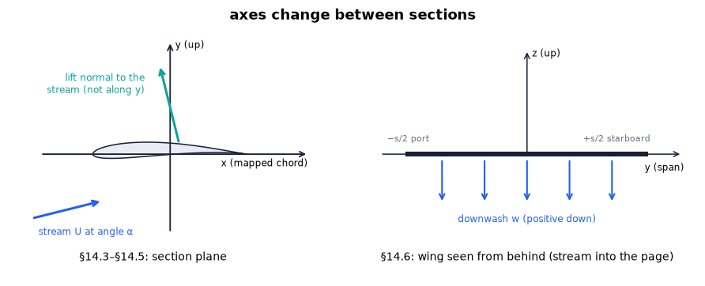

|  | symbol | meanings | ours | code |
| --- | --- | --- | --- | --- |
| 0 | Γ | clockwise circulation round the section (book:... | always labelled 'Γ (clockwise)'; lift ρUΓ > 0 ... | Gamma_cw= (keyword); Gamma_ccw = −Gamma_cw |
| 1 | dw/dz | u − iv (ch06 and here); ch13's Ekman velocity ... | complex velocity, conjugate of the vector | ZhukhovskyFlow.dwdz, .velocity |
| 2 | b | constant of the map z = ζ + b²/ζ (chord ≃ 4b);... | map constant only; span is s | b |
| 3 | a | radius of the ζ-plane circle; a length scale i... | circle radius, a = b(1 + e)/cos β | a |
| 4 | β | camber angle of the circle (§14.4–§14.5) = min... | camber angle / −(zero-lift angle), radians | beta |
| 5 | e | thickness parameter, a ≡ b(1 + e) (14.7) | thickness parameter; span efficiency is e_span | e, e_span |
| 6 | c | chord; wave speed in ch07 and ch13 | chord [m] | c |
| 7 | Λ | aspect ratio s²/A (14.1); the Rossby radius in... | aspect ratio | AR |
| 8 | γ | span angle, y = −(s/2) cos γ (§14.6); sheet st... | span angle | gamma |
| 9 | θ | polar angle of ζ in (14.4); angle from the str... | three different angles, each drawn where it is... | theta (local to each function), t (contour par... |
| 10 | x, y | §14.3–§14.5: section plane, x the mapped chord... | axes drawn at the top of each part | (Fx, Fy) and (L, D) both returned |
| 11 | w | downwash, positive downward (§14.6); the compl... | downwash (down +) | w; horseshoe_velocity returns uz (up +) |
| 12 | K | section lift-curve slope, per radian in (14.16... | per radian | K= (required) |
| 13 | A | planform area in (4.107)–(4.108) as used here ... | planform area unless stated | A |
| 14 | U, V, U_r | true stream / wind U, speed of the foil or boa... | three arrows | apparent_wind, oscillating_foil |

```python
fig = draw_axes_conventions()                               # two small sketches: the section plane (x along the chord, y up, stream at α) and the span (y along the span, w down)
plt.show()                                                  # display the sketch
display(ch14.conventions_table())                           # the letter table: symbol, its meanings, the one used here, its code name
```

**What does the code above do?**

1. `draw_axes_conventions()` draws the two coordinate systems of the chapter side by side.
2. `ch14.conventions_table()` is a pandas table (`pd.DataFrame`: rows and named columns) of the overloaded letters.

**What you see.** Left: a wing section with $x$ along its chord and the stream arriving at the angle $\alpha$. Right: a wing seen from behind (the stream goes into the page), with $y$ along the span, $z$ up and the downwash $w$ pointing down.

**How to read it.** The left axes belong to §14.3–§14.5 (one section, forces per metre of span), the right ones to §14.6 (a whole wing). Because the stream is tilted on the left, the lift — which is across the *stream* — is not the $y$-force.

**What would change if…** …you tilted the drawing instead of the stream? Then lift would be $F_y$ — but the map of §14.4 needs the chord on the $x$-axis, so the book tilts the stream.

```python
slips = pd.DataFrame(ch14.book_slips()).T[["where", "printed", "correct"]]   # 10 rows: where it is, what is printed, what is right
traps = pd.DataFrame(ch14.traps())[["id", "what", "where"]]                   # 18 rows: true as printed, easy to misread
pd.set_option("display.max_colwidth", 110)                                    # show long cells without cutting them
display(slips)                                                                # slips: false as printed
display(traps)                                                                # traps: true but easy to misread
```

|  | where | printed | correct |
| --- | --- | --- | --- |
| 1 | (14.19), first two members | denominator cos γ₁ − cos γ with the prefactor +1/(2πs) | cos γ − cos γ₁ (or a minus sign in front); the last member and (14.20)–(14.26) are right |
| 2 | unnumbered line before (14.14) | ε = tan(w/U) | ε = tan⁻¹(w/U) ≃ w/U |
| 3 | sentence after dw(y₁), §14.6 | 'at location y (< y₁) along the lifting line' | the velocity is induced at y₁; it is downward for a filament at y > y₁ on the starboard half (as the capti... |
| 4 | (14.8) | 'camber = ≅ ½βc' (two relation signs); coefficient 1.3 | camber ≃ ½βc; the first-order thickness coefficient is 3√3/4 = 1.299, and the rule is first order in e |
| 5 | historical notes, §14.3 | Lanchester's year of birth | 1868 |
| 6 | text after (14.26) | (4.107) and (4.108) 'in Section 4.3' | §4.11 (dynamic similarity) |
| 7 | (14.22) against (14.18)–(14.20) | upper limit N in (14.22), ∞ elsewhere | either, consistently |
| 8 | text after (14.11) | 'chord length c (≃ 4a)' and 'camber/chord ratio β/2' beside c ≃ 4b of (14.8) | both are first-order statements; exactly C_L = 8π(a/c) sin(α + β) |
| 9 | Exercises 14.14 and 14.18 | span written b | s (b is the map constant) |
| 10 | end of §14.6 | the 'Λ-pattern' of migrating birds, printed with the aspect-ratio symbol | a V formation |

|  | id | what | where |
| --- | --- | --- | --- |
| 0 | T1 | Γ is the clockwise circulation; positive lift at positive α needs Γ_cw > 0 | §14.3, §14.5 |
| 1 | T2 | dw/dz = u − iv here; ch13's Ekman velocity was u + iv | §14.5 |
| 2 | T3 | b, a, β, c, e, Λ, γ change meaning or are overloaded | all |
| 3 | T4 | three different θ: polar angle of ζ (14.4); from the stream-aligned diameter (14.10); stroke and course an... | §14.4, §14.5, §14.8, §14.9 |
| 4 | T5 | axes switch: x is the mapped chord in §14.4–§14.5 (lift is not F_y); y is the span in §14.6 and w is posit... | §14.4–§14.6 |
| 5 | T6 | 'the circulation does not change under the map' and 'equal velocities at infinity' are stated, not shown; ... | §14.5 |
| 6 | T7 | which circle parameters: a = b(1 + e) is defined for the symmetric case only, a = b/cos β for the arc only | §14.4 |
| 7 | T8 | (14.9) is 0/0 at the trailing edge with the Kutta circulation and infinite otherwise; the inverse map need... | §14.5 |
| 8 | T9 | 'induced drag is the largest part of the total drag' holds at high lift coefficient (exactly half at best ... | §14.6, §14.7 |
| 9 | T10 | (14.13) is a principal value; the downwash of a single horseshoe is infinite at its tips; its 'better than... | §14.6 |
| 10 | T11 | elliptic loading is not elliptic planform: twist can give it on any planform | §14.6 |
| 11 | T12 | K is per radian in (14.16)–(14.20) and quoted per degree in §14.7 | §14.6, §14.7 |
| 12 | T13 | A is the planform area in (4.107)–(4.108) as used here; a section uses the chord per unit span | §14.3, §14.6 |
| 13 | T14 | the Kutta condition is a model of a viscous outcome, not a theorem of ideal flow; it fails at stall and in... | §14.3 |
| 14 | T15 | Kelvin's theorem needs only the circuit itself to stay in inviscid constant-density fluid; the foil and it... | §14.3 |
| 15 | T16 | the separation estimate, the wake roll-up past the first turn, the generic curves and the Reynolds-number ... | §14.3, §14.6, §14.7 |
| 16 | T17 | typical values quoted in the prose and every exercise input are private | all |
| 17 | T18 | the fish and sail formulas are quasi-steady and drag-free in the book; 'ideally perfect' is an identity of... | §14.8, §14.9 |

**What does the code above do?**

1. `ch14.book_slips()` returns the ten suspected misprints (a dictionary keyed "1" … "10"); `.T` turns it into one row per slip.
2. `ch14.traps()` returns the eighteen traps T1–T18.
3. Slips are false as printed; traps are true but easy to misread. Each is taught where it first bites.

## 14.1 Introduction

**What is this section about?** What "aerodynamics" covers, the three assumptions the whole chapter leans on, and the one place where they fail.

📝 **Note.** **N01 [B]** Aerodynamics asks for the forces and moments a moving fluid exerts on a body. Three standing assumptions:

| # | Assumption | Taught in | Fails when |
| --- | --- | --- | --- |
| 1 | no buoyancy or stratification: the air's density is uniform, so the ideal (inviscid, irrotational) flow of Ch. 6 applies | Ch. 6 | the air is compressed — Mach number above about 0.3 |
| 2 | a uniform stream far ahead of the body | Ch. 6 | gusts, a neighbour's wake |
| 3 | viscosity matters only in thin boundary layers on the surface | Ch. 9 | **stall**: the boundary layer leaves the surface (N13, in C07) |

The air may be treated as incompressible while the Mach number $\mathrm{Ma}=U/c_{\text{sound}}$ (speed over the speed of sound, Ch. 1 and Ch. 4) stays below about 0.3, because density changes are about $\tfrac12\mathrm{Ma}^2$ (ours).

```python
rows = []                                                   # one row per flight condition
for name, U, T in (("our aircraft, slow", 30.0, 288.15), ("our aircraft, cruise", 55.0, 288.15), ("an airliner at cruise", 240.0, 220.0)):   # speed [m/s], air temperature [K]
    cc = ch14.compressibility_check(U=U, T=T)                 # Mach number, density change ½Ma², verdict Ma < 0.3
    rows.append({"case": name, "U [m/s]": U, "Ma": round(cc["Ma"], 3), "density change [%]": round(100*cc["density_change"], 1), "incompressible?": cc["incompressible_ok"]})   # collect
pd.DataFrame(rows)                                          # show the three rows as a table
```

|  | case | U [m/s] | Ma | density change [%] | incompressible? |
| --- | --- | --- | --- | --- | --- |
| 0 | our aircraft, slow | 30.0 | 0.088 | 0.4 | True |
| 1 | our aircraft, cruise | 55.0 | 0.162 | 1.3 | True |
| 2 | an airliner at cruise | 240.0 | 0.807 | 32.6 | False |

**What does this show?** Our light aircraft passes at both speeds (Ma = 0.088 and 0.162: the density changes by 0.4 % and 1.3 %). An airliner at cruise (Ma ≈ 0.81, a 33 % change) fails — that is Chapter 15. Everything below is for the first two rows.

## 14.2 Aircraft Terminology

**What is this section about?** The handful of words and numbers that describe a wing — span, chord, area, aspect ratio, angle of attack — and the two coefficients every later result is written in.

### 🧩 The wing in numbers: $\Lambda\equiv s^2/A=s/\bar c$ (14.1), $\bar c=A/s$ (14.2) `C01`

*The question:* How do you describe a wing with a few numbers — and how much lift must it deliver to stay up?

#### The problem in plain words

Stand under an airliner and under a glider. One wing is short and broad, the other long and thin. Before any physics we need words for that difference, and for the angle at which the wing meets the air. Then one balance — in steady level flight the lift equals the weight — tells us what the wing has to do, and everything else in the chapter is about *how* it does it and *what it costs*.

#### The idea

```
         top view of a wing (looking down)

tip  ___________________________________________  tip
    |                     |                     |
    |        c(y)  ←chord→|   root              |      A = area seen from above (planform area)
    |_____________________|_____________________|
    |<------------------ s (span) ------------->|

slender:  Λ = s²/A large  (glider ≈ 20)          stubby:  Λ small  (fighter ≈ 3)
```

Three lengths describe the outline: the **span** $s$ (tip to tip), the **chord** $c(y)$ (front to back at the spanwise station $y$) and the **planform area** $A$ (the area seen from above). One ratio, the **aspect ratio** $\Lambda$, says how slender it is.

> 🔁 **Tools from earlier chapters used in this block** (one line each; the full primers are in the chapters named)
- **trapezoid rule; `np.trapezoid`** — an integral estimated from samples by adding the areas of the trapezoids between neighbours (`np.trapezoid(y, x)`); here it adds up the chord along the span to get the planform area. *(Ch. 1, P37)*
- **`assert np.allclose` / `np.isclose`** — `assert np.allclose(a, b)` stops with an error if two results differ by more than a tiny tolerance; here it is the proof that each from-scratch cell matches the tested function. *(Ch. 1, P15)*
- **`slider_figure`, `animate` / `show_animation`, `show_viz`, `live`** — `slider_figure(fn, name, values)` draws a plotly figure with every slider position precomputed (works on the web page); `animate` + `show_animation` play a matplotlib animation inline; `show_viz` embeds an explainer; `live` makes kernel-only sliders. *(Ch. 1, P17, P16, P18)*
- **`np.interp`** — `np.interp(x_new, x, y)` reads a sampled curve between its samples along straight lines (x must increase); here it reads the upper and the lower surface of a section at the same chordwise stations. *(Ch. 7, P182, P337)*
- **f-strings** — `f"{x:.3f} m"` writes the value of `x` with three decimals inside a piece of text; every printed result below is made this way. *(Ch. 1, P04)*

📝 **Note.** **N02 [B]** **Words for a planform.** The *fuselage* is the body; the wing joins it at the **root** and ends at the **tips**; the **span** $s$ is the tip-to-tip distance; the **chord** $c(y)$ is the wing's length along the flight direction at station $y$; the **planform area** is $A=\int_{-s/2}^{s/2}c(y)\,dy$ (ours, implied by the book's definition). **Taper** is a chord that shrinks toward the tip (taper ratio = tip chord / root chord); **sweepback** is a wing whose tips lie behind its root.

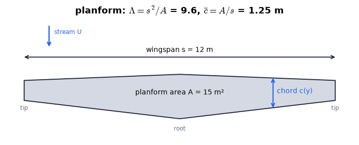

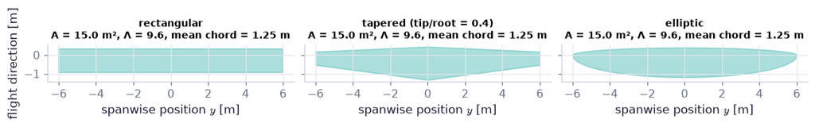

```python
fig = draw_planform_labelled()                              # a labelled planform: span s, chord c(y), root, tips, area A
plt.show()                                                  # display the sketch
shapes = {"rectangular": LL.planform(kind="rectangular", s=12.0, c_root=1.25),          # span 12 m, chord 1.25 m everywhere
          "tapered (tip/root = 0.4)": LL.planform(kind="tapered", s=12.0, c_root=1.786, taper=0.4),   # root chord 1.786 m, tip chord 0.4 of it
          "elliptic": LL.planform(kind="elliptic", s=12.0, c_root=1.592)}                # root chord 1.592 m, chord falls like an ellipse
fig, axes = plt.subplots(1, 3, figsize=(10.5, 2.6), sharey=True)           # three outlines side by side
for ax, (name, Pf) in zip(axes, shapes.items()):            # one panel per planform
    ax.fill_between(Pf["y"], 0.25*Pf["c"], -0.75*Pf["c"], color=COLORS["teal"], alpha=0.35)   # outline: leading edge ¼ chord ahead of a straight line, trailing edge ¾ behind
    ax.set_title(f"{name}\nA = {Pf['A']:.1f} m², Λ = {Pf['AR']:.1f}, mean chord = {Pf['c_mean']:.2f} m", fontsize=9)   # area, aspect ratio, mean chord
    ax.set_xlabel("spanwise position $y$ [m]")              # along the span
    ax.set_aspect("equal")                                  # true proportions
axes[0].set_ylabel("flight direction [m]")                  # up the page = forward
plt.show()                                                  # display
```

**What you see.** A labelled wing outline, then three wings with the **same span (12 m) and the same area (15 m²)**: a rectangle, a tapered wing and an ellipse.

**How to read it.** All three have the same aspect ratio 9.6 and the same mean chord 1.25 m: those two numbers cannot tell them apart. What differs is how the chord is distributed along the span — which C12 will show decides how the lift is distributed.

**What would change if…** …the taper went to 0? A pointed tip: the chord vanishes there, and C12 shows the loading it produces is too peaked in the middle.

#### 🧮 Derivation — Aspect ratio two ways, and what level flight asks of the wing `D01` ★ (Eq. 14.1: $\Lambda\equiv s^2/A=s/\bar c$)

**What we want to show.** Reduce a wing to one shape number, and find how much lift coefficient it must deliver to carry the aircraft — and the slowest speed at which it can.

**Assumptions.** Steady, level, unaccelerated flight (step 3); A is the planform area (step 4).

**The plan.**

1. Name the mean chord.
2. Rewrite Λ with it.
3. Balance lift and weight.
4. Solve for the coefficient, then for the speed.

**Tools we use** (each explained before this point): substitution · the lift coefficient $C_L\equiv\dfrac{L}{\tfrac12\rho U^2A}$ (4.108) (R01) · a square root

**We start from**

$$ \Lambda\equiv s^2/A\ \text{(14.1), the definition} $$

*In words:* Span squared over planform area

**Step 1 of 5 — Define the mean chord.**

$$ \bar c=A/s\ \text{(14.2)} $$

- *Why we can do this:* A definition: the planform area divided by the span is the chord of the rectangle with the same span and area. We need one chord to stand for a chord that varies.
- *In words:* The average chord is area over span.

**Step 2 of 5 — Substitute it into the aspect ratio.**

$$ \Lambda\equiv\dfrac{s^2}{A}=\dfrac{s^2}{\bar c\,s}=\dfrac{s}{\bar c}\ \text{(14.1)} $$

- *Why we can do this:* Replace A by $\bar c\,s$ from step 1 and cancel one factor s; this shows the two printed forms are the same number.
- *In words:* Aspect ratio is span divided by mean chord: how many chords fit along the wing.

**Step 3 of 5 — Balance the vertical forces.**

$$ L=W $$

- *Why we can do this:* In steady level flight the aircraft does not accelerate vertically, so by Newton's second law the lift equals the weight (and likewise thrust equals drag).
- *In words:* The wing must carry exactly the aircraft's weight.

**Step 4 of 5 — Insert the lift coefficient and solve.**

$$ C_L=\dfrac{W}{\tfrac12\rho U^2A} $$

- *Why we can do this:* By its definition $L=C_L\,\tfrac12\rho U^2A$ with A the planform area; set this equal to W and divide. We want the one number the wing has to produce.
- *In words:* The required lift coefficient is weight over dynamic pressure times wing area; it falls as one over speed squared.

**Step 5 of 5 — Set the coefficient to its largest value.**

$$ U_{\min}=\sqrt{\dfrac{2W}{\rho A\,C_{L,\max}}} $$

- *Why we can do this:* A wing cannot exceed some $C_{L,\max}$ (stall). Put $C_L=C_{L,\max}$ in step 4 and solve for U; U is positive, so we take the positive root.
- *In words:* Below this speed the wing cannot hold the aircraft up.

**Result**

$$ \Lambda\equiv s^2/A=s/\bar c\ \text{with}\ \bar c=A/s\ \text{; in level flight}\ C_L=\dfrac{W}{\tfrac12\rho U^2A}\ \text{and}\ U_{\min}=\sqrt{\dfrac{2W}{\rho A\,C_{L,\max}}} $$

*In words:* The shape in one number; the task in one number

**What it means.** Every later result is written in $C_L$ and Λ; slow flight is high-$C_L$ flight. **Fails when:** the flight is not level and steady (in a turn or a pull-up the lift exceeds the weight).

**Check it.** Units — Λ: m²/m² ✓; $C_L$: N/(Pa m²) ✓; $U_{\min}$: √(N/(kg m⁻³ m²)) = m/s ✓. Limits — a rectangle has Λ = s/c exactly; doubling the speed quarters the required $C_L$. Number — s = 10 m, A = 20 m²: Λ = 5; W = 10 kN at 40 m/s, ρ = 1.25: $C_L$ = 0.5.

📝 **Notes taught inside `D01`:** **N03 [B]** the mean chord $\bar c=A/s$ (14.2) (step 1) · **N05 [B]** steady level flight, $L=W$ and thrust = drag (steps 3–4) · the stall speed of **N73** (step 5; used in C15).

> ⚠️ **Common confusion (traps in `D01`):** A is the planform area, not the frontal area (trap T13); "level, steady" is what makes lift equal weight; $C_L\propto1/U^2$, not 1/U.

> 📎 **Primer — force per unit span, section coefficient and wing coefficient.** `P336` · A two-dimensional section has no area, so its forces are **per metre of span** [N/m] and are divided by $\tfrac12\rho U^2c$ (chord $c$). A whole wing's forces are in newtons and are divided by $\tfrac12\rho U^2A$ (planform area $A$). $\tfrac12\rho U^2$ is the **dynamic pressure**: the pressure rise where the stream is brought to rest.

```python
rho, U, c, A = 1.225, 30.0, 1.0, 15.0     # air density [kg/m³], speed [m/s], chord [m], planform area [m²]
q = 0.5*rho*U**2                          # dynamic pressure: 551 Pa
print(q, 587.0/(q*c), 9000.0/(q*A))       # a section's 587 N/m -> 1.06 ; a wing's 9000 N -> 1.09
```

```
551.25 1.0648526077097507 1.08843537414966
```

> 🔁 **Recap — Lift and drag coefficients `R01`** (Ch. 4 §4.11). $C_D\equiv\dfrac{D}{\tfrac12\rho U^2A}$ and $C_L\equiv\dfrac{L}{\tfrac12\rho U^2A}$ (4.107), (4.108): a force divided by dynamic pressure times an area. **New here:** $A$ is the *planform* area (Chapter 9's bluff bodies used the frontal area — trap T13), and a section uses the chord per unit span.

| Body | Area in the coefficient | Symbol |
| --- | --- | --- |
| a wing | planform area (seen from above) | $A$ |
| a bluff body (sphere, car, projectile) | frontal area (seen from ahead) | $A_f$ |
| a two-dimensional section | chord × 1 m of span | $c$ |

> ⚠️ **slip #6 — the book prints** that the two definitions $C_D\equiv\dfrac{D}{\tfrac12\rho U^2A}$, $C_L\equiv\dfrac{L}{\tfrac12\rho U^2A}$ (4.107), (4.108) are "in Section 4.3"**; the correct form is** §4.11.

```python
print(SIM.lift_coefficient(F=9000.0, rho=1.225, U=30.0, A=15.0))     # a wing: 9000 N over (551 Pa × 15 m²) = 1.088
print(AF.section_coefficient(F_per_span=587.0, rho=1.225, U=30.0, c=1.0))     # a section: 587 N/m over (551 Pa × 1 m) = 1.065
```

```
1.08843537414966
1.0648526077097507
```

> 🔁 **Recap — Friction drag and pressure drag `R02`** (Ch. 9 (form drag); Ch. 4 (surface forces)). Drag is the sum of the surface shear stress (friction drag) and of the surface pressure (pressure or form drag); lift is almost entirely a pressure force. C15 refines this into friction + form + induced.

#### ✏️ Tiny example: a wing by hand

$s$ = 10 m, $A$ = 20 m².

1. Mean chord $\bar c=A/s$ (14.2) = 20/10 = 2 m.
2. Aspect ratio $\Lambda\equiv s^2/A$ (14.1) = 100/20 = 5 — and also $s/\bar c$ = 10/2 = 5 ✓.
3. Level flight with $W$ = 10 000 N at $U$ = 40 m/s in air of ρ = 1.25 kg/m³: dynamic pressure ½ × 1.25 × 40² = 1000 Pa; $C_L=W/(\tfrac12\rho U^2A)$ = 10 000/(1000 × 20) = 0.5.
4. Halve the speed: the dynamic pressure falls to 250 Pa and the wing must deliver $C_L$ = 2.0 — four times as much.
5. If the wing can reach at most $C_{L,\max}$ = 1.4, the slowest level flight is $U_{\min}=\sqrt{2W/(\rho AC_{L,\max})}$ = √(20 000/35) = 23.9 m/s.

```python
AR = LL.aspect_ratio(s=ac["s"], A=ac["A"])                      # Eq. (14.1): Λ = s²/A [–]
cbar = LL.mean_chord(A=ac["A"], s=ac["s"])                      # Eq. (14.2): mean chord = A/s [m]
CL_slow = ch14.level_flight(W=ac["W"], rho=1.225, U=ac["U_slow"], A=ac["A"])["CL"]      # lift coefficient needed at 30 m/s: W/(½ρU²A)
CL_cruise = ch14.level_flight(W=ac["W"], rho=1.225, U=ac["U_cruise"], A=ac["A"])["CL"]  # the same at 55 m/s
U_clean = ch14.stall_speed(W=ac["W"], rho=1.225, A=ac["A"], CL_max=ac["CL_max"])             # slowest level speed, clean wing [m/s]
U_flap = ch14.stall_speed(W=ac["W"], rho=1.225, A=ac["A"], CL_max=ac["CL_max_flap"])         # slowest level speed with the flap down [m/s]
print(f"aspect ratio = {AR:.1f}, mean chord = {cbar:.2f} m")                  # 9.6 and 1.25 m
print(f"C_L needed: {CL_slow:.3f} at 30 m/s, {CL_cruise:.3f} at 55 m/s")      # 1.088 and 0.324
print(f"slowest level flight: {U_clean:.1f} m/s clean, {U_flap:.1f} m/s with flap")   # 26.5 and 22.1 m/s
```

```
aspect ratio = 9.6, mean chord = 1.25 m
C_L needed: 1.088 at 30 m/s, 0.324 at 55 m/s
slowest level flight: 26.5 m/s clean, 22.1 m/s with flap
```

**What does the code above do?**

1. `LL.aspect_ratio` and `LL.mean_chord` are $\Lambda\equiv s^2/A$ (14.1) and $\bar c=A/s$ (14.2): our aircraft has Λ = 9.6 and a mean chord of 1.25 m.
2. `ch14.level_flight` solves $L=W$ for the lift coefficient: 1.088 at 30 m/s but only 0.324 at 55 m/s — the same weight, 3.4 times the dynamic pressure.
3. `ch14.stall_speed` is step 5 of the derivation: 26.5 m/s with $C_{L,\max}$ = 1.4.
4. Flaps raise $C_{L,\max}$ to 2.0, so the aircraft can land 4.3 m/s slower (C15 returns to this).

```python
y = np.linspace(-6.0, 6.0, 201)                             # 201 stations along a 12 m span [m]
c = 1.786*(1 - 0.6*np.abs(y)/6.0)                           # tapered chord: 1.786 m at the root, 0.4 of it at the tips [m]
A_mine = 0.0                                                # running planform area [m²]
for i in range(len(y) - 1):                                 # one trapezoid per pair of neighbouring stations
    A_mine += 0.5*(c[i] + c[i+1])*(y[i+1] - y[i])           # mean chord of the strip times its width
AR_mine = 12.0**2/A_mine                                    # Eq. (14.1): s²/A
cbar_mine = A_mine/12.0                                     # Eq. (14.2): A/s
Pf = LL.planform(kind="tapered", s=12.0, c_root=1.786, taper=0.4)   # the tested function for the same wing
assert np.allclose([A_mine, AR_mine, cbar_mine], [Pf["A"], Pf["AR"], Pf["c_mean"]], rtol=1e-3)   # same numbers → the library does exactly this
print(f"A = {A_mine:.2f} m², aspect ratio = {AR_mine:.2f}, mean chord = {cbar_mine:.3f} m")       # 15.0 m², 9.6, 1.25 m
```

```
A = 15.00 m², aspect ratio = 9.60, mean chord = 1.250 m
```

**What does the code above do?**

1. The chord of a tapered wing is written as a formula and the area is summed strip by strip (the trapezoid rule, by hand).
2. Aspect ratio and mean chord follow from $\Lambda\equiv s^2/A$ (14.1) and $\bar c=A/s$ (14.2).
3. `assert np.allclose` confirms that `LL.planform` returns the same three numbers.

📝 **Note.** **N07 [B]** **Words for a section.** Cut the wing with a vertical plane along the flight direction: the cut is the **airfoil section**. It has a rounded **leading edge** and a sharp **trailing edge**. The **chord line** joins the two; the **camber line** runs midway between the upper and lower surfaces; the **camber** is the largest height of the camber line above the chord, $\max y_c$; the **thickness** is the largest distance between the surfaces, $t=\max(y_u-y_l)$; the **angle of attack** α is the angle between the chord line and the stream.

> 📎 **Primer — splitting a closed contour into upper and lower surfaces.** `P337` · A section outline is one closed list of points. To measure it, find the trailing edge (largest x) and the leading edge (smallest x; `np.argmin` returns its index), cut the list there, and interpolate both halves on the same x stations (`np.interp(x_new, x, y)` reads a curve between its samples and needs x increasing, so one half is reversed with `[::-1]` — primed in Ch. 7, P182).

```python
x = np.array([1, .5, 0, .5, 1.]); y = np.array([0, .1, 0, -.06, 0])   # a diamond, counterclockwise from the tail
i = np.argmin(x)                                                      # index of the leading edge: 2
yu = np.interp(0.5, x[:i+1][::-1], y[:i+1][::-1])                     # upper surface at x = 0.5 (first half, reversed so that x increases)
yl = np.interp(0.5, x[i:], y[i:])                                     # lower surface at x = 0.5 (second half)
print(yu - yl, 0.5*(yu + yl))                                         # thickness 0.16, camber 0.02
```

```
0.16 0.020000000000000004
```

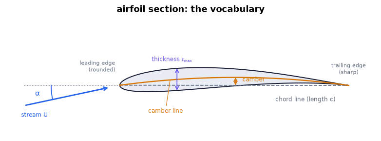

```
chord = 1.006 m, camber/chord = 0.035, thickness/chord = 0.096
```

```python
S0 = AF.zhukhovsky_airfoil(b=sec["b"], e=sec["e"], beta=sec["beta"])  # the outline of our section (how it is made: C04)
geom = AF.section_geometry(x=S0["x"], y=S0["y"])                 # chord, camber and thickness measured on the outline [m]
fig = draw_section_labelled(x=S0["x"], y=S0["y"], geom=geom)          # the section with chord line, camber line, camber, thickness, α
plt.show()                                                   # display
print(f"chord = {geom['chord']:.3f} m, camber/chord = {geom['camber']/geom['chord']:.3f}, thickness/chord = {geom['t_max']/geom['chord']:.3f}")   # 1.006 m, 0.035, 0.096
```

**What you see.** Our wing section with its chord line (straight, nose to tail), its camber line (midway between the surfaces), the camber and the maximum thickness marked.

**How to read it.** The printed numbers are measured on the outline: chord 1.006 m, camber 3.5 % of the chord, thickness 9.6 % of the chord. The camber is small — the camber line is only slightly bowed — yet C06 shows it is worth 4° of angle of attack.

**What would change if…** …you changed α? Nothing in this picture: α is not a property of the shape. Tilt the stream, not the drawing.

📝 **Note.** **N08 [B]** The force on the section is resolved **relative to the stream**: drag $D$ along it, lift $L$ across it. If the stream makes the angle α with the $x$-axis, $D=F_x\cos\alpha+F_y\sin\alpha$ and $L=-F_x\sin\alpha+F_y\cos\alpha$ (ours).

> ⚠️ **Common confusion (trap T5):** from §14.4 on the $x$-axis is the chord and the stream is tilted, so **lift is not $F_y$**.

```python
L_, D_ = AF.resolve_lift_drag(Fx=-51.1, Fy=584.4, alpha=sec["alpha"])    # force components along and across the chord [N/m] (computed in C07), stream at α = 5°
print(f"L = {L_:.1f} N/m, D = {D_:.2f} N/m")                 # 586.6 N/m and ≈ 0: the pressure force leans forward of the y-axis by exactly α
```

```
L = 586.6 N/m, D = 0.03 N/m
```

📝 **Note.** **N04 [C] · N06 [C] · N83 [C]** Three things named here and used later.

- **N04 [C] The three axes of an aircraft.** *Pitch* is nose up or down, *roll* is one wing down, *yaw* is nose left or right (sketch below). Roll returns with the ailerons below and with the rolling moment in a wake vortex (N64, in C12).
- **N06 [C] Control surfaces.** *Ailerons* (outer trailing edge, moved in opposite senses to roll), *elevator* (on the tail, to pitch), *rudder* (on the fin, to yaw), *flaps* (inner trailing edge, lowered together for more lift), *slots* (a gap near the nose that feeds fast air to the upper surface), *spoilers* (plates raised to destroy lift), *trim tabs* (small surfaces that hold a control in place). All of them work by changing the local camber; "more camber ⇒ more lift at the same α" is N31 in C06, flaps and landing speed N73 in C15.
- **N83 [C] A projectile with drag.** With a constant drag coefficient on a shallow trajectory the range is $x\simeq\dfrac{2m}{\rho AC_D}\ln\Big(1+\dfrac{\rho AC_DV_o^2\cos\theta_o\sin\theta_o}{mg}\Big)$ — here $A$ is the *frontal* area (trap T13); the next cell evaluates it once with our own numbers.

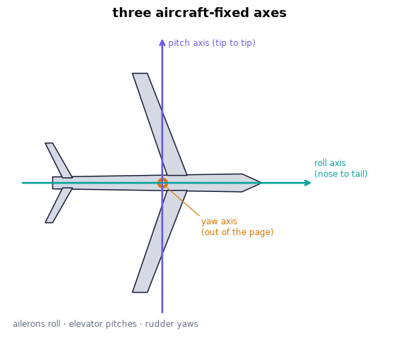

```
range with drag = 28.3 m, without drag = 31.4 m
```

```python
fig = draw_three_axes()                                      # pitch, roll and yaw axes on a plan-view silhouette
plt.show()                                                   # display
x_drag = ch14.projectile_range_drag(m=0.145, rho=1.225, A=0.0042, CD=0.4, V0=30.0, theta0=np.deg2rad(10.0))   # a 145 g ball, frontal area 42 cm², C_D = 0.4, 30 m/s at 10° [m]
x_free = 2*30.0**2*np.cos(np.deg2rad(10.0))*np.sin(np.deg2rad(10.0))/9.80665            # the same throw without drag: 2 V² cos θ sin θ / g [m]
print(f"range with drag = {x_drag:.1f} m, without drag = {x_free:.1f} m")               # drag shortens the throw
```

```python
def planform_taper(taper):                                   # outline of a wing of span 12 m and area 15 m² for one taper ratio
    c_root = 2*15.0/(12.0*(1 + taper))                       # root chord that keeps the area at 15 m²: A = s·c_root·(1 + taper)/2
    Pf = LL.planform(kind="tapered", s=12.0, c_root=c_root, taper=taper, n=101)  # stations y and chords c(y)
    yy = np.r_[Pf["y"], Pf["y"][::-1], Pf["y"][0]]           # go out along the leading edge and back along the trailing edge
    xx = np.r_[0.25*Pf["c"], -0.75*Pf["c"][::-1], 0.25*Pf["c"][0]]   # leading edge ¼ chord ahead, trailing edge ¾ chord behind
    return {"planform: s = 12 m, A = 15 m², mean chord 1.25 m, Λ = 9.6 at every taper": (yy, xx)}   # one closed outline
figF1a = slider_figure(planform_taper, "taper ratio (tip chord / root chord)", np.linspace(0.1, 1.0, 19), unit="",
                       xlabel="spanwise position y [m]", ylabel="flight direction [m]", yrange=[-2.6, 1.2],
                       title="Taper moves area inboard; span, area and aspect ratio stay the same")   # 19 slider positions
figF1a.show()                                                # display the slider figure

def planform_AR(AR):                                         # outline of a rectangular wing of area 15 m² for one aspect ratio
    s_ = np.sqrt(AR*15.0)                                    # Eq. (14.1) solved for the span: s = sqrt(Λ A) [m]
    c_ = 15.0/s_                                             # Eq. (14.2): the chord = A/s [m]
    return {"rectangle of area 15 m²": (np.array([-s_/2, s_/2, s_/2, -s_/2, -s_/2]), np.array([0.25*c_, 0.25*c_, -0.75*c_, -0.75*c_, 0.25*c_]))}   # four corners, closed
figF1b = slider_figure(planform_AR, "aspect ratio Λ = s²/A", np.arange(3.0, 20.1, 1.0), unit="",
                       xlabel="spanwise position y [m]", ylabel="flight direction [m]", xrange=[-9, 9], yrange=[-2.6, 1.2],
                       title="Same area, stretched: Λ = s²/A grows with the span squared")   # 18 slider positions
figF1b.show()                                                # display
print(pd.DataFrame({"Λ": [3, 6, 9.6, 20], "span s [m]": [np.sqrt(L_*15.0) for L_ in (3, 6, 9.6, 20)], "chord [m]": [15.0/np.sqrt(L_*15.0) for L_ in (3, 6, 9.6, 20)]}).round(2).to_string(index=False))   # the numbers behind four slider positions
```

[interactive chart not shown]

```
   Λ  span s [m]  chord [m]
 3.0        6.71       2.24
 6.0        9.49       1.58
 9.6       12.00       1.25
20.0       17.32       0.87
```

**What does the code above do?**

1. `planform_taper` builds the outline of a wing of fixed span and area for one taper ratio; `slider_figure` calls it once per slider position (the figure also works on the web page — nothing is computed when you drag).
2. `planform_AR` stretches a rectangle at fixed area: from $\Lambda\equiv s^2/A$ (14.1) the span is $\sqrt{\Lambda A}$.
3. The printed table lists span and chord for four aspect ratios.

**What you see.** Two slider figures. First: a wing whose tip chord shrinks while span and area are held. Second: a rectangle of fixed area stretched from stubby (Λ = 3) to very slender (Λ = 20).

**How to read it.** In the first, the outline changes but Λ = 9.6 does not: the aspect ratio does not see taper. In the second, going from Λ = 3 to Λ = 20 multiplies the span by √(20/3) ≈ 2.6 and divides the chord by the same factor.

**What would change if…** …you doubled the span at fixed area? Λ quadruples. C14 shows the price of lift falls with the square of the span.

**What would change if…** …you only knew the section's shape and the angle α — could you predict $C_L$? Not yet: ideal flow has one free number, the circulation. C02 is about who sets it.

## 14.3 Characteristics of Airfoil Sections

**What is this section about?** Why a section lifts at all. Ideal flow allows any circulation; the sharp trailing edge picks one (the Kutta condition); and the circulation it picks is paid for by a vortex left behind at the start. The section's pressure distribution — a §14.3 picture — is computed after the lift, in C07.

### 🧩 The Kutta condition: $\left.\dfrac{dw}{d\zeta}\right\rvert_{\zeta=b}=0$ `C02`

*The question:* Ideal flow round a wing has a solution for every circulation. Which one does a real wing choose?

#### The problem in plain words

Hold a flat board at a slight angle in a stream. Chapter 6 says the force on it is $L=\rho U\Gamma$ (6.62) — and that the equations are satisfied for *any* Γ, including zero. A theory that cannot say whether a wing lifts is not much use. The missing fact is about the sharp rear edge: with the wrong circulation the air would have to whip round that edge from one side to the other, at a speed that grows without limit as the edge gets sharper. Real air cannot do that. It leaves the edge smoothly — and exactly one circulation lets it.

#### The idea

```
rear end of a plate at incidence, three circulations (flow from the left, plate rising to the left)

Γ = 0                       Γ too small                  Γ = Γ_K  (Kutta)
───────●──╮                 ─────────●─╮                 ───────────●
  stagnation  ↺ flow turns     point closer,               flow leaves the
  point on top  the edge       still turning               edge smoothly
```

● is the rear **stagnation point** (where the fluid speed is zero). Adding clockwise circulation pushes it toward the edge; the **Kutta condition** says the flow settles where it sits exactly *on* the edge.

> 🔁 **Tools from earlier chapters used in this block** (one line each; the full primers are in the chapters named)
- **root finding by bisection; `brentq`** — bisection halves a bracket [a, b] in which a function changes sign until the root is pinned down (`brentq` is a faster version of the same idea); here the function is the surface speed at the trailing edge and the root is the Kutta circulation. *(Ch. 3, P108)*

> 🔁 **Recap — The Kutta–Zhukhovsky lift theorem `R04`** (Ch. 6 §6.5). $L=\rho U\Gamma$ (6.62): a two-dimensional body in a steady ideal stream feels a force per unit span of $\rho U\Gamma$ at right angles to the stream, whatever its shape. $\Gamma$ is the **circulation**, the loop integral of the velocity round the body, $\oint\mathbf u\cdot d\mathbf x$ (Ch. 3). **New here:** the theorem leaves Γ free; this chapter supplies it.

| Convention | Circulation of a lifting wing | Lift |
| --- | --- | --- |
| the book (this chapter) | $\Gamma>0$, clockwise | $L=+\rho U\Gamma$ |
| Ch. 3 and Ch. 5 of this project | $\Gamma_{ccw}<0$, counterclockwise-positive | $L=-\rho U\Gamma_{ccw}$ |

> ⚠️ **Common confusion (trap T1):** Γ is **clockwise-positive** in this chapter. A wing flying to the left with the air faster over its top has clockwise circulation, Γ > 0, and positive lift.

```python
print(ch06.lift_per_span(rho=1.225, U=30.0, Gamma_cw=8.214))      # the book's sign: clockwise 8.214 m²/s -> L = +301.9 N/m
print(ch06.lift_per_span(rho=1.225, U=30.0, Gamma_ccw=-8.214))    # the same flow, counted counterclockwise: Γ_ccw = −8.214 -> the same +301.9 N/m
```

```
301.8645
301.8645
```

#### The maths, step by step

1. **A flat plate is a mapped circle.** A flat plate of chord $4b$ is the image of the circle of radius $b$ under the map $z=\zeta+\dfrac{b^2}{\zeta}$ (14.3) (recap R06, in C04); the trailing edge is the image of the point $\zeta=b$. So we may look for the stagnation points on the circle, where Chapter 6 gave them. (Reminder from Ch. 6: the **complex potential** $w=\phi+i\psi$ packs the velocity potential and the stream function into one function; streamlines are the lines of constant $\psi$.)
2. **Stagnation points on the circle.** They sit where the surface speed $u_\theta=-2U\sin\theta-\dfrac{\Gamma}{2\pi a}$ (6.37) vanishes: $\sin\theta=-\dfrac{\Gamma}{4\pi aU}$ (6.38), with θ measured from the stream direction.
3. **Where is the edge?** With the stream tilted up by α, the point $\zeta=b$ is at $\theta=-\alpha$.
4. **The condition.** The rear stagnation point reaches the edge when the right-hand side of step 2 equals $\sin(-\alpha)$. We find that Γ numerically first; C06 turns it into a formula.
5. **In one line.** Stated on the complex velocity, the Kutta condition is $\left.\dfrac{dw}{d\zeta}\right\rvert_{\zeta=b}=0$: the circle's flow stagnates at the point that becomes the trailing edge.

📝 **Note.** **N10 [B]** Building lift means building circulation. In a real flow the circulation is the net vorticity held in the two boundary layers: $\Gamma=\oint u_s\,ds=\int_0^c(U_{\text{upper}}-U_{\text{lower}})\,dx$ (ours) — the air is faster over the top. (Worked with numbers in C07 below.)

#### ✏️ Tiny example: three circulations on a unit circle

$U$ = 1 m/s, $a=b$ = 1 m, α = 30°, so the edge is at θ = −30°. From $\sin\theta=-\dfrac{\Gamma}{4\pi aU}$ (6.38):

1. Γ = 0: sin θ = 0, the rear stagnation point is at θ = 0° — 30° round from the edge, on the upper side.
2. Γ = π m²/s: sin θ = −π/(4π) = −0.25, θ = −14.5° — half-way there.
3. Γ = 2π m²/s: sin θ = −0.5, θ = −30° — on the edge.
4. Γ = 3π m²/s: sin θ = −0.75, θ = −48.6° — past the edge, on the lower side.

Only the third leaves the edge alone.

```python
U, b, alpha = sec["U"], sec["b"], sec["alpha"]              # speed [m/s], map constant [m] (plate chord 4b = 1 m), angle of attack [rad] (5°)
GK_plate = AF.kutta_circulation_root(U=U, b=b, e=0.0, beta=0.0, alpha=alpha)  # the clockwise Γ that puts the stagnation point on the edge, found by a root-finder [m²/s]
print(f"Kutta circulation of the plate (clockwise): {GK_plate:.3f} m²/s")   # 8.214
for f in (0.0, 0.5, 1.0, 1.2):                              # four trial circulations as fractions of the Kutta value
    rsp = AF.rear_stagnation_point(U=U, a=b, alpha=alpha, beta=0.0, Gamma_cw=f*GK_plate)   # where the rear stagnation point sits on the circle
    Ff = AF.zhukhovsky_flow(U=U, b=b, e=0.0, beta=0.0, alpha=alpha, Gamma_cw=f*GK_plate)   # the plate's flow with this circulation
    q4, q6 = Ff.speed_near_edge(d=1e-4)/U, Ff.speed_near_edge(d=1e-6)/U                    # fluid speed 0.1 mm and 0.001 mm behind the edge, in units of U
    print(f"Γ/Γ_K = {f:3.1f}: stagnation point {np.degrees(rsp['offset']):+5.2f}° from the edge ({rsp['offset']:+.4f} rad); speed at 0.1 mm = {q4:5.2f} U, at 0.001 mm = {q6:6.2f} U")   # angle in both units; two distances
```

```
Kutta circulation of the plate (clockwise): 8.214 m²/s
Γ/Γ_K = 0.0: stagnation point +5.00° from the edge (+0.0873 rad); speed at 0.1 mm =  4.47 U, at 0.001 mm =  43.59 U
Γ/Γ_K = 0.5: stagnation point +2.50° from the edge (+0.0437 rad); speed at 0.1 mm =  2.40 U, at 0.001 mm =  21.81 U
Γ/Γ_K = 1.0: stagnation point +0.00° from the edge (+0.0000 rad); speed at 0.1 mm =  1.00 U, at 0.001 mm =   1.00 U
Γ/Γ_K = 1.2: stagnation point -1.00° from the edge (-0.0175 rad); speed at 0.1 mm =  1.32 U, at 0.001 mm =   8.77 U
```

**What does the code above do?**

1. `AF.kutta_circulation_root` knows no formula: it searches for the Γ at which the circle's surface speed at $\zeta=b$ is zero. For our plate (chord 1 m, 30 m/s, α = 5°) it returns a clockwise 8.214 m²/s.
2. `AF.rear_stagnation_point` reports how far round the circle the stagnation point is from the edge: 5.0°, 2.5°, 0.0° and −1.0° for Γ/Γ_K = 0, 0.5, 1 and 1.2 — it moves linearly at these small angles.
3. `speed_near_edge(d)` is the fluid speed at the distance d behind the edge. Go a hundred times closer (0.1 mm → 0.001 mm) and the speed of every row except Γ/Γ_K = 1 grows about tenfold: it rises like $d^{-1/2}$ without limit. Only the Kutta row stays at about $U$ however close you look.
4. Past the Kutta value the point is on the *lower* side and the corner flow returns, turning the other way.

```python
def edge_slip(G):                                            # tangential speed of the circle's flow at the point ζ = b, for a clockwise circulation G
    w_, dw_ = CONF.circle_flow_zeta(U=U, a=b, Gamma_cw=G, alpha=alpha)   # complex potential and complex velocity of the circle flow (Ch. 6)
    return (dw_(b + 0j)*1j).real                             # at ζ = b the tangent points along +i, so u_θ = Re[(u − iv)·i]
lo, hi = 0.0, 4*np.pi*U*b                                    # bracket: no circulation … the largest that keeps stagnation points on the circle [m²/s]
for _ in range(40):                                          # forty halvings of the bracket (bisection)
    mid = 0.5*(lo + hi)                                      # middle of the bracket
    if edge_slip(lo)*edge_slip(mid) <= 0:                    # sign change in the lower half?
        hi = mid                                             # yes: the root is there
    else:                                                    # no:
        lo = mid                                             # the root is in the upper half
G_mine = 0.5*(lo + hi)                                       # the root: the Kutta circulation [m²/s]
assert np.isclose(G_mine, AF.kutta_circulation_root(U=U, b=b, e=0.0, beta=0.0, alpha=alpha), rtol=1e-9)   # same number → the library does exactly this
print(f"bisection: Γ_K = {G_mine:.4f} m²/s (clockwise)")     # 8.2142
```

```
bisection: Γ_K = 8.2142 m²/s (clockwise)
```

**What does the code above do?**

1. `edge_slip(G)` evaluates the circle flow of Chapter 6 at the one point that becomes the trailing edge and returns the speed along the circle there.
2. Forty halvings of the bracket [0, 4πUb] find the circulation at which that speed is zero.
3. The assert shows the tested function returns the same 8.2142 m²/s.

```python
al15 = np.deg2rad(15.0)                                      # a larger angle of attack (15° = 0.262 rad) so that the motion is easy to see
GK15 = AF.kutta_circulation_root(U=U, b=b, e=0.0, beta=0.0, alpha=al15)   # the Kutta circulation of the plate at 15° [m²/s], clockwise
nx, ny = (120, 80) if not FAST else (80, 54)                 # grid for the stream function (smaller when FAST)
X, Y = np.meshgrid(np.linspace(-0.9, 0.9, nx), np.linspace(-0.6, 0.6, ny))   # points of the x–y plane [m]
Xz, Yz = np.meshgrid(np.linspace(0.41, 0.53, nx), np.linspace(-0.04, 0.04, ny))   # a second, fine grid on the last 18 % of the plate (the zoom panel) [m]
levels = np.linspace(-0.55*U, 0.55*U, 23)                    # fixed stream-function levels [m²/s]; ψ = 0 is the plate itself
levels_z = np.linspace(-0.045*U, 0.045*U, 19)                # finer levels for the zoom [m²/s]
fractions = np.linspace(0.0, 1.2, 13) if not FAST else np.linspace(0.0, 1.2, 7)   # Γ/Γ_K of each frame: 0, 0.1, … 1.2
fig, (ax, axz) = plt.subplots(1, 2, figsize=(9.2, 3.4))      # left: the whole plate; right: a zoom on its trailing edge
ax.set(xlim=(-0.9, 0.9), ylim=(-0.6, 0.6), xlabel="x [m]", ylabel="y [m]", title="Γ/Γ_K = 0.00 (Γ clockwise)")   # the axes of every frame, so the layout can be fixed now
ax.set_aspect("equal")                                       # true proportions
axz.set(xlim=(0.41, 0.53), ylim=(-0.04, 0.04), xlabel="x [m]", ylabel="y [m]", title="zoom: dot 17.0 mm from the edge")   # the zoom window
axz.set_aspect("equal")                                      # true proportions here too
fig.canvas.draw(); fig.set_layout_engine("none")             # lay the figure out once, then freeze it: frames render much faster
def update(i):                                               # draw frame i
    f = fractions[i]                                         # Γ/Γ_K of this frame
    Fp = AF.flat_plate_flow(U=U, b=b, alpha=al15, Gamma_cw=f*GK15)     # the plate's flow with this circulation
    st = AF.stagnation_points(U=U, b=b, e=0.0, beta=0.0, alpha=al15, Gamma_cw=f*GK15)   # where the two stagnation points are
    for a_, Xa, Ya, lev, lim in ((ax, X, Y, levels, (-0.9, 0.9, -0.6, 0.6)), (axz, Xz, Yz, levels_z, (0.41, 0.53, -0.04, 0.04))):   # the same drawing in both panels
        a_.clear()                                           # wipe the previous frame
        a_.contour(Xa, Ya, Fp.stream(x=Xa, y=Ya), levels=lev, colors=COLORS["blue"], linewidths=0.8, linestyles="solid")   # streamlines = lines of constant ψ (all drawn solid, whatever the sign of ψ)
        a_.plot([-2*b, 2*b], [0, 0], color="k", lw=3)        # the plate: from x = −2b to x = +2b
        a_.plot(st["z_rear"].real, st["z_rear"].imag, "o", color=COLORS["orange"], ms=9, zorder=5)   # rear stagnation point (amber dot)
        a_.set(xlim=lim[:2], ylim=lim[2:], xlabel="x [m]", ylabel="y [m]")   # fixed axes
        a_.set_aspect("equal")                               # true proportions
        a_.grid(False)                                       # no background grid under the streamlines
    ax.set_title(f"Γ/Γ_K = {f:4.2f} (Γ clockwise)")          # the circulation of this frame
    axz.set_title(f"zoom: dot {1e3*(2*b - st['z_rear'].real):.1f} mm from the edge")   # how far the dot still is from x = 2b
with plt.rc_context({"savefig.dpi": 100}):                   # the frame player stores one picture per frame at this resolution (100 dots per inch keeps the 13 pictures small)
    show_animation(animate(update, frames=len(fractions), fig=fig, interval=400), player="frames")   # a frame player: step through, stop at 0, 0.5, 1.0
```

[figure not shown]

Once Loop Reflect

**What does the code above do?**

1. The plate is set at 15° so that the stagnation point starts well away from the edge.
2. `update(i)` builds the flow for one value of Γ/Γ_K (0, 0.1, … 1.2) and draws it twice: the whole plate on the left, and the last part of the plate, magnified fifteen times, on the right. Each panel shows the streamlines (contours of the stream function `Fp.stream`), the plate and the rear stagnation point.
3. All contour lines are drawn solid (`linestyles="solid"`); by default matplotlib would dash the lines on which the stream function is negative, which means nothing here.
4. `show_animation(..., player="frames")` gives ◀ ▮▮ ▶ buttons, so you can stop at Γ/Γ_K = 0, 0.5 and 1.

**What you see.** Streamlines round a flat plate at 15° while the clockwise circulation grows from zero through the Kutta value to 1.2 times it. The amber dot is the rear stagnation point. Left: the whole plate. Right: its last few centimetres, magnified — on the whole plate the dot moves by less than its own width (17 mm on a chord of 1 m).

**How to read it.** Use the right panel for the dot. At Γ = 0 it sits on the upper surface 17 mm ahead of the edge and the streamlines wrap round the trailing edge — the flow turns a knife-sharp corner. As Γ grows the dot slides back (the title counts the millimetres). At Γ/Γ_K = 1 it is on the edge and the streamline from it leaves smoothly, straight off the plate. Watch also the streamlines far upstream: they are deflected upward more and more — that is the lift appearing.

**What would change if…** …Γ goes past the Kutta value (the last two frames)? The dot passes the edge onto the lower side (the plate has no thickness, so it is drawn on the same line, moving forward again) and the corner flow returns, the other way round.

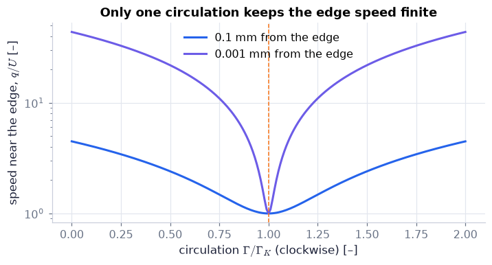

```python
fr = np.linspace(0.0, 2.0, 201)                              # trial circulations as fractions of the Kutta value
fig, ax = plt.subplots(figsize=(6.4, 3.4))                   # one panel
for d_, col in ((1e-4, COLORS["blue"]), (1e-6, COLORS["accent"])):   # two distances from the edge: 0.1 mm and 0.001 mm
    q_edge = [AF.zhukhovsky_flow(U=U, b=b, e=0.0, beta=0.0, alpha=alpha, Gamma_cw=f*GK_plate).speed_near_edge(d=d_)/U for f in fr]   # speed there, in units of U
    ax.semilogy(fr, q_edge, color=col, label=f"{d_*1e3:g} mm from the edge")   # logarithmic vertical axis: each step up is a factor of ten
ax.axvline(1.0, color=COLORS["orange"], ls="--", lw=1)       # the Kutta value
ax.set(xlabel=r"circulation $\Gamma/\Gamma_K$ (clockwise) [–]", ylabel="speed near the edge, $q/U$ [–]", title="Only one circulation keeps the edge speed finite")   # labels
ax.legend(); plt.show()                                      # legend and display
```

**What you see.** The fluid speed very close to the trailing edge against the circulation, at two distances from the edge, on a logarithmic axis.

**How to read it.** On a logarithmic axis each step up is a factor of ten. Each curve is a V with its notch at Γ/Γ_K = 1. Moving a hundred times closer to the edge lifts both arms of the V about tenfold (the speed grows like the inverse square root of the distance) — but the notch stays near $q=U$. Exactly one circulation gives a finite speed at the edge.

**What would change if…** …you measured closer still? The arms keep rising without limit; the notch does not move.

📝 **Note.** **N11 [C]** Three ways to make and control lift: a sharp trailing edge (which lets the other two work), the angle of attack, and the camber. Angle and camber become the sum α + β in $C_L\simeq2\pi(\alpha+\beta)$ (14.12), C06.

> ⚠️ **Common confusion:** (trap T14) The Kutta condition is **not a theorem of ideal flow**. It is a rule that stands in for what the boundary layers do, and it fails at stall and for motions faster than the time the air takes to cross the chord.

**What would change if…** …the foil starts from rest? Then Γ = 0 at first — where does the circulation come from? C03.

### 🧩 The starting vortex: $\Gamma_{ABCD}=0=\Gamma_{\text{foil}}+\Gamma_{\text{starting}}$ `C03`

*The question:* Kelvin says circulation cannot be created in an inviscid fluid. So where does the wing's come from?

#### The problem in plain words

Stir a spoon sideways through coffee and stop: a little whirl is left spinning where you began. A wing does the same. In the first moments of its motion it throws off a vortex from its trailing edge, and the air round the wing is left circulating the other way. Nothing was created — the two cancel — but the wing flies away from one half of the pair and keeps the other.

#### The idea

```
A ─────────────────────────B─────────────────────────┐ (far away)
│                          ┊                         │
│      ↻ foil              ┊        ↺ starting       │      total circulation round the big box  = 0
│   (moving left)          ┊          vortex         │      = (+Γ round the foil) + (−Γ round the starting vortex)
│                          ┊                         │
└──────────────────────────D───────────────────────── C
                         cut BD
```

A big closed curve that surrounds everything had zero circulation before the start, so it has zero circulation for ever. Cut it in two between the wing and what it left behind: the two halves must be equal and opposite.

> 🔁 **Recap — Kelvin's circulation theorem** (Ch. 5 §5.2). $\dfrac{D\Gamma}{Dt}=0$ (5.8): the circulation round a closed curve that moves with the fluid (a *material circuit*) does not change, provided the curve itself stays in inviscid fluid of uniform density.

> 🔁 **Recap — circulation adds over sub-circuits** (Ch. 3; Stokes' theorem, Ch. 2). Cut a circuit in two with a line: the two circulations add up to the original, because the cut is walked once each way and its two contributions cancel, $\Gamma_{\text{whole}}=\Gamma_{\text{left}}+\Gamma_{\text{right}}$.

📝 **Note.** **N14 [B]** An impulsively started foil at three times: $\Gamma=0\ \to\ 0<\Gamma<\Gamma_{\text{Kutta}}\ \to\ \Gamma=\Gamma_{\text{Kutta}}$ for $t>c/U$ — the steady pattern is approached once the foil has moved a distance of the order of its chord. That is an order of magnitude, not a stopwatch reading: in the lumped-vortex model below the circulation is at 65 % of its steady value after one chord of travel and at 90 % only after about six.

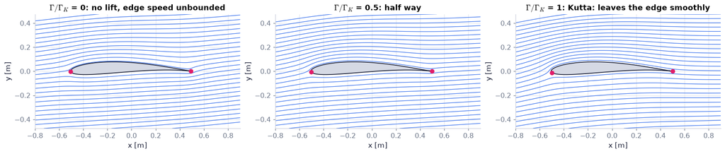

```python
fig = fig_three_stages(**SEC)   # streamlines of our section at Γ/Γ_K = 0, ½, 1 with both stagnation points
plt.show()                                                   # display
```

**What you see.** Three streamline pictures of our section at 5°: no circulation, half the Kutta value, the Kutta value. The dots are the front and rear stagnation points.

**How to read it.** Left: the rear dot is on the upper surface and the flow turns the sharp tail. Middle: it has moved half-way. Right: it is at the tail and the flow leaves smoothly. The front dot moves too — under the nose — as the circulation grows.

**What would change if…** …the section were symmetric and at α = 0? All three panels would be the same: no circulation is needed.

📝 **Note.** **N15 [B]** **The mechanism.** At the very start the flow does turn the sharp corner. But the fluid next to the surface is slow (the boundary layer) and cannot follow so tight a turn against rising pressure: it separates at the edge, rolls up, and the shed layer pushes the stagnation point back to the edge. A circulation larger than the Kutta value is allowed by ideal flow but is not observed (trap T14).

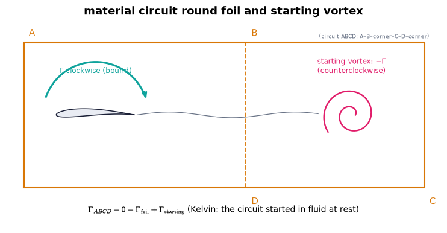

```python
fig = draw_kelvin_circuit()                                  # the material circuit ABCD round the foil and its starting vortex, cut by BD
plt.show()                                                   # display the sketch used by the derivation below
```

#### 🧮 Derivation — The starting vortex carries the opposite circulation `D02` ★ (Eq. 5.8: $\dfrac{D\Gamma}{Dt}=0$)

**What we want to show.** Show that a foil which starts from rest and ends with circulation Γ must have left a vortex of circulation −Γ behind.

**Assumptions.** The circuit itself stays in inviscid, constant-density fluid (step 2); it is large enough that neither the foil's boundary layer nor the wake crosses it (step 1).

**The plan.**

1. Draw one big material circuit round everything.
2. Apply Kelvin to it.
3. Cut it in two.
4. Read off the two parts.

**Tools we use** (each explained before this point): Kelvin's theorem (recap in C03) · circulation adds over sub-circuits (recap in C03)

**We start from**

$$ \text{Kelvin's theorem}\ \dfrac{D\Gamma}{Dt}=0\ \text{(5.8)} $$

*In words:* The circulation round a circuit that moves with the fluid does not change

**Step 1 of 5 — Draw a large material circuit at rest.**

$$ \Gamma_{ABCD}(0)=\displaystyle\oint_{ABCD}\mathbf u\cdot d\mathbf x=0 $$

- *Why we can do this:* Before the start the fluid is at rest everywhere, so the velocity along any closed curve is zero. We choose ABCD so large that it encloses the foil and all it will shed.
- *In words:* At the start nothing circulates.

**Step 2 of 5 — Apply Kelvin's theorem to it.**

$$ \Gamma_{ABCD}(t)=\Gamma_{ABCD}(0)=0 $$

- *Why we can do this:* The circuit moves with the fluid and stays in fluid where viscosity does not act; what happens *inside* it (boundary layers, the wake) does not matter to the theorem.
- *In words:* The big circuit's circulation stays zero for all time.

**Step 3 of 5 — Cut the circuit along the line BD.**

$$ \Gamma_{ABCD}=\Gamma_{ABD}+\Gamma_{BCD} $$

- *Why we can do this:* The cut BD is walked once in each direction by the two smaller circuits, so its contributions cancel and the outer parts add up to the original (Stokes' additivity).
- *In words:* The total is the sum of the two halves.

**Step 4 of 5 — Name the two halves.**

$$ \Gamma_{ABD}=\Gamma_{\text{foil}},\qquad\Gamma_{BCD}=\Gamma_{\text{starting}} $$

- *Why we can do this:* Once the foil has moved on, ABD encloses the foil alone and BCD the vorticity it shed at the start.
- *In words:* One half surrounds the wing, the other the vortex left behind.

**Step 5 of 5 — Combine steps 2–4.**

$$ \Gamma_{ABCD}=0=\Gamma_{\text{foil}}+\Gamma_{\text{starting}}\ \Rightarrow\ \Gamma_{\text{starting}}=-\Gamma_{\text{foil}} $$

- *Why we can do this:* Substitute step 4 into step 3 and use step 2.
- *In words:* The starting vortex has exactly the foil's circulation, with the opposite sense.

**Result**

$$ \Gamma_{ABCD}=0=\Gamma_{\text{foil}}+\Gamma_{\text{starting}} $$

*In words:* The wing does not create circulation; it separates it into two equal and opposite parts and flies away from one of them

**What it means.** Every change of lift — speed, incidence, a flap — sheds a vortex; the bound vortex, the two trailing vortices of C08 and the starting vortex form one closed loop. **Fails when:** the circuit is crossed by the wake or the boundary layer (then viscosity acts *on* the circuit), or the density is not uniform.

**Check it.** Units — all terms m²/s ✓. Number — a plate of chord 1 m at 30° reaching 10 m/s: bound +15.7 m²/s (clockwise), starting vortex −15.7 m²/s. Code — the lumped-vortex march keeps the sum at zero to round-off at every step.

> ⚠️ **Common confusion (traps in `D02`):** It is the circuit, not its interior, that must be free of viscous action (trap T15); a material circuit drifts with the fluid, so it must start large; the book's Γ is clockwise — the starting vortex is counterclockwise (trap T1).

> 📎 **Primer — discrete-vortex time stepping.** `P339` · A cheap model of a wing that sheds vorticity: one "bound" **point vortex** (a swirl whose speed is Γ/2πr at distance r, Ch. 5) stands for the wing; at every time step one new vortex is released just behind the trailing edge; its strength is whatever keeps the total circulation zero while the air does not flow through the plate at one control point. The total is the invariant to watch.

```python
G_bound, G_wake = 0.0, []                 # nothing circulates at the start
G_bound = 5.0; G_wake.append(-5.0)        # step 1: the wing gains 5, sheds -5
G_bound = 6.5; G_wake.append(-1.5)        # step 2: gains 1.5 more, sheds -1.5
print(G_bound + sum(G_wake))              # 0.0 at every step
```

```
0.0
```

#### ✏️ Tiny example: how strong is the starting vortex?

A flat plate of chord $c$ = 1 m at α = 30° reaches $U$ = 10 m/s.

1. Steady circulation (clockwise): $\pi Uc\sin\alpha$ = π × 10 × 1 × 0.5 = 15.7 m²/s (the plate's value of $\Gamma=4\pi Ua\sin(\alpha+\beta)$ (14.11), with $a=c/4$ and β = 0 — derived in C06).
2. Starting vortex: −15.7 m²/s, counterclockwise.
3. Lift: $L=\rho U\Gamma$ (6.62) = 1.2 × 10 × 15.7 = 188 N per metre of span.
4. The speed is then doubled to 20 m/s: the wing needs 31.4 m²/s, so it sheds another −15.7.
5. The wing stops: the bound 31.4 m²/s is shed as a +31.4 "stopping vortex". Total at every stage: 0.

```python
run = ch14.impulsive_start_lumped_vortex(U=sec["U"], c=1.0, alpha=sec["alpha"], t_end=20/sec["U"], dt=0.05/sec["U"], rho=1.0)   # plate of chord 1 m started at 30 m/s, α = 5°; 400 steps of 0.05 chords, 20 chords travelled
print(f"steady circulation πUc sin α = {run['Gamma_steady'][-1]:.3f} m²/s (clockwise)")      # 8.214, the Kutta value of C02
print("bound/steady after 1, 3, 5, 10 chords:", np.round(run["ratio"][[19, 59, 99, 199]], 3))   # 0.646, 0.816, 0.879, 0.939
print(f"largest |bound + shed| over the run = {np.abs(run['total']).max():.1e} m²/s")       # zero to round-off: Kelvin's theorem
```

```
steady circulation πUc sin α = 8.214 m²/s (clockwise)
bound/steady after 1, 3, 5, 10 chords: [0.646 0.816 0.879 0.939]
largest |bound + shed| over the run = 1.8e-15 m²/s
```

**What does the code above do?**

1. `ch14.impulsive_start_lumped_vortex` is the model of the primer: a bound vortex at the quarter chord, a control point at three-quarter chord, one new wake vortex per step, total circulation kept at zero.
2. The steady value it approaches is the Kutta circulation of C02, 8.214 m²/s clockwise.
3. The bound circulation is 65 % of that after one chord of travel, 82 % after three, 88 % after five and 94 % after ten: about half the lift arrives almost at once, the rest slowly — the starting vortex is still close and its velocity field holds the circulation down.
4. **Not in the book — ours:** this is a lumped-vortex sketch, not a simulation of the boundary layer.

```python
U_, c_, al_ = sec["U"], 1.0, sec["alpha"]                    # speed [m/s], chord [m], angle of attack [rad]
dt = 0.05*c_/U_                                              # time step: the plate travels 0.05 chords per step [s]
xP = 0.75*c_                                                 # control point at three-quarter chord (the bound vortex is at c/4)
wx, wy, wG = [], [], []                                      # wake vortices: positions [m] and clockwise strengths [m²/s]
G_mine = []                                                  # history of the bound circulation
for k in range(400):                                         # 400 steps = 20 chords
    wx = [x + U_*np.cos(al_)*dt for x in wx]                 # (i) every wake vortex drifts with the stream, x-part
    wy = [y + U_*np.sin(al_)*dt for y in wy]                 #     … and y-part
    xn, yn = c_ + 0.25*U_*dt*np.cos(al_), 0.25*U_*dt*np.sin(al_)   # (ii) the new vortex is placed a quarter-step behind the trailing edge
    k_new = -(xP - xn)/(2*np.pi*((xP - xn)**2 + yn**2))      # y-velocity at the control point per unit clockwise strength of the new vortex
    W = sum(G*(-(xP - x))/(2*np.pi*((xP - x)**2 + y**2)) for G, x, y in zip(wG, wx, wy))   # y-velocity there from the older wake vortices
    S = sum(wG)                                              # circulation already in the wake
    G_new = (-U_*np.sin(al_) - S/(np.pi*c_) - W)/(1/(np.pi*c_) + k_new)   # (iii) no flow through the plate at P, with Γ_bound = −Γ_new − S
    G_b = -G_new - S                                         # total circulation zero: the bound vortex balances the whole wake
    wx.append(xn); wy.append(yn); wG.append(G_new)           # the new vortex joins the wake
    G_mine.append(G_b)                                       # record
assert np.allclose(G_mine, run["Gamma_bound_cw"])            # same numbers → the library does exactly this
print(f"bound circulation after 1 and 10 chords: {G_mine[19]:.3f}, {G_mine[199]:.3f} m²/s")   # 5.309 and 7.711
```

```
bound circulation after 1 and 10 chords: 5.309, 7.711 m²/s
```

**What does the code above do?**

1. Each step moves the wake with the stream, places one new vortex just behind the edge, and solves two equations for two unknowns: *no flow through the plate at the control point* and *total circulation zero*.
2. A clockwise vortex of strength Γ at distance r induces the speed Γ/(2πr); its vertical part at the control point is the factor `k_new` (and the sum `W` for the older vortices). The bound vortex, half a chord ahead of the control point, contributes −Γ_b/(πc).
3. The assert confirms the tested function is this loop.

```python
hist = ch14.impulsive_start_lumped_vortex(U=sec["U"], c=1.0, alpha=np.deg2rad(10.0), t_end=6/sec["U"], dt=0.1/sec["U"], history=True)   # a shorter run at 10° (0.175 rad) with the wake positions kept at every step
n_frames = 40 if not FAST else 20                            # number of frames (fewer when FAST)
idx = np.linspace(0, len(hist["t"]) - 1, n_frames).astype(int)   # which steps to show
Gs = hist["Gamma_steady"][0]                                 # the steady (Kutta) circulation [m²/s], clockwise
sizes = 4 + 60*np.abs(hist["wake_Gamma_cw"])/np.abs(hist["wake_Gamma_cw"]).max()   # dot size of each wake vortex ∝ its strength
fig, (axL, axR) = plt.subplots(1, 2, figsize=(9.2, 3.4))     # left: the plate and its wake; right: the circulations
axL.plot([0, 1], [0, 0], color="k", lw=3)                    # the plate, chord 1 m, in its own frame: the stream comes from the left
dots = axL.scatter([], [], s=[], color=COLORS["orange"])     # the wake vortices (filled in by update)
ring = plt.Circle((0.25, 0), 0.12, fill=False, color=COLORS["teal"], lw=1)   # the bound vortex at the quarter chord, drawn as a ring
axL.add_patch(ring)                                          # put the ring on the panel
axL.set(xlim=(-0.5, 7.5), ylim=(-1.2, 1.6), xlabel="x [chords]", ylabel="y [chords]")   # fixed axes
axL.set_aspect("equal")                                      # true proportions
(lb,) = axR.plot([], [], color=COLORS["teal"])               # the wing's (bound) circulation
(lw_,) = axR.plot([], [], color=COLORS["rose"])              # everything in the wake
(lt,) = axR.plot([], [], color=COLORS["orange"])             # their sum: flat at zero
axR.axhline(Gs, color="0.6", ls="--", lw=1)                  # the steady value
axR.set(xlim=(0, 6), ylim=(-1.15*Gs, 1.15*Gs), xlabel="chords travelled", ylabel="circulation [m²/s]")   # fixed axes
axR.text(1.9, 0.42*Gs, "bound Γ (clockwise)", color=COLORS["teal"], fontsize=8)                      # the curves are named where there is room, not in a legend box
axR.text(1.9, -0.48*Gs, "total shed (counterclockwise, so negative)", color=COLORS["rose"], fontsize=8)   # the wake's total
axR.text(1.9, 0.05*Gs, "their sum: zero at every instant", color=COLORS["orange"], fontsize=8)       # Kelvin's theorem
axR.text(5.9, 1.02*Gs, "steady (Kutta) value", color="0.4", fontsize=7, ha="right")                  # the dashed line
axL.set_title("0.0 chords travelled")                        # a first title, so that the frozen layout leaves room for it
fig.canvas.draw(); fig.set_layout_engine("none")             # lay the figure out once, then freeze it: frames render much faster
def update(j):                                               # draw frame j
    k = idx[j]                                               # step shown in this frame
    dots.set_offsets(np.c_[hist["wake_x_hist"][k, :k+1], hist["wake_y_hist"][k, :k+1]])   # positions of the vortices shed so far
    dots.set_sizes(sizes[:k+1])                              # their sizes
    ring.set_linewidth(1 + 3*hist["ratio"][k])               # the ring thickens as the bound circulation grows
    axL.set_title(f"{hist['s_chords'][k]:.1f} chords travelled")   # how far the plate has gone
    lb.set_data(hist["s_chords"][:k+1], hist["Gamma_bound_cw"][:k+1])   # bound circulation so far
    lw_.set_data(hist["s_chords"][:k+1], hist["Gamma_wake_cw"][:k+1])   # shed circulation so far
    lt.set_data(hist["s_chords"][:k+1], hist["total"][:k+1])            # their sum so far
show_animation(animate(update, frames=n_frames, fig=fig, interval=80), player="video")   # a smooth video
```

[video not shown]

**What does the code above do?**

1. `history=True` keeps the position of every wake vortex at every step (`wake_x_hist[k, :k+1]` are those present at step k).
2. Left panel: the plate, the wake vortices (amber dots, sized by strength) drifting downstream, and the bound vortex as a teal ring that thickens as its circulation grows.
3. Right panel: bound circulation (teal), total shed circulation (rose) and their sum (amber).
4. `update(j)` only moves the existing dots and extends the three curves, which keeps the animation quick to build.

**What you see.** A plate started impulsively at 10°. Left: the vortices it sheds drift downstream; the first one is by far the strongest. Right: the bound circulation climbs toward the dashed steady value while the shed total falls as its mirror image.

**How to read it.** The amber line never leaves zero: at every instant what the wing has gained equals what the wake holds, with the opposite sign. The big first dot is the *starting vortex*; the later ones are weak corrections.

**What would change if…** …α were doubled half-way through? A second strong vortex of the same sign as the first would be shed, and the teal curve would step up to twice its value.

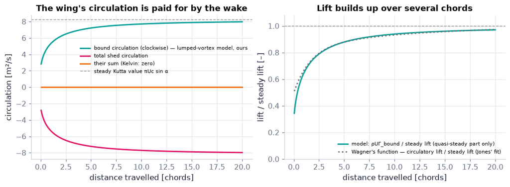

```
first value of Γ_bound/Γ_steady = 0.344; 90 % reached after 6.13 chords
model lift ratio minus Wagner's function at 1, 2, 5, 10 chords: [-0.019 -0.006  0.001  0.006]
```

```python
s_ch = run["s_chords"]                                       # distance travelled, in chords
lift_ratio = run["lift_circulatory"]/(1.0*sec["U"]*run["Gamma_steady"][0])   # the model's quasi-steady lift ρUΓ_bound over the steady lift ρUΓ_steady (ρ = 1 in this run)
fig, (axG, axL) = plt.subplots(1, 2, figsize=(10.0, 3.6))    # left: circulations; right: lift ratio
axG.plot(s_ch, run["Gamma_bound_cw"], color=COLORS["teal"], label="bound circulation (clockwise) — lumped-vortex model, ours")   # the wing
axG.plot(s_ch, run["Gamma_wake_cw"], color=COLORS["rose"], label="total shed circulation")        # the wake
axG.plot(s_ch, run["total"], color=COLORS["orange"], label="their sum (Kelvin: zero)")            # the invariant
axG.axhline(run["Gamma_steady"][0], color="0.6", ls="--", lw=1, label="steady Kutta value πUc sin α")   # the only reference on this panel
axG.set(xlabel="distance travelled [chords]", ylabel="circulation [m²/s]", title="The wing's circulation is paid for by the wake")   # labels
axG.legend(fontsize=7, loc="upper right", bbox_to_anchor=(1.0, 0.82))   # which curve is which — placed in the empty band between the bound curve and the zero line
axL.plot(s_ch, lift_ratio, color=COLORS["teal"], label="model: ρUΓ_bound / steady lift (quasi-steady part only)")   # our model's lift ratio
axL.plot(s_ch, ch14.wagner_function(s=2*s_ch), color="0.45", ls=":", lw=2, label="Wagner's function — circulatory lift / steady lift (Jones' fit)")   # the argument is in semi-chords = 2 × chords
axL.axhline(1.0, color="0.6", ls="--", lw=1)                 # the steady lift
axL.set(xlabel="distance travelled [chords]", ylabel="lift / steady lift [–]", ylim=(0, 1.08), title="Lift builds up over several chords")   # labels
axL.legend(fontsize=7, loc="lower right"); plt.show()      # legend and display
s90 = np.interp(0.9, run["ratio"], s_ch)                      # distance at which the bound circulation reaches 90 % of the steady value (the ratio rises steadily, so it can be read backwards)
print(f"first value of Γ_bound/Γ_steady = {run['ratio'][0]:.3f}; 90 % reached after {s90:.2f} chords")   # about 1/3 (0.344 with this step) and about 6.1 chords
print(f"model lift ratio minus Wagner's function at 1, 2, 5, 10 chords: {np.round((lift_ratio - ch14.wagner_function(s=2*s_ch))[[19, 39, 99, 199]], 3)}")   # the gap closes after two chords
```

**What you see.** The 20-chord run of the code cell. Left: bound circulation, shed circulation, their sum, and the steady Kutta value (dashed) — the only reference on that panel. Right: the model's lift ratio $\rho U\Gamma_{\text{bound}}$ over the steady lift, with Wagner's function (dotted).

**How to read it.** Wagner's function is a **lift** ratio — circulatory lift over steady lift, here in a published two-exponential fit (Jones' fit; its argument is in semi-chords) — so it belongs on the right panel, not on the circulation panel. The model's first $\Gamma_{\text{bound}}$ is 1/3 of the steady value (0.34 with this time step); in the exact thin-airfoil solution the circulation starts from zero and it is the circulatory lift that starts at one half; this model's $\rho U\Gamma_{\text{bound}}$ follows Wagner's lift function to about 1 % after two chords and runs above the exact circulation (0.65 against 0.55 after one chord). Two words: the **circulatory lift** is the part of the lift that the circulation carries (the rest, present only while the flow is changing, comes from accelerating the air next to the plate); **quasi-steady** means that each instant is treated as if the flow were steady with the circulation it has at that instant. `lift_circulatory` is the quasi-steady part $\rho U\Gamma_{\text{bound}}$ only — the $\rho\,d\Gamma/dt$ term is omitted. The model reaches 90 % of the steady value after about 6.1 chords (with this step of 0.05 chords).

**What would change if…** …the plate were ten times longer? Both panels are the same in chords: the transient lasts ten times longer in metres.

📝 **Note.** **N16 [B]** **Viscosity is responsible for the drag — and for the lift.** Without the boundary layer at the edge no vortex would be shed, no circulation would arise, and the wing would not lift. Once the circulation is set, the rest of the flow is nearly ideal.

📝 **Note.** **N17 [C]** The idea of circulation as the source of lift goes back to Lanchester, Kutta and Zhukhovsky, working independently; Lanchester and Prandtl return in N69 (C08).

> ⚠️ **slip #5 — the book prints** a birth year for Lanchester that would make him a child when he founded his motor company**; the correct form is** 1868.

#### 🎮 Interactive: Where does a wing's circulation come from?

**Why interactive rather than a static figure:** a new vortex of the right sign rolls off the edge at every change of speed or incidence while the amber total stays flat at zero — something only time can show.

Start with the **Walkthrough**; the **Explain** tab works every number out with your settings, and the **Derivation** tab (where there is one) steps through the same derivation as above. Γ is the clockwise circulation in every readout; angles are shown in degrees and computed in radians.

**What to try:**

- Press play on 'impulsive start' and watch the teal and rose curves mirror each other.
- Choose 'sudden stop': which way does the stopping vortex turn?
- Shrink the circuit until it cuts between foil and starting vortex and read the circulation it now encloses.
- Step α up half-way through a run and predict the sign of the new vortex first.

```python
show_viz("ch14", "starting_vortex")   # full-width explainer; ⤢ Full screen for more room
```

🎮 Interactive 1/9 Where does a wing's circulation come from? Open alone ↗

[interactive chart not shown]

**What would change if…** …we want Γ for a real section shape, not a plate? We need a family of shapes whose flow we can write down: C04.

## 14.4 Conformal Transformation for Generating Airfoil Shapes

**What is this section about?** A recipe for wing sections whose flow we can write down exactly: take a circle, move its centre, and push it through one simple map. Where the circle sits decides the camber and the thickness.

### 🧩 The Zhukhovsky airfoil: the circle $\lvert\zeta-\mu\rvert=a$ through $\zeta=b$, mapped by $z=\zeta+\dfrac{b^2}{\zeta}$ (14.3) `C04`

*The question:* How can one map turn a circle into a flat plate, a curved plate, a fat symmetric fin or a real-looking wing section?

#### The problem in plain words

We know the flow round a circle (Ch. 6). If we can find a change of coordinates that turns a circle into a wing section and leaves the far stream alone, the circle's flow *becomes* the wing's flow, for free. One such change is the Zhukhovsky map. Chapter 6 used it on a circle centred at the origin and got a flat plate. The new move here is to slide the circle's centre: a little up, a little back, always keeping the circle through the point $\zeta=b$. That one point is special — the map folds the plane there — and it becomes the sharp tail.

#### The idea

| Where the circle's centre is | What comes out | Controlled by |
| --- | --- | --- |
| at the origin | a flat plate of length $4b$ | — |
| raised (on the imaginary axis) | a circular arc | $\beta$ (camber) |
| shifted back (on the negative real axis) | a symmetric section: round nose, sharp tail | $e$ (thickness) |
| both | a cambered airfoil | $\beta$ and $e$ |

Two knobs, two properties. In this block the letter $b$ is the constant of the map (the chord is about $4b$), $a$ is the radius of the circle, $e$ is the thickness parameter and $\beta$ the camber angle of the circle.

> 🔁 **Tools from earlier chapters used in this block** (one line each; the full primers are in the chapters named)
- **complex numbers in numpy (`1j`, `np.exp(1j*t)`, `.real`, `.imag`, `np.abs`)** — a point of the plane is one number z = x + iy = r·e^(iθ) (`1j` is i in Python, `.real` and `.imag` are x and y, `np.abs` is r); multiplying two of them multiplies the lengths and adds the angles; here circles, sections and velocities are all arrays of complex numbers. *(Ch. 6, P153)*
- **Euler's formula** — e^(iθ) = cos θ + i sin θ is the point of the unit circle at the angle θ; here it writes the points of the circle that the map turns into a wing section. *(Ch. 1, P45)*
- **completing the square into a circle** — x² + y² + 2ky = c is the same as x² + (y + k)² = c + k², a circle centred at (0, −k); here it shows that the image of the raised circle is an arc of a circle. *(Ch. 11, P272)*
- **small-angle approximation** — for an angle ε measured in radians, sin ε ≈ tan ε ≈ ε and cos ε ≈ 1 when ε is much smaller than 1; here it turns the small camber angle β into the camber rule. *(Ch. 3, P100)*
- **sympy (`symbols`, `simplify`, `series`, `limit`, `integrate`)** — sympy does algebra with symbols: `sp.symbols` names them, `sp.simplify(a - b) == 0` proves two expressions equal, `sp.series` expands in a small parameter, `sp.limit` takes a limit, `sp.integrate` integrates. *(Ch. 1, P40, P117)*
- **orders of smallness ("first order in e")** — "to first order in e" means keeping the terms proportional to e and dropping e², e³, …, which are much smaller when e is small; here e ≈ 0.1 is the thickness parameter of the section. *(Ch. 2, P68, P342)*
- **Taylor expansion** — close to a point, f(z + δ) ≈ f(z) + f′(z)·δ, with an error that shrinks like δ²; here it is applied to the map near the trailing edge. *(Ch. 1, P26)*
- **parametric curves** — a curve given as (x(t), y(t)) for a parameter t; here the outline of a section is traced by letting the angle round the circle run from 0 to 2π. *(Ch. 3, P92)*

> 🔁 **Recap — The Zhukhovsky transformation `R05`** (Ch. 6 §6.6). $z=\zeta+\dfrac{b^2}{\zeta}$ (14.3) — the same map as $z=\zeta+\dfrac{b^2}{\zeta}$ (6.65). It is a *conformal map*: it sends each point ζ of one complex plane to a point $z$ of another and preserves angles between curves (except where its derivative vanishes). Far away $z\approx\zeta$, so the stream is untouched; near the origin the $b^2/\zeta$ term dominates. **New here:** circles that are not centred on the origin.

```python
print(CONF.joukowski(zeta=2j, b=1.0))                        # the point 2i maps to 2i + 1/(2i) = 1.5i
print(CONF.joukowski_inverse(z=1.5j, b=1.0))                 # and back: the root outside the unit circle is 2i
```

```
1.5j
2j
```

> 🔁 **Recap — The centred circle becomes a slit `R06`** (Ch. 6 §6.6). For $\zeta=be^{i\theta}$: $z=be^{i\theta}+be^{-i\theta}=2b\cos\theta$ — real, running from $2b$ to $-2b$ and back: a flat plate of length $4b$, traced twice (upper and lower side).

📝 **Note.** **N18 [C]** Other routes to the flow round a *given* section: solve Laplace's equation numerically (Ch. 6 panels, Ch. 10), **thin-airfoil theory** (a vortex sheet on the camber line; reused in Ch. 15), or **Theodorsen's method** (map the section back to a circle). We do the reverse: choose the map, accept the shape. One check line with thin-airfoil theory, for a parabolic camber line of 3.5 % camber:

```python
ta = AF.thin_airfoil(dyc_dx=lambda xc: 4*0.035*(1 - 2*xc), alpha=0.0)   # slope of a parabolic camber line with camber/chord = 0.035, at zero angle of attack
print(f"zero-lift angle = {ta['alpha_L0']:.4f} rad = {np.degrees(ta['alpha_L0']):.2f}°")   # ≈ −0.070 rad = −4.0° = −2 × camber/chord (N31 in C06 gets the same)
```

```
zero-lift angle = -0.0700 rad = -4.01°
```

📝 **Note.** **N25 [B]** Shift the centre to the left along the real axis by $be$ and enlarge the radius slightly: $a\equiv b(1+e)$, $e\ll1$ (14.7). The circle still passes through $\zeta=b$. **Not in the book — ours:** one parametrisation for all four cases, centre $\mu=b-ae^{-i\beta}$ and radius $a=b(1+e)/\cos\beta$. Points of the circle are $\zeta=\mu+ae^{it}$ with $t=-\beta$ at the point that becomes the trailing edge.

> ⚠️ **Common confusion:** (trap T7) the book defines $a=b(1+e)$ only for the symmetric case and $a=b/\cos\beta$ only for the arc; `AF.zhukhovsky_circle` gives both as limits and also accepts `a=` directly.

```python
print(AF.zhukhovsky_circle(b=1.0, e=0.1, beta=0.0))          # symmetric case: centre −0.1, radius 1.1 — the book's a = b(1 + e)
print(AF.zhukhovsky_circle(b=1.0, e=0.0, beta=np.arctan(0.75)))   # raised circle with tan β = 3/4: centre 0.75i, radius 1.25 = b/cos β
print(AF.zhukhovsky_circle(b=sec["b"], e=sec["e"], beta=sec["beta"]))   # our section: centre −0.0200 + 0.0189i m, radius 0.2707 m
```

```
((-0.10000000000000009+0j), 1.1)
(0.75j, 1.25)
((-0.020000000000000018+0.018880239224747814j), 0.2706593124819165)
```

**What does this show?** One function covers the book's two special cases and the general one. Each returned pair is (centre μ, radius a); every circle passes through $\zeta=b$ because $\mu+ae^{-i\beta}=b$.

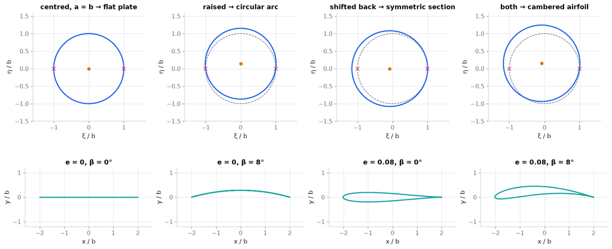

```python
fig = fig_four_circles()                                     # four circles (ζ-plane, above) and their images under z = ζ + b²/ζ (z-plane, below)
plt.show()                                                   # display
```

**What you see.** Top row: four circles in the ζ-plane, with the ghost circle of radius $b$ and the points $\pm b$ marked. Bottom row: what the map $z=\zeta+b^2/\zeta$ makes of each — a flat plate, a circular arc, a symmetric section, a cambered section.

**How to read it.** Every circle passes through $\zeta=b$, and that point always lands on the tail $z=2b$. Raising the centre bends the plate; moving it back swallows the point $-b$ and rounds the nose.

**What would change if…** …the circle missed $\zeta=b$? The tail would be rounded and the Kutta condition would have nothing to hold on to.

> 📎 **Primer — the cosine rule.** `P340` · In any triangle with sides $p$, $q$, $r$ and the angle $C$ between $p$ and $q$: $r^2=p^2+q^2-2pq\cos C$. With $C$ = 90° it is Pythagoras.

```python
p, q, C = 3.0, 4.0, np.deg2rad(60)            # two sides and the angle between them (60° = 1.047 rad)
print(np.sqrt(p**2 + q**2 - 2*p*q*np.cos(C)))   # third side: 3.606
```

```
3.6055512754639887
```

> 📎 **Primer — cot, csc and the double-angle identities.** `P341` · $\cot x=\cos x/\sin x=1/\tan x$; $\csc x=1/\sin x$. Two facts we need: $1+\cot^2x=\csc^2x$ and $\cot\beta-\tan\beta=2\cot2\beta$.

```python
B = 0.3                                       # any angle [rad]
print(1/np.tan(B) - np.tan(B), 2/np.tan(2*B))   # both 2.923: cot β − tan β = 2 cot 2β
print(1 + 1/np.tan(B)**2, 1/np.sin(B)**2)     # both 11.45: 1 + cot² = csc²
```

```
2.9233918941562043 2.9233918941562043
11.45053125149565 11.450531251495654
```

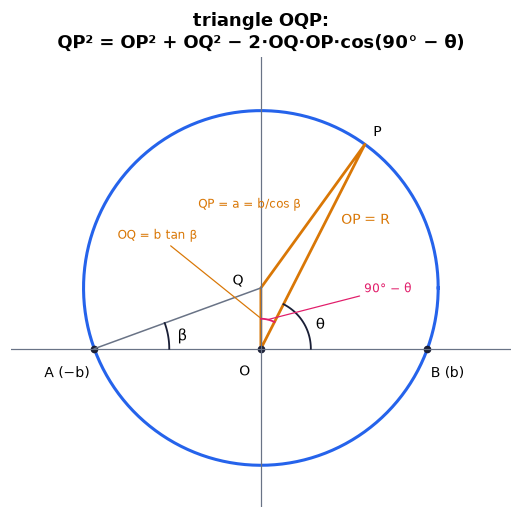

```python
fig = draw_triangle_OQP()                                    # the triangle O (origin) – Q (centre of the raised circle) – P (a point on it)
plt.show()                                                   # display the sketch used by steps 6–7 of the derivation below
```

> ⚠️ **Common confusion:** (trap T4) in the derivation below θ is the polar angle of ζ seen from the **origin** O, as in $x=(R+b^2/R)\cos\theta$, $y=(R-b^2/R)\sin\theta$ (14.4) — not the angle seen from the circle's centre Q.

#### 🧮 Derivation — A raised circle maps to a circular arc, and the camber rule `D03` ★★★ (Eq. 14.6: $2b\tan\beta\,\sin\theta=R-b^2/R=y/\sin\theta$)

**What we want to show.** Find the shape that the map makes of a circle whose centre has been raised, and so see where camber comes from. The book states two intermediate lines and the result; we fill in every move.

**Assumptions.** a > b, 0 < β < π/2; sin θ ≠ 0 and cos θ ≠ 0 while dividing (steps 3, 11), the excluded points recovered as limits; β ≪ 1 only in step 16.

**The plan.**

1. Split the image into x and y.
2. Eliminate R.
3. Find how R depends on θ on this particular circle (cosine rule).
4. Eliminate θ.
5. Recognise a circle.

**Tools we use** (each explained before this point): Euler's formula (P45, reminder) · difference of squares (gloss) · the cosine rule (P340) · cot, csc and the double-angle identities (P341) · completing the square into a circle (P272, reminder) · small angles (P100, reminder)

**We start from**

$$ \zeta=Re^{i\theta}\ \ \text{(a point of the raised circle)}\quad\text{put into}\quad z=\zeta+\dfrac{b^2}{\zeta}\ \text{(14.3)} $$

*In words:* A point of the circle of radius a = b/cos β centred at Q = ib tan β (it passes through ζ = ±b), written by its distance R from the origin and its polar angle θ.

**Step 1 of 16 — Map a point of the circle.**

$$ z=Re^{i\theta}+\dfrac{b^2}{R}e^{-i\theta} $$

- *Why we can do this:* Put ζ = $Re^{iθ}$ into the map $z=\zeta+b^2/\zeta$ (14.3); 1/ζ = $e^{−iθ}$/R. Here θ is the polar angle of ζ seen from the *origin* (trap T4).
- *In words:* The image is the point itself plus its reflection scaled by b²/R.

**Step 2 of 16 — Split into real and imaginary parts.**

$$ x=(R+b^2/R)\cos\theta,\qquad y=(R-b^2/R)\sin\theta\ \text{(14.4)} $$

- *Why we can do this:* Euler's formula, $e^{\pm i\theta}=\cos\theta\pm i\sin\theta$; collect the cosines (real) and the sines (imaginary).
- *In words:* The two parts add in x and subtract in y.

**Step 3 of 16 — Isolate the two brackets.**

$$ \dfrac{x}{\cos\theta}=R+\dfrac{b^2}{R},\qquad\dfrac{y}{\sin\theta}=R-\dfrac{b^2}{R} $$

- *Why we can do this:* Divide each member of step 2 by its trigonometric factor (allowed where it is not zero). We want R to appear only in a sum and a difference.
- *In words:* A sum and a difference of the same two numbers, R and b²/R.

**Step 4 of 16 — Square and subtract.**

$$ \dfrac{x^2}{\cos^2\theta}-\dfrac{y^2}{\sin^2\theta}=4b^2 $$

- *Why we can do this:* $(p+q)^2-(p-q)^2=4pq$ with p = R and q = b²/R, whose product is b²: R drops out. This is the elimination the book does in one phrase.
- *In words:* Whatever R is, x and y satisfy this one relation with θ.

**Step 5 of 16 — Clear the denominators.**

$$ x^2\sin^2\theta-y^2\cos^2\theta=4b^2\sin^2\theta\cos^2\theta\ \text{(14.5)} $$

- *Why we can do this:* Multiply step 4 by sin²θ cos²θ; the result also holds at the points excluded in step 3.
- *In words:* The book's first relation: no R left.

**Step 6 of 16 — Write the cosine rule for triangle OQP.**

$$ QP^2=OP^2+OQ^2-2\,(OQ)(OP)\cos(\widehat{QOP}) $$

- *Why we can do this:* O is the origin, Q the centre, P the point on the circle. We need a second relation, special to *this* circle, between R = OP and θ.
- *In words:* A triangle links the radius of the circle to R and θ.

**Step 7 of 16 — Insert the three lengths and the angle.**

$$ \dfrac{b^2}{\cos^2\beta}=R^2+b^2\tan^2\beta-2Rb\tan\beta\,\sin\theta $$

- *Why we can do this:* QP = a = b/cos β, OQ = b tan β, OP = R. OQ lies on the imaginary axis, OP at θ from the real axis: the angle between them is 90° − θ, with cosine sin θ.
- *In words:* The cosine rule with this circle's numbers.

**Step 8 of 16 — Simplify with a trigonometric identity.**

$$ R^2-b^2=2Rb\tan\beta\,\sin\theta $$

- *Why we can do this:* Move b² tan²β to the left: $b^2(1/\cos^2\beta-\tan^2\beta)=b^2$ because 1/cos² − tan² = 1.
- *In words:* On this circle R² exceeds b² by an amount proportional to sin θ.

**Step 9 of 16 — Divide by R and compare with y.**

$$ 2b\tan\beta\,\sin\theta=R-\dfrac{b^2}{R}=\dfrac{y}{\sin\theta}\ \text{(14.6)} $$

- *Why we can do this:* R > 0; the middle member is exactly the bracket of y in step 3. Now y is tied to θ alone.
- *In words:* The height of the image point is $y=2b\tan\beta\,\sin^2\theta$.

**Step 10 of 16 — Solve for the squared sine and cosine.**

$$ \sin^2\theta=\dfrac{y}{2b\tan\beta},\qquad\cos^2\theta=\dfrac{2b\tan\beta-y}{2b\tan\beta} $$

- *Why we can do this:* Rearrange step 9 and use sin² + cos² = 1. We prepare to remove θ from the relation of step 5.
- *In words:* Both are known once y is known — and y lies between 0 and 2b tan β.

**Step 11 of 16 — Divide the relation of step 5 by sin²θ.**

$$ x^2-y^2\cot^2\theta=4b^2\cos^2\theta $$

- *Why we can do this:* A legitimate division where sin θ ≠ 0; it leaves θ only inside cot²θ and cos²θ, which step 10 gives in terms of y.
- *In words:* One more form of the first relation.

**Step 12 of 16 — Substitute step 10 into the two terms that still contain θ.**

$$ x^2-y\,(2b\tan\beta-y)=4b^2-2by\cot\beta $$

- *Why we can do this:* From step 10, cot²θ = cos²θ/sin²θ = (2b tan β − y)/y, so y² cot²θ = y(2b tan β − y); and 4b² cos²θ = 4b²(2b tan β − y)/(2b tan β) = 4b² − 2by cot β. Putting both into step 11 removes θ, which is the aim: a relation between x and y alone.
- *In words:* The angle θ is gone; only x, y and the two constants b and β are left.

**Step 13 of 16 — Multiply out and collect the terms in y.**

$$ x^2+y^2+2by\,(\cot\beta-\tan\beta)=4b^2 $$

- *Why we can do this:* Expand −y(2b tan β − y) = −2by tan β + y², then move −2by cot β to the left-hand side, where it changes sign; the two terms proportional to by are grouped in one bracket.
- *In words:* A relation between x and y only: the equation of the image curve.

**Step 14 of 16 — Use the double-angle identity.**

$$ x^2+y^2+4by\cot2\beta=4b^2 $$

- *Why we can do this:* cot β − tan β = 2 cot 2β (P341).
- *In words:* A circle's equation, not yet in standard form.

**Step 15 of 16 — Complete the square in y.**

$$ x^2+(y+2b\cot2\beta)^2=(2b\csc2\beta)^2 $$

- *Why we can do this:* Add (2b cot 2β)² to both sides; on the right 4b²(1 + cot²2β) = 4b² csc²2β.
- *In words:* The image lies on a circle centred at (0, −2b cot 2β) with radius 2b csc 2β.

**Step 16 of 16 — Read off the height and the camber.**

$$ y_{\max}=2b\tan\beta,\qquad\dfrac{\text{camber}}{c}=\dfrac{2b\tan\beta}{4b}\simeq\dfrac\beta2 $$

- *Why we can do this:* From step 9 the largest y is at θ = 90°; the chord joins z = ±2b, so c = 4b; for β ≪ 1, tan β ≃ β (in radians).
- *In words:* A raised circle gives an arc of camber ½βc — the camber rule, camber $\simeq\tfrac12\beta c$ (14.8).

**Result**

$$ \begin{array}{l}x^2+(y+2b\cot2\beta)^2=(2b\csc2\beta)^2\ \text{with}\ \cos\beta=b/a\ \text{: a circular arc through z = ±2b of height 2b tan β;} \\ \text{camber}\ \simeq\tfrac12\beta c\ \text{(14.8)}\end{array} $$

*In words:* Raise the circle and the flat plate bends into an arc

**What it means.** Camber is how high the circle's centre sits; the two sharp ends are the two points ±b of the circle, where the map folds. **Fails when:** the circle does not pass through both ±b (then one end, or both, is rounded: C04's other cases).

**Check it.** Units — every term a length squared ✓. Limits — β → 0: the centre goes to −∞ and the radius to ∞: a straight plate; y = 0 at θ = 0, π: the ends are at z = ±2b. Number — b = 1, tan β = ¾: the top ζ = 2i maps to z = 1.5i = 2b tan β ✓, and −0.583 + 2.083 = 1.5 ✓. Only 0 ≤ y ≤ 2b tan β is covered, and twice (upper and lower half of the circle). The tangent at each end makes the angle 2β with the chord (the inscribed-angle property of a circle through ±2b with that centre).

```python
import sympy as sp                                              # symbolic algebra
b, R, th = sp.symbols("b R theta", positive=True)               # map constant, distance from O, polar angle
x = (R + b**2/R)*sp.cos(th)                                     # (14.4): real part of the image
y = (R - b**2/R)*sp.sin(th)                                     # (14.4): imaginary part of the image
lhs5 = x**2*sp.sin(th)**2 - y**2*sp.cos(th)**2                  # left side of (14.5)
assert sp.simplify(lhs5 - 4*b**2*sp.sin(th)**2*sp.cos(th)**2) == 0      # steps 3-5: (14.5) holds for every R
t = sp.symbols("t", positive=True)                              # t stands for tan(beta): identities become algebra
cosrule = R**2 + b**2*t**2 - 2*R*b*t*sp.sin(th) - b**2*(1 + t**2)       # steps 6-7: cosine rule (1/cos^2 = 1 + tan^2)
Rsol = b*t*sp.sin(th) + b*sp.sqrt(t**2*sp.sin(th)**2 + 1)       # its positive root R(theta): the circle itself
assert sp.simplify(cosrule.subs(R, Rsol)) == 0                  # the root satisfies the cosine rule
assert sp.simplify((R - b**2/R - 2*b*t*sp.sin(th)).subs(R, Rsol)) == 0  # steps 8-9: (14.6)
cot2b = (1 - t**2)/(2*t)                                        # cot(2 beta) written with tan(beta)
csc2b = (1 + t**2)/(2*t)                                        # csc(2 beta) written with tan(beta)
assert sp.simplify(csc2b**2 - 1 - cot2b**2) == 0                # 1 + cot^2 = csc^2 survives the rewriting
Y = 2*b*t*sp.sin(th)**2                                         # step 9: y from (14.6) joined to (14.4)
X2 = 4*b**2*sp.cos(th)**2 + Y**2*sp.cos(th)**2/sp.sin(th)**2    # step 11: x^2 from (14.5) divided by sin^2
arc = X2 + (Y + 2*b*cot2b)**2 - (2*b*csc2b)**2                  # steps 12-15: the circle of the arc, all on one side
assert sp.simplify(arc) == 0                                    # every image point lies on that circle
print(sp.simplify(Y.subs(th, sp.pi/2)))                         # step 16: 2*b*t, the arc's height 2b tan(beta)
```

```
2*b*t
```

📝 **Notes taught inside `D03`:** **N19 [B]** a point of the circle in polar form from the origin (the Start) · **N20 [B]** $x=(R+b^2/R)\cos\theta$, $y=(R-b^2/R)\sin\theta$ (14.4) (step 2) · **N21 [B]** $x^2\sin^2\theta-y^2\cos^2\theta=4b^2\sin^2\theta\cos^2\theta$ (14.5) (steps 3–5) · **N22 [B]** the cosine rule in the triangle OQP (steps 6–7) · **N23 [B]** $2b\tan\beta\,\sin\theta=R-b^2/R=y/\sin\theta$ (14.6) (steps 8–9) · **N24 [B]** the circular arc $x^2+(y+2b\cot2\beta)^2=(2b\csc2\beta)^2$ (steps 10–15) · the camber rule of **N26** (step 16).

> ⚠️ **Common confusion (traps in `D03`):** Dividing by sin θ and cos θ without recovering the excluded points; taking the angle at O as θ instead of 90° − θ; forgetting that the arc is traced twice; β is the circle's angle and the end tangent is 2β; the camber rule is first order in β.

```python
print(ch14.circular_arc_sym()["ok"])                         # the module's own symbolic engine re-does (14.4) → (14.5) → (14.6) → the arc: True
arc = AF.circular_arc(b=sec["b"], beta=sec["beta"])          # the arc for our b = 0.25 m and β = 4°: centre, radius, height, end angle
S_arc = AF.zhukhovsky_airfoil(b=sec["b"], e=0.0, beta=sec["beta"])   # the mapped raised circle (no thickness)
res = np.abs(np.abs(S_arc["z"] - arc["centre"]) - arc["radius"]).max()   # largest distance of a mapped point from that circle [m]
print(f"height = {arc['height']:.4f} m, centre = {arc['centre'].imag:.3f}i m, radius = {arc['radius']:.3f} m, end angle = {np.degrees(arc['end_angle']):.1f}° ({arc['end_angle']:.4f} rad)")   # 0.0350, −3.558i, 3.593, 8°
print(f"largest distance of a mapped point from the arc's circle = {res:.1e} m")   # round-off: every mapped point lies on it
```

```
True
height = 0.0350 m, centre = -3.558i m, radius = 3.593 m, end angle = 8.0° (0.1396 rad)
largest distance of a mapped point from the arc's circle = 8.9e-16 m
```

**What does the code above do?**

1. `ch14.circular_arc_sym()` is a sympy engine that repeats the derivation's chain; `"ok"` is True when every residual is zero.
2. `AF.circular_arc` returns the circle of the result for our numbers: its centre is far below the chord (−3.558 m), its radius 3.593 m, and the arc rises 35 mm above a chord of 1 m. The tangent at each end makes the angle 2β = 8° with the chord.
3. The residual is at round-off level: every point of the mapped circle lies on that arc. The arc is traced twice — the lower half of the circle lands on the same arc.

> 📎 **Primer — binomial approximation with a complex small quantity.** `P342` · For a small number ε — real or complex — $\dfrac1{1+\epsilon}\approx1-\epsilon$, with an error of about ε². "First order in $e$" means: keep $e$, drop $e^2$ (orders of smallness, primed in Ch. 2, P68).

```python
eps = 0.05*(1 - np.exp(-1j*2.0))              # a small complex number, size 0.08
print(1/(1 + eps), 1 - eps)                   # agree to about 0.007 = abs(eps)**2
```

```
(0.9321943181799002-0.03957957055916258j) (0.9291926581726428-0.04546487134128409j)
```

#### 🧮 Derivation — A circle shifted back gives a symmetric section: chord, thickest point and thickness rule `D04` ★★★ (Eq. 14.8: $c\simeq4b,\ \ \text{camber}\simeq\tfrac12\beta c,\ \ t_{\max}/c\simeq1.3\,e$)

**What we want to show.** Find the shape made by a circle whose centre is moved back along the real axis, and so see where thickness comes from. The book says the rules "can be proved"; this is the proof.

**Assumptions.** e ≪ 1 — terms of order e² are dropped (steps 3–5); each ≈ marks it.

**The plan.**

1. Write the circle with a small parameter.
2. Map it, keeping only first powers of e.
3. Read off x and y.
4. Find the chord.
5. Maximise the thickness.

**Tools we use** (each explained before this point): binomial approximation with a complex small quantity (P342) · Euler's formula (P45, reminder) · maximum of a function by a zero derivative (gloss)

**We start from**

$$ \lvert\zeta+be\rvert=a,\qquad a\equiv b(1+e)\ \text{(14.7)} $$

*In words:* The circle of radius a centred at ζ = −be — slightly larger than b, slightly to the left — so that it still passes through ζ = b.

**Step 1 of 11 — Write the points of the shifted circle.**

$$ \zeta=-be+b(1+e)\,e^{i\theta} $$

- *Why we can do this:* Centre −be plus radius b(1 + e) times a unit direction; θ is now the angle at the circle's *centre*. At θ = 0, ζ = b: the circle passes through the critical point.
- *In words:* A circle a little bigger than b, pushed a little to the left.

**Step 2 of 11 — Factor out the unshifted point.**

$$ \zeta=b\,e^{i\theta}(1+\epsilon),\qquad\epsilon=e\,(1-e^{-i\theta}) $$

- *Why we can do this:* Divide the two e-terms by b $e^{iθ}$: e − e $e^{−iθ}$. This isolates everything small in one complex number ε, of size at most 2e.
- *In words:* The circle of radius b, times a factor close to one.

**Step 3 of 11 — Invert with the binomial approximation.**

$$ \dfrac{b^2}{\zeta}=b\,e^{-i\theta}(1+\epsilon)^{-1}\approx b\,e^{-i\theta}(1-\epsilon) $$

- *Why we can do this:* For small ε, 1/(1 + ε) ≈ 1 − ε with an error of order ε², i.e. e² (P342). We keep first order because e ≪ 1.
- *In words:* The reflected point, to first order in e.

**Step 4 of 11 — Add the two parts of the map.**

$$ z\approx2b\cos\theta+2i\,b\,\epsilon\sin\theta $$

- *Why we can do this:* z = ζ + b²/ζ = b $e^{iθ}$ + b $e^{−iθ}$ + bε($e^{iθ}$ − $e^{−iθ}$); the first pair is 2b cos θ and the bracket is 2i sin θ (Euler).
- *In words:* The flat plate plus a small correction proportional to e.

**Step 5 of 11 — Separate real and imaginary parts.**

$$ x\approx2b\cos\theta-2be\sin^2\theta,\qquad y\approx2be\,\sin\theta\,(1-\cos\theta) $$

- *Why we can do this:* Insert ε = e(1 − cos θ + i sin θ): 2ibε sin θ = 2ibe sin θ(1 − cos θ) − 2be sin²θ.
- *In words:* The outline: x is nearly the plate's, y is small and proportional to e.

**Step 6 of 11 — Find the chord.**

$$ x(0)=2b,\quad x(\pi)=-2b\ \Rightarrow\ c\simeq4b $$

- *Why we can do this:* The tail is θ = 0, the nose θ = π; the correction −2be sin²θ vanishes at both. (Exactly, c = 4b(1 + e² + …): the error is second order.)
- *In words:* The chord is four times b, as for the plate.

**Step 7 of 11 — Express the thickness.**

$$ t(\theta)=2\,y(\theta)\approx4be\,\sin\theta\,(1-\cos\theta) $$

- *Why we can do this:* y(−θ) = −y(θ) while x(−θ) = x(θ): the section is symmetric about the x-axis, so the thickness at a station is twice the upper ordinate.
- *In words:* Thickness along the section, in terms of the circle angle.

**Step 8 of 11 — Set the derivative to zero.**

$$ \dfrac{dy}{d\theta}=2be\,(\cos\theta-\cos2\theta)=0 $$

- *Why we can do this:* A smooth function is largest where its slope vanishes. Product rule: d/dθ[sin θ − sin θ cos θ] = cos θ − cos²θ + sin²θ = cos θ − cos 2θ.
- *In words:* The thickest station is where cos θ = cos 2θ.

**Step 9 of 11 — Solve for the angle.**

$$ 2\theta=2\pi-\theta\ \Rightarrow\ \theta=\dfrac{2\pi}{3} $$

- *Why we can do this:* Two angles have equal cosines when they are equal (θ = 0: the tail, zero thickness) or add up to 2π; the second gives 120°.
- *In words:* The thickest point comes from the point of the circle 120° round from the tail.

**Step 10 of 11 — Evaluate the maximum.**

$$ t_{\max}\approx4be\cdot\dfrac{\sqrt3}{2}\cdot\dfrac32=3\sqrt3\,be,\qquad\dfrac{t_{\max}}{c}\simeq\dfrac{3\sqrt3}{4}\,e\approx1.3\,e\ \text{(14.8)} $$

- *Why we can do this:* sin 120° = √3/2 and 1 − cos 120° = 3/2; divide by c = 4b. The exact coefficient is 3√3/4 = 1.299.
- *In words:* The thickness ratio is 1.3 times the fractional enlargement of the circle.

**Step 11 of 11 — Locate it along the chord.**

$$ x\!\left(\tfrac{2\pi}3\right)\approx2b\cos\tfrac{2\pi}3=-b $$

- *Why we can do this:* Step 5 at θ = 120°, to leading order. The nose is at −2b and the tail at +2b, so x = −b is a quarter of the chord behind the nose.
- *In words:* The section is thickest at the quarter-chord point.

**Result**

$$ c\simeq4b\ \text{and}\ t_{\max}/c\simeq\tfrac{3\sqrt3}4e\approx1.3\,e\ \text{at x = −b, two of the three rules of (14.8)} $$

*In words:* Move the circle back and the nose fattens

**What it means.** Thickness is how far back the circle sits; because the circle still passes through ζ = b the tail stays sharp, and because −b is now inside the nose is round. **Fails when:** e is not small — at e = 0.25 the rule is a quarter too high (the "rule against measured" table).

**Check it.** Units — t and c lengths; e dimensionless ✓. Limits — e → 0: y → 0, the plate. Number — e = 0.1: rule 0.1299; measured on the exact contour 0.1179 (9 % lower: the neglected e² terms), chord 4.033b against 4b. The tail: near θ = 0, y ≈ be θ³ while 2b − x ≈ bθ², so y ∝ (2b − x)^(3/2): both surfaces leave the tail tangent to the chord — a cusp (D05).

```python
import sympy as sp                                              # symbolic algebra
b, e = sp.symbols("b e", positive=True)                         # map constant, thickness parameter
th = sp.symbols("theta", real=True)                             # angle round the circle, seen from its centre
zeta = -b*e + b*(1 + e)*sp.exp(sp.I*th)                         # step 1: the shifted circle through zeta = b
z = zeta + b**2/zeta                                            # the Zhukhovsky map (14.3)
z1 = sp.series(z, e, 0, 2).removeO()                            # steps 2-4: keep terms up to first order in e
x1 = sp.simplify(sp.re(sp.expand(z1.rewrite(sp.cos), complex=True)))   # step 5: real part
y1 = sp.simplify(sp.im(sp.expand(z1.rewrite(sp.cos), complex=True)))   # step 5: imaginary part
assert sp.simplify(x1 - (2*b*sp.cos(th) - 2*b*e*sp.sin(th)**2)) == 0   # x = 2b cos(theta) - 2be sin^2(theta)
assert sp.simplify(y1 - 2*b*e*sp.sin(th)*(1 - sp.cos(th))) == 0        # y = 2be sin(theta)(1 - cos(theta))
dy = sp.diff(y1, th)                                            # step 8: slope of the half-thickness along the circle
assert sp.simplify(dy.subs(th, 2*sp.pi/3)) == 0                 # step 9: zero at theta = 120 degrees
ymax = sp.simplify(y1.subs(th, 2*sp.pi/3))                      # step 10: the largest half-thickness
assert sp.simplify(2*ymax/(4*b) - 3*sp.sqrt(3)/4*e) == 0        # step 10: t_max/c = (3 sqrt(3)/4) e
assert sp.simplify(x1.subs(th, 2*sp.pi/3).subs(e, 0) + b) == 0  # step 11: it sits at x = -b, the quarter chord
print(float(3*sp.sqrt(3)/4))                                    # 1.299...: the book's 1.3
```

```
1.299038105676658
```

> ⚠️ **Common confusion (traps in `D04`):** The centre is at −be, not −e; the maximum of sin θ(1 − cos θ) is at 120°, not 90°; thickness is twice y; the chord correction is second order (slip #4: the printed 1.3 is 3√3/4 rounded, and the rule is first order in e).

📝 **Note.** **N26 [B]** The three shape rules: $c\simeq4b$, camber $\simeq\tfrac12\beta c$, $t_{\max}/c\simeq1.3\,e$ (14.8), with the thickest point near the quarter chord, $x=-b$.

> ⚠️ **slip #4 — the book prints** “camber = ≅ ½βc” with two relation signs, and the coefficient 1.3 in $t_{\max}/c\cong1.3\,e$ (14.8)**; the correct form is** camber $\simeq\tfrac12\beta c$, and the coefficient is $3\sqrt3/4=1.299$ (derived above) — a first-order rule in $e$.

```python
rows = []                                                    # one row per thickness parameter
for e_ in (0.02, 0.05, 0.10, 0.25):                          # from thin to very fat
    meas = AF.zhukhovsky_shape(b=1.0, e=e_, beta=0.0, exact=True)     # measured on the exact contour
    rule = AF.zhukhovsky_shape(b=1.0, e=e_, beta=0.0, exact=False)    # the first-order rules of (14.8)
    rows.append({"e": e_, "t/c measured": meas["thickness_ratio"], "t/c rule 1.299 e": rule["thickness_ratio"],
                 "rule too high by [%]": 100*(rule["thickness_ratio"]/meas["thickness_ratio"] - 1), "chord/4b": meas["chord"]/4.0})   # collect
print(pd.DataFrame(rows).round(4).to_string(index=False))    # the approximation made measurable
cam = [(np.degrees(B_), AF.zhukhovsky_shape(b=1.0, e=0.0, beta=B_, exact=True)["camber_ratio"], B_/2) for B_ in np.deg2rad([2.0, 4.0, 6.0, 12.0])]   # camber/chord measured against β/2
print(pd.DataFrame(cam, columns=["β [°]", "camber/c measured", "rule β/2"]).round(4).to_string(index=False))   # the camber rule
```

```
   e  t/c measured  t/c rule 1.299 e  rule too high by [%]  chord/4b
0.02        0.0255            0.0260                2.0098    1.0004
0.05        0.0618            0.0650                5.0596    1.0023
0.10        0.1179            0.1299               10.2277    1.0083
0.25        0.2572            0.3248               26.2625    1.0417
 β [°]  camber/c measured  rule β/2
   2.0             0.0175    0.0175
   4.0             0.0350    0.0349
   6.0             0.0526    0.0524
  12.0             0.1063    0.1047
```

**What does this show?** The thickness rule is a first-order statement: it overshoots the measured thickness ratio by 2 %, 5 %, 10 % and 26 % at $e$ = 0.02, 0.05, 0.10 and 0.25 (the fourth column; put the other way round, the measured value is 2 %, 5 %, 9 % and 21 % below the rule). The chord is within 1 % of $4b$ up to $e$ = 0.1. The camber rule holds within 1 % up to β = 6°.

#### ✏️ Tiny example: a raised circle by hand

$b$ = 1, tan β = 3/4 (β ≈ 36.9°; far from thin, but the numbers are easy).

1. Radius $a=b/\cos\beta$ = 1.25; centre Q at 0.75i.
2. Top of the circle: ζ = 0.75i + 1.25i = 2i. Its image under $z=\zeta+\dfrac{b^2}{\zeta}$ (14.3): 2i + 1/(2i) = 2i − 0.5i = 1.5i.
3. Bottom of the circle: ζ = −0.5i → z = −0.5i + 1/(−0.5i) = −0.5i + 2i = 1.5i — the *same* point: the arc is covered twice.
4. Ends: ζ = ±1 → z = ±2.
5. The arc's circle: centre at −2b cot 2β = −0.583, radius 2b csc 2β = 2.083; check the top: −0.583 + 2.083 = 1.5 ✓; check an end: √(2² + 0.583²) = 2.083 ✓.
6. Height 2b tan β = 1.5 ✓.

```python
S = AF.zhukhovsky_airfoil(b=sec["b"], e=sec["e"], beta=sec["beta"])            # our section: the circle's points and their images
sh = AF.zhukhovsky_shape(b=sec["b"], e=sec["e"], beta=sec["beta"], exact=True)  # chord, camber and thickness measured on the contour
rule = AF.zhukhovsky_shape(b=sec["b"], e=sec["e"], beta=sec["beta"], exact=False)   # the same from the rules of (14.8)
print(f"chord            {sh['chord']:.4f} m   (rule 4b = {rule['chord']:.4f} m)")          # 1.0055 against 1.0
print(f"camber/chord     {sh['camber_ratio']:.4f}     (rule β/2 = {rule['camber_ratio']:.4f})")   # 0.0346 against 0.0349
print(f"thickness/chord  {sh['thickness_ratio']:.4f}     (rule 1.299 e = {rule['thickness_ratio']:.4f})")   # 0.0964 against 0.1039
print(f"thickest at      {100*sh['x_tmax_over_c']:.1f} % of the chord")                     # 25 %: the quarter chord
```

```
chord            1.0055 m   (rule 4b = 1.0000 m)
camber/chord     0.0346     (rule β/2 = 0.0349)
thickness/chord  0.0964     (rule 1.299 e = 0.1039)
thickest at      25.0 % of the chord
```

**What does the code above do?**

1. `AF.zhukhovsky_airfoil` returns the circle's points `zeta`, their images `z` (and `x`, `y`) for our $b$ = 0.25 m, $e$ = 0.08, β = 4°.
2. `AF.zhukhovsky_shape(exact=True)` measures the contour; `exact=False` returns the three rules of $c\simeq4b$, camber $\simeq\tfrac12\beta c$, $t_{\max}/c\simeq1.3\,e$ (14.8).
3. Chord and camber agree with the rules to better than 1 %; the thickness rule is 8 % high at $e$ = 0.08; the thickest point is at the quarter chord, as derived.

```python
b, e, beta = sec["b"], sec["e"], sec["beta"]                 # map constant [m], thickness parameter, camber angle [rad]
t = -beta + 2*np.pi*np.arange(400)/400                       # 400 angles round the circle from its centre, starting at the tail point (t = −β)
zeta = mu + a*np.exp(1j*t)                                   # the circle: centre μ, radius a (both from the imports cell)
z = zeta + b**2/zeta                                         # Eq. (14.3): the Zhukhovsky map, applied to all 400 points at once
chord_mine = z.real.max() - z.real.min()                     # chord = extent in x [m]
assert np.allclose(z, S["z"])                                # same points → the library does exactly this
assert np.isclose(chord_mine, sh["chord"], rtol=1e-4)        # and the same chord
print(f"chord = {chord_mine:.4f} m; the tail point maps to z = {z[0]:.4f} (= 2b)")   # 1.0055 m; 0.5
```

```
chord = 1.0055 m; the tail point maps to z = 0.5000+0.0000j (= 2b)
```

**What does the code above do?**

1. One line builds the circle from its centre and radius as complex numbers; one line maps it with $z=\zeta+\dfrac{b^2}{\zeta}$ (14.3).
2. The asserts confirm that `AF.zhukhovsky_airfoil` and `AF.zhukhovsky_shape` do the same.

> 🔁 **Recap — Corner flows `R07`** (Ch. 6 §6.4). A flow $w=Az^n$ turns a corner; here as the flow *leaving* a trailing edge of finite included angle $2\pi(1-1/n)$: $\phi=\dfrac{Ud}{n}\Big(\dfrac rd\Big)^{n}\cos n\theta$, with speed $U(r/d)^{n-1}$ → 0 at the edge for $n>1$.

```python
wedge = ch14.trailing_edge_wedge(n=1.05)                     # the corner flow leaving an edge with exponent n = 1.05
print(f"included angle of the edge = {wedge['included_angle']:.3f} rad = {np.degrees(wedge['included_angle']):.1f}°")   # 0.299 rad = 17.1°
print(f"speed at r/d = 1e-2, 1e-4, 1e-8: {[round(float(wedge['speed'](r_)), 3) for r_ in (1e-2, 1e-4, 1e-8)]} U")        # falls only slowly: r^0.05
```

```
included angle of the edge = 0.299 rad = 17.1°
speed at r/d = 1e-2, 1e-4, 1e-8: [0.794, 0.631, 0.398] U
```

#### 🧮 Derivation — The trailing edge is a cusp; a finite edge angle would need a stagnation point `D05` ★★ (Eq. 14.3: $z=\zeta+\dfrac{b^2}{\zeta}$)

**What we want to show.** See why the one point ζ = b turns a smooth circle into a sharp tail, what kind of sharpness it is, and why that matters for the flow. The book states it with a figure.

**Assumptions.** The circle passes through ζ = b and has ζ = −b inside it.

**The plan.**

1. Find where the stretching vanishes.
2. Expand the map there.
3. Read the angle doubling.
4. Compare with a wedge-shaped edge.

**Tools we use** (each explained before this point): derivative of a power · Taylor expansion (P26, reminder) · critical point of a map and angle doubling (ch06, recap in the block) · corner flows (R07) · the geometric series $\dfrac{1}{1+x}=1-x+x^2-\dots$ for |x| < 1 (kept to second order in step 4; it is the Taylor expansion of 1/(1 + x) carried one term further)

**We start from**

$$ z=\zeta+\dfrac{b^2}{\zeta}\ \text{(14.3)}\quad\Longrightarrow\quad\dfrac{dz}{d\zeta}\ \text{(the local magnification)} $$

*In words:* How the map stretches and turns a small step dζ.

**Step 1 of 7 — Differentiate the map.**

$$ \dfrac{dz}{d\zeta}=1-\dfrac{b^2}{\zeta^2} $$

- *Why we can do this:* d(1/ζ)/dζ = −1/ζ². A small step dζ becomes dz = (dz/dζ) dζ: stretched by the size of this number and turned by its angle.
- *In words:* The map's local magnification.

**Step 2 of 7 — Find where it vanishes.**

$$ \dfrac{dz}{d\zeta}=0\ \Longleftrightarrow\ \zeta=\pm b $$

- *Why we can do this:* 1 − b²/ζ² = 0 gives ζ² = b². At such critical points the map is not angle-preserving.
- *In words:* Two special points, on the real axis at ±b.

**Step 3 of 7 — Place them relative to the circle.**

$$ \zeta=-b\ \text{inside},\qquad\zeta=+b\ \text{on the circle}\ \to\ z=2b $$

- *Why we can do this:* Our circles pass through +b by construction; shifting the centre left puts −b inside, where there is no fluid.
- *In words:* Only one critical point touches the fluid: it becomes the tail.

**Step 4 of 7 — Expand the map near ζ = b.**

$$ z=2b+\dfrac{\delta^2}{b}+\dots,\qquad\delta=\zeta-b $$

- *Why we can do this:* b²/(b + δ) = b(1 − δ/b + δ²/b² − …) by the geometric series; the terms linear in δ cancel, as they must where dz/dζ = 0.
- *In words:* Near the tail the map squares the small displacement.

**Step 5 of 7 — Read off the angles.**

$$ \delta=re^{i\varphi}\ \Rightarrow\ z-2b=\dfrac{r^2}{b}\,e^{2i\varphi} $$

- *Why we can do this:* Squaring a complex number doubles its angle. The circle leaves B in two opposite directions (φ and φ + π); their images differ by 2π: the same direction.
- *In words:* The two surfaces leave the tail tangent to each other: a cusp, with zero included angle.

**Step 6 of 7 — Compare with a wedge-shaped edge.**

$$ \phi=\dfrac{Ud}{n}\Big(\dfrac rd\Big)^{n}\cos n\theta,\qquad q=U\Big(\dfrac rd\Big)^{n-1} $$

- *Why we can do this:* The smooth flow leaving an edge of included angle 2π(1 − 1/n) is a corner flow (R07); its speed is the size of ∇φ.
- *In words:* How fast the fluid moves at distance r from an edge of finite angle.

**Step 7 of 7 — Let r → 0.**

$$ n>1:\ q\to0;\qquad n=1:\ q=U $$

- *Why we can do this:* A positive power of r vanishes at r = 0; n = 1 is the cusp (included angle 0), where the power is zero.
- *In words:* A finite-angle edge has a stagnation point; a cusp does not — the fluid leaves it at a finite speed.

**Result**

$$ \begin{array}{l}\dfrac{dz}{d\zeta}=1-\dfrac{b^2}{\zeta^2}=0\ \text{at ζ = b,}\ z-2b\simeq(\zeta-b)^2/b\ \text{: the tail of a Zhukhovsky section is a cusp,} \\ \text{and the Kutta flow passes it at a finite, non-zero speed.}\end{array} $$

**What it means.** The sharp tail is built into the map; and because 1/(dz/dζ) is infinite there, the fluid speed is too unless the circle's flow stagnates at B — which is the Kutta condition (C05, C06). **Fails when:** a real wing cannot be built with a cusp (N33).

**Check it.** Units — δ²/b is a length ✓. Number — a 17° wedge is n = 1.05: speed ∝ $r^{0.05}$, zero only very close to the edge. Code — `AF.trailing_edge_angle` of our contour tends to 0 as the number of points grows.

📝 **Notes taught inside `D05`:** **N27 [B]** the trailing edge of a Zhukhovsky section is a cusp; an edge of finite angle would carry a stagnation point.

> ⚠️ **Common confusion (traps in `D05`):** The other critical point −b must be *inside* the circle; "cusp" describes the body, "stagnation point" the flow — at a cusp the Kutta flow does not stagnate.

```
included angle at the tail measured on 400 and 4000 points: 0.14°, 0.01°
```

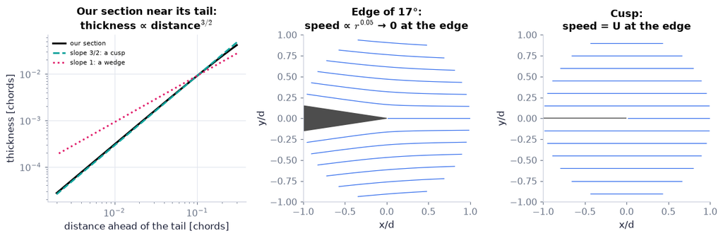

```python
S_fine = AF.zhukhovsky_airfoil(b=sec["b"], e=sec["e"], beta=sec["beta"], n=4000)   # our section with many points, to zoom on the tail
print(f"included angle at the tail measured on 400 and 4000 points: {np.degrees(AF.trailing_edge_angle(x=S['x'], y=S['y'])):.2f}°, {np.degrees(AF.trailing_edge_angle(x=S_fine['x'], y=S_fine['y'])):.2f}°")   # tends to 0: a cusp
geo = AF.section_geometry(x=S_fine["x"], y=S_fine["y"])     # upper and lower surface of the fine outline on common chordwise stations (in chords)
dist = 1.0 - geo["xc"]                                       # distance ahead of the tail [chords]
thick = geo["y_upper"] - geo["y_lower"]                      # thickness of the section there [chords]
keep = (dist > 2e-3) & (dist < 0.3)                          # from 0.2 % to 30 % of the chord ahead of the tail
k_ref = np.argmin(np.abs(dist - 0.1))                        # anchor the two reference lines at 10 % of the chord
fig, axes = plt.subplots(1, 3, figsize=(11.6, 3.7))          # thickness near the tail; an edge of finite angle; a cusp
axes[0].loglog(dist[keep], thick[keep], color="k", lw=2.2, label="our section")   # both axes logarithmic: a power law is a straight line whose slope is the power
axes[0].loglog(dist[keep], thick[k_ref]*(dist[keep]/dist[k_ref])**1.5, color=COLORS["teal"], ls="--", label="slope 3/2: a cusp")   # thickness ∝ distance^1.5
axes[0].loglog(dist[keep], thick[k_ref]*(dist[keep]/dist[k_ref])**1.0, color=COLORS["rose"], ls=":", label="slope 1: a wedge")     # what an edge of finite angle would give
axes[0].set(xlabel="distance ahead of the tail [chords]", ylabel="thickness [chords]", title="Our section near its tail:\nthickness ∝ distance$^{3/2}$")   # labels
axes[0].legend(fontsize=7)                                   # which line is which
rr, tt = np.meshgrid(np.linspace(0.01, 1.0, 80), np.linspace(-np.pi, np.pi, 361))   # polar grid round the edge: radius r/d and angle θ
for ax, n_ in zip(axes[1:], (1.05, 1.0)):                    # exponent 1.05 (a 17° edge) and 1 (a cusp)
    psi = np.where(np.abs(tt) < np.pi/n_, rr**n_*np.sin(n_*tt), np.nan)   # stream function r^n sin(nθ) in the fluid; the body fills |θ| > π/n
    ax.contour(rr*np.cos(tt), rr*np.sin(tt), psi, levels=np.linspace(-0.9, 0.9, 13), colors=COLORS["blue"], linewidths=0.8, linestyles="solid")   # streamlines leaving the edge to the right (all solid, whatever the sign of ψ)
    ax.fill([0, -np.cos(np.pi*(1 - 1/n_)), -np.cos(np.pi*(1 - 1/n_))], [0, np.sin(np.pi*(1 - 1/n_)), -np.sin(np.pi*(1 - 1/n_))], color="0.3")   # the solid edge (a wedge; a line for the cusp)
    ax.set(xlabel="x/d", ylabel="y/d", title=("Edge of 17°:\nspeed ∝ $r^{0.05}$ → 0 at the edge" if n_ > 1 else "Cusp:\nspeed = U at the edge"))   # labels, on two lines so that neighbours do not collide
    ax.set_aspect("equal")                                   # true proportions
    ax.grid(False)                                           # no background grid under the streamlines
plt.show()                                                   # display
```

**What you see.** Left: the thickness of our section against the distance ahead of its tail, on two logarithmic axes, with two reference slopes. Middle: streamlines leaving an edge with a 17° included angle. Right: streamlines leaving a cusp.

**How to read it.** On logarithmic axes a power law is a straight line and its slope is the power. The section follows the dashed slope 3/2, not the dotted slope 1 of a wedge: halve the distance to the tail and the thickness falls by 2.8, not by 2, so the two surfaces close *tangent* to each other — a cusp. At an edge of finite angle (middle) the streamlines spread apart as they approach the edge: the fluid slows to rest there (a stagnation point). At a cusp (right) they stay evenly spaced: the fluid leaves at a finite speed. The printed angles show the measured tail angle shrinking toward zero as the outline is resolved more finely.

**What would change if…** …the edge were blunter (larger $n$)? The speed would vanish faster, like $r^{n-1}$.

```python
n_frames = 40 if not FAST else 20                            # number of frames (fewer when FAST)
half = n_frames//2                                           # first half: raise the centre; second half: move it back
tt = np.linspace(0, 2*np.pi, 241)                            # angle round the circle
fig, (axZ, axz) = plt.subplots(1, 2, figsize=(9.0, 3.3))     # left: the ζ-plane (circle); right: the z-plane (section)
axZ.plot(sec["b"]*np.cos(tt), sec["b"]*np.sin(tt), color="0.7", ls=":")   # ghost circle of radius b
axZ.plot([sec["b"]], [0], "o", color=COLORS["orange"])       # the point ζ = b, which becomes the tail
(circ,) = axZ.plot([], [], color=COLORS["accent"])           # the moving circle
(cen,) = axZ.plot([], [], "x", color=COLORS["accent"])       # its centre μ
(outline,) = axz.plot([], [], color="k")                     # the section
axZ.set(xlim=(-0.4, 0.4), ylim=(-0.36, 0.4), xlabel="ξ [m]", ylabel="η [m]")   # fixed axes
axZ.set_aspect("equal")                                      # a circle looks like a circle
axz.set(xlim=(-0.6, 0.6), ylim=(-0.2, 0.25), xlabel="x [m]", ylabel="y [m]")   # fixed axes
axZ.set_title("β = 0.0° (0.000 rad), e = 0.000", fontsize=10)   # a first read-out, so that the frozen layout leaves room for the titles
axz.set_title("flat plate → arc → cambered airfoil", fontsize=10)   # what the right panel shows
axz.set_aspect("equal")                                      # true proportions
fig.canvas.draw(); fig.set_layout_engine("none")             # lay the figure out once, then freeze it: frames render much faster
def update(i):                                               # draw frame i
    beta_ = np.deg2rad(8.0)*min(i/(half - 1), 1.0)           # β grows from 0 to 8° during the first half
    e_ = 0.12*max((i - half)/(n_frames - half - 1), 0.0)     # then e grows from 0 to 0.12
    Sx = AF.zhukhovsky_airfoil(b=sec["b"], e=e_, beta=beta_, n=240)   # circle and section for these two parameters
    circ.set_data(Sx["zeta"].real, Sx["zeta"].imag)          # the circle
    cen.set_data([Sx["mu"].real], [Sx["mu"].imag])           # its centre
    outline.set_data(Sx["x"], Sx["y"])                       # its image
    axZ.set_title(f"β = {np.degrees(beta_):.1f}° ({beta_:.3f} rad), e = {e_:.3f}", fontsize=10)   # the two knobs of the circle, angle in both units
show_animation(animate(update, frames=n_frames, fig=fig, interval=80), player="video")   # a smooth video
```

[video not shown]

**What does the code above do?**

1. The first half of the frames raises the circle's centre (β: 0 → 8°) at zero thickness; the second half moves it back ($e$: 0 → 0.12) at fixed β.
2. Each frame calls `AF.zhukhovsky_airfoil` and updates three curves: the circle, its centre, and the mapped section.

**What you see.** Left: the circle and its centre (×) moving while it stays pinned at the amber point $\zeta=b$. Right: its image.

**How to read it.** While the centre rises, the plate bends into an arc but stays infinitely thin. When the centre then moves back, the arc fattens from the nose; the tail stays sharp because the circle never lets go of $\zeta=b$.

**What would change if…** …the centre moved back first and then up? The same final section: the two knobs are independent.

```python
def section_e(e_):                                           # outline of a symmetric section for one thickness parameter (b = 0.25 m)
    Sx = AF.zhukhovsky_airfoil(b=0.25, e=e_, beta=0.0, n=200)   # circle shifted back by b·e
    return {"symmetric section (β = 0)": (Sx["x"], Sx["y"])}   # one closed outline
figF2a = slider_figure(section_e, "thickness parameter e", np.linspace(0.0, 0.25, 26), unit="", xlabel="x [m]", ylabel="y [m]",
                       xrange=[-0.62, 0.62], yrange=[-0.3, 0.3], title="Move the circle back: the nose fattens, the tail stays sharp")   # 26 slider positions
figF2a.show()                                                # display

def section_beta(beta_deg):                                  # outline of a cambered section for one camber angle, and its skeleton
    B_ = np.deg2rad(beta_deg)                                # the slider is in degrees; the functions take radians
    Sx = AF.zhukhovsky_airfoil(b=0.25, e=0.08, beta=B_, n=200)   # the section with e = 0.08
    Sa = AF.zhukhovsky_airfoil(b=0.25, e=0.0, beta=B_, n=200)    # the same circle angle with no thickness: a circular arc
    return {"section (e = 0.08)": (Sx["x"], Sx["y"]), "its skeleton: the circular arc of the same β": (Sa["x"], Sa["y"])}   # two outlines
figF2b = slider_figure(section_beta, "camber angle β", np.linspace(0.0, 12.0, 25), unit="°", xlabel="x [m]", ylabel="y [m]",
                       xrange=[-0.62, 0.62], yrange=[-0.3, 0.3], title="Raise the circle: the section bends round a circular arc")   # 25 slider positions
figF2b.show()                                                # display
```

[interactive chart not shown]

**What does the code above do?**

1. `section_e` returns the outline for one value of $e$; the slider runs from a flat plate ($e$ = 0) to a very fat fin ($e$ = 0.25).
2. `section_beta` returns the outline for one camber angle (shown in degrees, converted to radians inside) together with the circular arc of the same β, which is close to the section's camber line.
3. The measured numbers behind both sliders are the two tables printed under N26 above.

**What you see.** Two slider figures: thickness growing at zero camber, and camber growing at fixed thickness.

**How to read it.** In the first the thickest point stays near the quarter chord while the section grows; in the second the whole section bends, following the circular arc that the same β would give without thickness.

**What would change if…** …$e$ were raised to 0.25? The rule $t_{\max}/c\simeq1.3\,e$ would be a quarter too high (table above) — the section is fat, but less fat than the rule says.

#### 🎮 Interactive: Where do camber and thickness come from?

**Why interactive rather than a static figure:** dragging the circle's centre and watching the section reshape continuously shows that β and e are two independent knobs, and how far the rules drift as the section gets fat.

Start with the **Walkthrough**; the **Explain** tab works every number out with your settings, and the **Derivation** tab (where there is one) steps through the same derivation as above. Γ is the clockwise circulation in every readout; angles are shown in degrees and computed in radians.

**What to try:**

- Drag the centre straight up: the plate bends but stays thin.
- Drag it left: the nose fattens, the tail stays sharp.
- Press 'too fat' and read the gap between the rule and the measured thickness.
- Click a point of the circle and follow its arithmetic to the section.

```python
show_viz("ch14", "zhukhovsky_airfoil_builder")   # full-width explainer; ⤢ Full screen for more room
```

🎮 Interactive 2/9 Where do camber and thickness come from? Open alone ↗

[interactive chart not shown]

**What would change if…** …a stream now blows past this shape? We already know the flow past the circle: C05 carries it over.

## 14.5 Lift of a Zhukhovsky Airfoil

**What is this section about?** Carry the circle's flow to the airfoil, find the one circulation that keeps the trailing-edge speed finite, and read off the lift — then look at the pressure that produces it.

### 🧩 The flow round the airfoil: $\dfrac{dw}{dz}=\dfrac{dw}{d\zeta}\,\dfrac{\zeta^2}{\zeta^2-b^2}$ (14.9) `C05`

*The question:* If we know the flow round the circle, what is the flow round the airfoil?

#### The problem in plain words

The map is a change of address: every point ζ outside the circle has a partner $z$ outside the airfoil. The complex potential — the pair (potential, stream function) — keeps its *value* at partner points, so streamlines map to streamlines. The *speed* does not keep its value: where the map stretches the plane the fluid slows down, where it squeezes the plane the fluid speeds up. At the tail the map squeezes infinitely hard.

#### The idea

```
ζ-plane: circle + flow   ──(same w at partner points)──►   z-plane: airfoil + flow

speed_z  =  speed_ζ × |dζ/dz|        ← the factor is 1 far away and ∞ at ζ = b (the tail)
```

In this block $w$ is the **complex potential** $w=\phi+i\psi$ (not the downwash of §14.6).

> 🔁 **Tools from earlier chapters used in this block** (one line each; the full primers are in the chapters named)
- **complex logarithm and its branch** — ln z = ln r + iθ, and the angle θ must jump by 2π somewhere (numpy puts the jump on the negative real axis); here the vortex term of the complex potential is a logarithm, so the functions below measure the angle from the circle's centre in a way that keeps the jump out of the fluid. *(Ch. 6, P155)*
- **chain rule** — if w depends on ζ and ζ depends on z, then dw/dz = (dw/dζ)·(dζ/dz); here it carries the velocity from the circle plane to the airfoil plane. *(Ch. 1, P49)*
- **closed-loop integral of a multi-valued function** — after one trip round a closed loop a single-valued function returns to its starting value, but an angle or a logarithm comes back changed by 2π; here that change is exactly the circulation. *(Ch. 5, P135)*
- **periodic trapezoid rule on a closed loop** — on a smooth closed loop sampled at equal steps of its parameter, the plain sum of the samples is an extremely accurate integral; here it measures the circulation round the circle and round the section. *(Ch. 5, P136)*
- **the outside root of the inverse map; `AF.zhukhovsky_inverse`** — undoing the map means solving a quadratic for ζ; its two roots multiply to b², so one lies inside the circle of radius b and one outside, and the flow needs the outside one — `AF.zhukhovsky_inverse` picks it. *(Ch. 6, P159)*

#### 🧮 Derivation — The flow past an off-centre circle at incidence `D06` ★★ (Eq. 6.68: $w=U\Big(\zeta+\dfrac{a^2}{\zeta}\Big)+\dfrac{i\Gamma}{2\pi}\ln(\zeta/a)$)

**What we want to show.** Write the complex potential of a stream arriving at the angle α past the shifted circle of C04, with clockwise circulation Γ. The book writes only the centred case; everything in §14.5 needs this one.

**Assumptions.** Ideal, steady, two-dimensional flow.

**The plan.**

1. Move the circle.
2. Turn the stream.
3. Tidy the logarithm.
4. Check the far field, the surface and the circulation.

**Tools we use** (each explained before this point): shifting and rotating a complex potential (below) · the complex logarithm (P155, reminder) · "a streamline is a line of constant Im w" (ch06, recap)

**We start from**

$$ w=U\Big(\zeta+\dfrac{a^2}{\zeta}\Big)+\dfrac{i\Gamma}{2\pi}\ln(\zeta/a)\ \text{(6.68)} $$

*In words:* Stream along the real axis past a circle of radius a centred at the origin, clockwise circulation Γ

**Step 1 of 7 — Move the circle to its centre μ.**

$$ w=U\Big[(\zeta-\mu)+\dfrac{a^2}{\zeta-\mu}\Big]+\dfrac{i\Gamma}{2\pi}\ln\dfrac{\zeta-\mu}{a} $$

- *Why we can do this:* A function of ζ − μ is the same flow pattern translated by μ; it is still analytic, so still an ideal flow.
- *In words:* The same flow, now round the circle with centre μ.

**Step 2 of 7 — Turn the stream by α.**

$$ w=U\Big[(\zeta-\mu)e^{-i\alpha}+\dfrac{a^2e^{i\alpha}}{\zeta-\mu}\Big]+\dfrac{i\Gamma}{2\pi}\ln\dfrac{(\zeta-\mu)e^{-i\alpha}}{a} $$

- *Why we can do this:* Replace ζ − μ by (ζ − μ)$e^{−iα}$: every point is read in axes turned by +α, so the pattern itself turns by +α; a circle about μ is unchanged by a rotation about μ.
- *In words:* The stream now arrives tilted up by α.

**Step 3 of 7 — Split the logarithm.**

$$ \ln\dfrac{(\zeta-\mu)e^{-i\alpha}}{a}=\ln\dfrac{\zeta-\mu}{a}-i\alpha $$

- *Why we can do this:* ln(AB) = ln A + ln B; the extra term gives w the constant Γα/2π, and a constant in a potential changes no velocity.
- *In words:* The rotation only shifts the potential by a constant.

**Step 4 of 7 — Drop the constant.**

$$ w=U\Big[(\zeta-\mu)e^{-i\alpha}+\dfrac{a^2e^{i\alpha}}{\zeta-\mu}\Big]+\dfrac{i\Gamma}{2\pi}\ln\dfrac{\zeta-\mu}{a} $$

- *Why we can do this:* Only derivatives of w are velocities. This is the form we use.
- *In words:* Stream + its reflection in the circle + a swirl about the centre.

**Step 5 of 7 — Check the far field.**

$$ \dfrac{dw}{d\zeta}\to Ue^{-i\alpha}=u-iv\ \Rightarrow\ (u,v)=(U\cos\alpha,\ U\sin\alpha) $$

- *Why we can do this:* The second and third terms of dw/dζ fall off as 1/ζ² and 1/ζ. With dw/dζ = u − iv, the factor $e^{−iα}$ means a velocity pointing *up* at +α.
- *In words:* Far away: a uniform stream of speed U at the angle α.

**Step 6 of 7 — Check the circle is a streamline.**

$$ \zeta-\mu=ae^{i\chi}:\quad w=2Ua\cos(\chi-\alpha)-\dfrac{\Gamma\chi}{2\pi} $$

- *Why we can do this:* On the circle the two stream terms are complex conjugates and add to a real number; i ln($e^{iχ}$) = −χ is real too. So Im w = 0 all round.
- *In words:* The stream function is constant on the circle: no flow through it.

**Step 7 of 7 — Check the circulation.**

$$ \displaystyle\oint dw=\dfrac{i\Gamma}{2\pi}\,(2\pi i)=-\Gamma $$

- *Why we can do this:* Going once counterclockwise, χ grows by 2π and ln(ζ − μ) by 2πi; the other terms return to their values. The change of Re w is the counterclockwise circulation.
- *In words:* Counterclockwise circulation −Γ: a clockwise circulation of Γ, as the book counts.

**Result**

$$ w=U\Big[(\zeta-\mu)e^{-i\alpha}+\dfrac{a^2e^{i\alpha}}{\zeta-\mu}\Big]+\dfrac{i\Gamma}{2\pi}\ln\dfrac{\zeta-\mu}{a}\ \text{(ours)} $$

*In words:* The cylinder flow of Chapter 6, moved and turned

**What it means.** Three ingredients — a stream, its image in the circle, a swirl — and one free number, Γ. **Fails when:** nothing here fixes Γ; that needs the Kutta condition (D09).

**Check it.** Units — every term m²/s ✓. Limits — μ = 0, α = 0 returns the Start, $w=U(\zeta+a^2/\zeta)+\frac{i\Gamma}{2\pi}\ln(\zeta/a)$ (6.68). Number — U = 30 m/s, α = 5°: far-field dw/dζ = 29.89 − 2.61i. Code — `CONF.circle_flow_zeta(…, alpha=…, center=…)`: Im w constant on the circle to 1e-12.

📝 **Notes taught inside `D06`:** **N28 [B]** the flow past the off-centre circle at incidence, $w=U\Big[(\zeta-\mu)e^{-i\alpha}+\dfrac{a^2e^{i\alpha}}{\zeta-\mu}\Big]+\dfrac{i\Gamma}{2\pi}\ln\dfrac{\zeta-\mu}{a}$ (not in the book — ours: the book writes only the centred case).

> ⚠️ **Common confusion (traps in `D06`):** Rotating with $e^{+iα}$ instead of $e^{−iα}$ (check the far field); forgetting that the logarithm's argument is rotated too (it only adds a constant); Γ is clockwise, so the loop circulation is −Γ (trap T1).

```python
tcirc = np.linspace(0, 2*np.pi, 721)                         # angle round the circle
w_c, dw_c = CONF.circle_flow_zeta(U=30.0, a=a, Gamma_cw=10.0, alpha=sec["alpha"], center=mu)   # potential and complex velocity: 30 m/s at α = 5°, clockwise Γ = 10 m²/s, our circle
print("complex velocity far away:", np.round(dw_c(1e6 + 0j), 3), " expected 30·e^(−iα) =", np.round(30*np.exp(-1j*sec["alpha"]), 3))   # 29.886 − 2.615i: speed 30 at +5°
print(f"spread of the stream function round the circle: {np.ptp(np.imag(w_c(mu + a*np.exp(1j*tcirc)))):.1e} m²/s")   # ≈ 1e-13: the circle is a streamline
```

```
complex velocity far away: (29.886-2.615j)  expected 30·e^(−iα) = (29.886-2.615j)
spread of the stream function round the circle: 1.0e-14 m²/s
```

**What does this show?** The two checks of the derivation's steps 5 and 6, in numbers: far away the complex velocity is $Ue^{-i\alpha}$ = 29.886 − 2.615i (remember $u-iv$: so $v$ = +2.615 m/s, the stream points *up*), and the imaginary part of $w$ — the stream function — is the same all round the circle.

> 🔁 **Recap — The chain rule for the complex velocity `R08`** (Ch. 6 §6.6). $\dfrac{dw}{dz}=\dfrac{dw}{d\zeta}\dfrac{d\zeta}{dz}$: the velocity in the $z$-plane is the velocity in the ζ-plane times the map's local rescaling. The chain rule holds for analytic functions exactly as for real ones.

> ⚠️ **Common confusion (trap T2):** here $dw/dz=u-iv$ — note the minus sign. Chapter 13's Ekman velocity was $V=u+iv$.

#### 🧮 Derivation — The velocity in the airfoil plane `D07` ★ (Eq. 14.9: $\dfrac{dw}{dz}=\dfrac{dw}{d\zeta}\,\dfrac{\zeta^2}{\zeta^2-b^2}$)

**What we want to show.** Get the fluid velocity round the airfoil from the known velocity round the circle.

**Assumptions.** ζ ≠ ±b (the two critical points).

**The plan.**

1. Chain rule.
2. Derivative of the map.
3. Invert it.
4. Combine.

**Tools we use** (each explained before this point): chain rule (R08 · P49, reminder) · derivative of a power

**We start from**

$$ w(z)=w\big(\zeta(z)\big),\qquad z=\zeta+\dfrac{b^2}{\zeta}\ \text{(14.3)} $$

*In words:* The complex potential has the same value at partner points: same potential, different coordinates.

**Step 1 of 4 — Apply the chain rule.**

$$ \dfrac{dw}{dz}=\dfrac{dw}{d\zeta}\,\dfrac{d\zeta}{dz} $$

- *Why we can do this:* w depends on z only through ζ; for analytic functions the chain rule holds as for real ones. The left side is the velocity we want, u − iv.
- *In words:* Airfoil velocity = circle velocity × the map's rescaling.

**Step 2 of 4 — Differentiate the map.**

$$ \dfrac{dz}{d\zeta}=1-\dfrac{b^2}{\zeta^2}=\dfrac{\zeta^2-b^2}{\zeta^2} $$

- *Why we can do this:* Derivative of ζ + b²$ζ^{−1}$; then put both terms over ζ². The map gives z as a function of ζ, so this is the derivative we can take directly.
- *In words:* How much the map stretches a small step at ζ.

**Step 3 of 4 — Invert it.**

$$ \dfrac{d\zeta}{dz}=\dfrac{1}{dz/d\zeta}=\dfrac{\zeta^2}{\zeta^2-b^2} $$

- *Why we can do this:* For a one-to-one map the derivative of the inverse is the reciprocal of the derivative — valid where dz/dζ ≠ 0, i.e. away from ζ = ±b.
- *In words:* The rescaling needed in step 1.

**Step 4 of 4 — Substitute into step 1.**

$$ \dfrac{dw}{dz}=\dfrac{dw}{d\zeta}\,\dfrac{\zeta^2}{\zeta^2-b^2}\ \text{(14.9)} $$

- *Why we can do this:* Put the rescaling factor of step 3 into the chain rule of step 1; nothing else is needed, and the result holds wherever ζ ≠ ±b.
- *In words:* Multiply the circle's complex velocity by ζ²/(ζ² − b²) to get the airfoil's.

**Result**

$$ \dfrac{dw}{dz}=\dfrac{dw}{d\zeta}\,\dfrac{\zeta^2}{\zeta^2-b^2} $$

*In words:* The same flow, rescaled point by point

**What it means.** Speeds differ between the planes everywhere except at infinity; at the tail the airfoil's speed is infinite unless dw/dζ vanishes at ζ = b. **Fails when:** at ζ = ±b the formula is ∞ or 0/0 and needs a limit (N29).

**Check it.** Units — the factor is dimensionless; both sides m/s ✓. Limits — ζ → ∞: the factor → 1, so the two far streams are identical (same U, same α); ζ → b: the factor → ∞. Number — plate, α = 0, ζ = 2b: (1 − ¼) × 4/3 = 1: the stream is undisturbed by an edge-on plate.

> ⚠️ **Common confusion (traps in `D07`):** It is dζ/dz = 1/(dz/dζ) that enters, not dz/dζ; the velocities agree only at infinity (trap T6); dw/dz = u − iv, with a minus (trap T2).

#### 🧮 Derivation — The circulation is the same in both planes `D08` ★★ (Eq. 6.62: $L=\rho U\Gamma$)

**What we want to show.** Show that the circle and the airfoil carry the same circulation, so that the lift theorem can be used on the airfoil with the circle's Γ. The book says "it can be shown".

**Assumptions.** The two closed curves are images of each other and enclose the body once.

**The plan.**

1. Write it with the complex velocity.
2. Notice the integrand is dw.
3. Do the same in the ζ-plane.
4. Compare partner curves.

**Tools we use** (each explained before this point): real and imaginary parts of a product · closed-loop integral of a multi-valued function (P135, reminder)

**We start from**

$$ \text{circulation as a loop integral,}\ \Gamma_{ccw}=\displaystyle\oint(u\,dx+v\,dy) $$

*In words:* Add up the velocity along a closed path

**Step 1 of 5 — Write the circulation with dw/dz.**

$$ \displaystyle\oint\dfrac{dw}{dz}\,dz=\oint(u-iv)(dx+i\,dy)=\oint(u\,dx+v\,dy)+i\oint(u\,dy-v\,dx) $$

- *Why we can do this:* Multiply out; the real part is the circulation, the imaginary part the volume flux out of the loop (zero here: no source).
- *In words:* The loop integral of the complex velocity has the circulation as its real part.

**Step 2 of 5 — Recognise an exact differential.**

$$ \dfrac{dw}{dz}\,dz=dw $$

- *Why we can do this:* The definition of a derivative: the change of w along a small step. So the integral is just the total change of w once round the loop.
- *In words:* Circulation = how much the potential fails to return to its value after one circuit.

**Step 3 of 5 — Do the same in the ζ-plane.**

$$ \dfrac{dw}{d\zeta}\,d\zeta=dw $$

- *Why we can do this:* The same statement for the same function w, read in the other coordinate.
- *In words:* In the circle plane the circulation is also the change of w round the loop.

**Step 4 of 5 — Follow partner curves.**

$$ \displaystyle\oint_{C_z}dw=\oint_{C_\zeta}dw $$

- *Why we can do this:* As ζ goes once round $C_\zeta$, its image z goes once round $C_z$, and w has the same value at partner points at every moment. The total change is therefore the same.
- *In words:* Same potential at partner points ⇒ same change round partner loops.

**Step 5 of 5 — Take real parts.**

$$ \Gamma_{\text{airfoil}}=\Gamma_{\text{circle}}=\Gamma\ \text{(clockwise)}\ \Rightarrow\ L=\rho U\Gamma\ \text{(6.62) holds in the z-plane} $$

- *Why we can do this:* Step 1 applied to both sides of step 4; D06 step 7 gave the change −Γ, i.e. clockwise Γ. The far stream is also the same (D07), so the theorem applies.
- *In words:* The airfoil's lift is ρUΓ with the circle's Γ.

**Result**

$$ \displaystyle\oint_{C_z}\dfrac{dw}{dz}\,dz=\oint_{C_\zeta}\dfrac{dw}{d\zeta}\,d\zeta\ \text{: the circulation does not change under the map.} $$

**What it means.** The map may squeeze and stretch the velocity, but never the loop integral of it. **Fails when:** the loops do not correspond one to one (e.g. a loop cutting through the body's image).

**Check it.** Units — m²/s both sides ✓. Number — with Γ = 10 m²/s the trapezoid sums round three partner contours give −10.000 in both planes (C05, the cell under this derivation). Limit — far away z ≈ ζ, so ln ζ ≈ ln z and the swirl term is literally the same function.

> ⚠️ **Common confusion (traps in `D08`):** The *velocity* is not the same in the two planes, only its loop integral (trap T6); orientation is preserved by the map (counterclockwise stays counterclockwise).

```python
F10 = AF.zhukhovsky_flow(**SEC, Gamma_cw=10.0)               # our section's flow with a clockwise circulation of 10 m²/s
tq = np.linspace(0, 2*np.pi, 2001)[:-1]                      # 2000 equally spaced angles round a loop (periodic trapezoid rule)
for R_ in (1.5, 3.0, 10.0):                                  # three loops round the circle, of radius 1.5a, 3a and 10a
    zeta_l = mu + R_*a*np.exp(1j*tq)                         # the loop in the ζ-plane
    dzeta = 1j*R_*a*np.exp(1j*tq)*(tq[1] - tq[0])            # its steps dζ
    circ_zeta = np.sum(F10.dwdzeta(zeta=zeta_l)*dzeta).real  # ∮ (dw/dζ) dζ: counterclockwise circulation in the circle plane
    dz = CONF.joukowski_derivative(zeta=zeta_l, b=sec["b"])*dzeta   # the partner loop's steps dz = (dz/dζ) dζ
    circ_z = np.sum(F10.dwdz_from_zeta(zeta=zeta_l)*dz).real # ∮ (dw/dz) dz: counterclockwise circulation in the airfoil plane
    ratio = abs(F10.dwdz_from_zeta(zeta=zeta_l[0]))/abs(F10.dwdzeta(zeta=zeta_l[0]))   # speed in the z-plane over speed in the ζ-plane at one partner point
    print(f"loop radius {R_:4.1f} a: circulation {circ_zeta:+.4f} (ζ-plane), {circ_z:+.4f} (z-plane) m²/s; speed ratio at one point = {ratio:.3f}")   # −10.000 twice; ratio → 1 only far away
```

```
loop radius  1.5 a: circulation -10.0000 (ζ-plane), -10.0000 (z-plane) m²/s; speed ratio at one point = 1.710
loop radius  3.0 a: circulation -10.0000 (ζ-plane), -10.0000 (z-plane) m²/s; speed ratio at one point = 1.110
loop radius 10.0 a: circulation -10.0000 (ζ-plane), -10.0000 (z-plane) m²/s; speed ratio at one point = 1.009
```

**What does the code above do?**

1. Each loop is sampled at 2000 points; the sum of (complex velocity × step) is the periodic trapezoid rule for the loop integral, and its real part is the counterclockwise circulation.
2. In both planes and for all three loops the result is −10.000 m²/s: a clockwise circulation of 10, as put in.
3. The last column is the trap (T6): the *speed* at partner points is **not** the same — only its loop integral is. The ratio approaches 1 only far from the body.

#### ✏️ Tiny example: three points by hand

Flat plate ($a=b$ = 1), $U$ = 1, using $\dfrac{dw}{dz}=\dfrac{dw}{d\zeta}\,\dfrac{\zeta^2}{\zeta^2-b^2}$ (14.9).

1. α = 0, Γ = 0, ζ = 2: circle velocity $1-a^2/\zeta^2$ = 0.75; map factor $\zeta^2/(\zeta^2-b^2)$ = 4/3; product 1.00 — a plate edge-on does not disturb the stream ✓.
2. The same at ζ = 2i: (1 + 0.25) × (−4)/(−5) = 1.25 × 0.8 = 1.00 ✓.
3. Now α = 30° and ζ = 1.1, just off the trailing edge: the circle velocity is $e^{-i\alpha}-e^{i\alpha}/1.21$ = 0.150 − 0.913i (size 0.926); the factor is 1.21/0.21 = 5.76; the speed is 5.33 $U$ — and it grows without limit as ζ → 1.
4. Add the Kutta circulation Γ = 2π (C02's hand example): the extra term $i\Gamma/(2\pi\zeta)$ = +0.909i leaves 0.150 − 0.004i, and the speed is 0.150 × 5.76 = 0.87 $U$: finite.

```python
F = AF.zhukhovsky_flow(**SEC)                                # our section's flow; with no Gamma_cw given it takes the Kutta value
print("velocity above mid-chord (0, 0.3) m:", np.round(F.velocity(x=0.0, y=0.3), 2), "m/s")   # faster than the stream: about (36.3, 0.1)
print("velocity far upstream (−5, 0) m:    ", np.round(F.velocity(x=-5.0, y=0.0), 2), "m/s")   # (29.9, 3.1): the free stream (29.9, 2.6) plus a little upwash ahead of the lifting section
print(f"speed 1 cm behind the tail:          {F.speed(z=2*sec['b'] + 0.01):.2f} m/s")          # finite, a little below U
print("is (0, 0) inside the section?       ", F.inside(x=0.0, y=0.0))                        # True: no fluid there (the velocity is NaN)
```

```
velocity above mid-chord (0, 0.3) m: [36.31  0.08] m/s
velocity far upstream (−5, 0) m:     [29.87  3.14] m/s
speed 1 cm behind the tail:          27.97 m/s
is (0, 0) inside the section?        True
```

**What does the code above do?**

1. `AF.zhukhovsky_flow` returns an object that knows the circle, the map and the circulation; called without `Gamma_cw` it uses the Kutta value (C06).
2. `F.velocity(x, y)` returns the two velocity components $(u, v)$ at a point of the airfoil plane.
3. Off the surface the function needs ζ for a given $z$: the inverse map has two roots and the one outside the *shifted* circle is taken (trap T8) — `np.sqrt` alone would not always choose it.
4. Points inside the section are flagged by `F.inside`.

```python
U, b, al = sec["U"], sec["b"], sec["alpha"]                  # speed [m/s], map constant [m], angle of attack [rad]
zeta0 = mu + 1.3*a*np.exp(0.7j)                              # a point outside the circle: 1.3 radii from the centre, 0.7 rad round
dw = U*(np.exp(-1j*al) - a**2*np.exp(1j*al)/(zeta0 - mu)**2) + 1j*F.Gamma_cw/(2*np.pi*(zeta0 - mu))   # circle velocity: derivative of the potential of D06
q = dw*zeta0**2/(zeta0**2 - b**2)                            # Eq. (14.9): rescale by the map
assert np.isclose(q, F.dwdz(z=zeta0 + b**2/zeta0))           # same complex velocity at the partner point z → the library does exactly this
print(f"u − iv = {q:.3f} m/s at z = {zeta0 + b**2/zeta0:.3f} m")   # the velocity there
```

```
u − iv = 32.127+3.689j m/s at z = 0.376+0.120j m
```

**What does the code above do?**

1. `dw` is the derivative of the potential of derivation D06: stream, its image in the circle, and the swirl.
2. `q` applies $\dfrac{dw}{dz}=\dfrac{dw}{d\zeta}\,\dfrac{\zeta^2}{\zeta^2-b^2}$ (14.9).
3. The assert compares with `F.dwdz` at the partner point $z=\zeta+b^2/\zeta$.

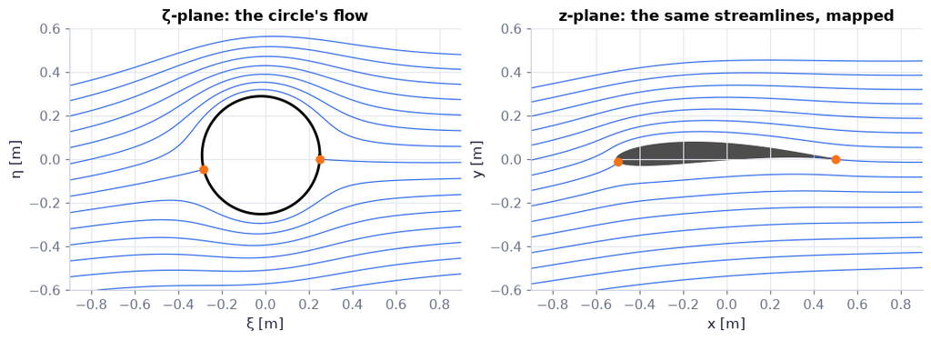

```python
GK = F.Gamma_kutta                                           # the Kutta circulation of our section [m²/s], clockwise
w_k, dw_k = CONF.circle_flow_zeta(U=sec["U"], a=a, Gamma_cw=GK, alpha=sec["alpha"], center=mu)   # the circle's flow with that circulation
st = AF.stagnation_points(**SEC)                             # front and rear stagnation points in both planes
nx, ny = (160, 100) if not FAST else (100, 64)               # grid size
XZ, YZ = np.meshgrid(np.linspace(-0.9, 0.9, nx), np.linspace(-0.6, 0.6, ny))   # the same window in both planes [m]
psi_zeta = np.imag(w_k(XZ + 1j*YZ))                          # stream function in the circle plane
psi_zeta[np.abs(XZ + 1j*YZ - mu) < a] = np.nan               # no fluid inside the circle
psi_z = F.stream(x=XZ, y=YZ)                                 # stream function in the airfoil plane (NaN inside the section)
levels = np.linspace(-14.0, 14.0, 15)                        # the same 15 streamlines in both panels [m²/s]; 0 is the body
fig, (axa, axb) = plt.subplots(1, 2, figsize=(10.0, 3.6))    # left: ζ-plane; right: z-plane
axa.contour(XZ, YZ, psi_zeta, levels=levels, colors=COLORS["blue"], linewidths=0.8, linestyles="solid")   # streamlines round the circle
axa.plot((mu + a*np.exp(1j*tcirc)).real, (mu + a*np.exp(1j*tcirc)).imag, color="k")   # the circle
axa.plot([st["zeta_front"].real, st["zeta_rear"].real], [st["zeta_front"].imag, st["zeta_rear"].imag], "o", color=COLORS["orange"])   # its stagnation points
axa.set(xlabel="ξ [m]", ylabel="η [m]", title="ζ-plane: the circle's flow")   # labels
axb.contour(XZ, YZ, psi_z, levels=levels, colors=COLORS["blue"], linewidths=0.8, linestyles="solid")      # streamlines round the airfoil
axb.fill(S["x"], S["y"], color="0.3")                        # the section
axb.plot([st["z_front"].real, st["z_rear"].real], [st["z_front"].imag, st["z_rear"].imag], "o", color=COLORS["orange"])   # its stagnation points
axb.set(xlabel="x [m]", ylabel="y [m]", title="z-plane: the same streamlines, mapped")   # labels
for ax in (axa, axb): ax.set_aspect("equal")                 # true proportions
plt.show()                                                   # display
```

**What you see.** The same fifteen streamlines in the two planes: round the circle (left) and round our section (right), with the front and rear stagnation points as amber dots.

**How to read it.** Partner points carry the same stream-function value, so each streamline on the left is the pre-image of one on the right. The rear dot sits at the point of the circle that maps to the tail. Far from the body the two pictures are the same; near it the right one is squeezed flat.

**What would change if…** …Γ were not the Kutta value? The rear dot would sit beside the tail and a streamline would wrap round it: C06.

```python
def edge_speeds(f):                                          # speed along the last 5 % of the upper surface for one circulation Γ = f·Γ_K
    Sf = AF.zhukhovsky_surface(**SEC, n=2000, Gamma_cw=f*GK) # surface speeds with this circulation
    up = Sf["upper"]                                         # the upper surface, x/c increasing
    keep = (up["xc"] > 0.95) & np.isfinite(up["speed"])      # last 5 % of the chord, without the (possibly infinite) edge value
    return {"upper surface, last 5 % of the chord": (up["xc"][keep], np.log10(up["speed"][keep]/sec["U"]))}   # log10 of q/U: +1 means ten times U
figF3 = slider_figure(edge_speeds, "Γ/Γ_K (Γ clockwise)", np.linspace(0.5, 1.5, 21), unit="", xlabel="x/c [–]",
                      ylabel="log10(q/U) [–]", xrange=[0.95, 1.0005], yrange=[-0.3, 1.3], active=10,
                      title="Only at Γ/Γ_K = 1.00 does the speed stay finite at the edge")   # 21 slider positions, starting at 1.00
figF3.show()                                                 # display
```

[interactive chart not shown]

**What does the code above do?**

1. `AF.zhukhovsky_surface` returns the speed on the contour; `Gamma_cw=f*GK` sets a circulation off the Kutta value.
2. The trace is the base-10 logarithm of speed over $U$ on the last 5 % of the upper surface: 0 means $q=U$, 1 means $10\,U$.

**What you see.** The speed on the upper surface close to the trailing edge, on a logarithmic scale, for circulations from half to one and a half times the Kutta value.

**How to read it.** At 1.00 the curve runs flat into the edge at a value a little below zero (a speed just under $U$). At every other slider position it turns upward at the right-hand end — the closer to the edge, the faster — because the map's factor $\zeta^2/(\zeta^2-b^2)$ is infinite there and the circle's flow no longer vanishes to cancel it.

**What would change if…** …you looked ten times closer to the edge? At 1.00 nothing changes; at every other position the upturn would be about three times higher (√10: the inverse-square-root law of C02).

**What would change if…** …we *demand* a finite speed at the tail? That single demand fixes Γ, and with it the lift: C06.

### 🧩 The lift of a Zhukhovsky airfoil: $\Gamma=4\pi Ua\sin(\alpha+\beta)$ (14.11) ⇒ $C_L\simeq2\pi(\alpha+\beta)$ (14.12) `C06`

*The question:* How much lift does a section give — and what do angle of attack and camber each contribute?

#### The problem in plain words

A pilot pulls the nose up two degrees and the lift rises by a fifth. A flap comes down and the lift rises without the nose moving at all. Both facts are in one line of geometry: the lift is proportional to the angle between the stream and one particular direction of the circle — the line from its centre to the point that becomes the tail. Tilting the wing changes that angle by α; cambering the wing changes it by β.

#### The idea

```
             circle in the ζ-plane, centre Q
                   .  -  ~  -  .
                .                 .
               (        Q ─ ─ ─ ─ ─)─ ─ ─  horizontal through Q
                .         ╲  β    .
                   ` -  . _╲_ . '
stream ↗ at α                B  (ζ = b: becomes the tail)

angle between the stream direction and the line QB  =  α + β   ← the "absolute" angle of attack
```

> 🔁 **Recap — Surface speed on a circle with circulation `R09`** (Ch. 6 §6.3). $u_\theta=-2U\sin\theta-\dfrac{\Gamma}{2\pi a}$ (14.10), the same formula as $u_\theta=-2U\sin\theta-\dfrac{\Gamma}{2\pi a}$ (6.37): the first term is the stream sliding round the circle, the second the clockwise swirl. **New here:** θ is measured from the diameter through the centre Q that is aligned with the stream.

> ⚠️ **Common confusion (trap T4):** three different θ's in this chapter — from the origin in $x=(R+b^2/R)\cos\theta$ (14.4); from the stream-aligned diameter through Q here; and a course angle in §14.9.

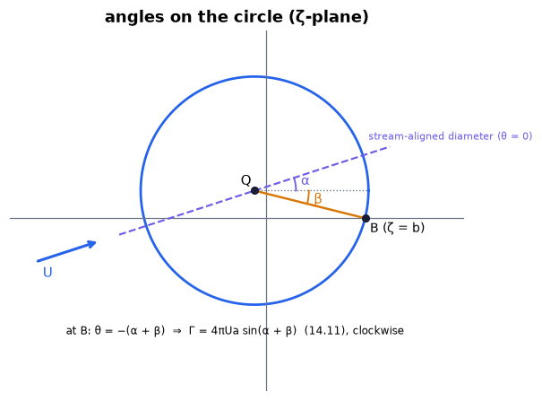

```
0.0
```

```python
fig = draw_circle_angles()                                   # the off-centre circle: centre Q, the tail point B, the angles α and β, the stream-aligned diameter
plt.show()                                                   # display the sketch the derivation below refers to
GK = AF.kutta_circulation(U=sec["U"], a=a, alpha=sec["alpha"], beta=sec["beta"])   # Eq. (14.11): the Kutta circulation of our section [m²/s], clockwise
print(ch06.cylinder_surface_speed(theta=-(sec["alpha"] + sec["beta"]), U=sec["U"], a=a, Gamma_cw=GK))   # surface speed at B, θ = −(α + β) = −9°: zero to round-off
```

> 📎 **Primer — radians and degrees for angles and for slopes.** `P338` · Formulas want radians: 1° = π/180 = 0.01745 rad. A slope "per radian" is 57.3 times a slope "per degree": 2π per radian is 0.110 per degree.

```python
print(np.deg2rad(9.0))                    # 9 degrees = 0.1571 rad
print(2*np.pi, 2*np.pi*np.pi/180)         # lift slope: 6.283 per radian = 0.1097 per degree
```

```
0.15707963267948966
6.283185307179586 0.10966227112321508
```

#### 🧮 Derivation — The Kutta circulation and the lift coefficient `D09` ★★ (Eq. 14.12: $C_L=\dfrac{L}{(1/2)\rho U^2c}\simeq2\pi(\alpha+\beta)$)

**What we want to show.** Find the one circulation that keeps the trailing-edge speed finite, and the lift it gives.

**Assumptions.** The Kutta condition (step 4); thin section, e ≪ 1 and β ≪ 1 (step 9); small α + β in radians (step 10).

**The plan.**

1. Find the angle of B (the point that becomes the tail).
2. Demand zero speed there.
3. Solve for Γ.
4. Turn Γ into a lift, then a coefficient.
5. Simplify for thin sections and small angles.

**Tools we use** (each explained before this point): geometry of the offset circle (`draw_circle_angles()`) · sin(−x) = −sin x · the lift theorem (R04, D08) · the section coefficient (P336) · small angles (P100, reminder · P338)

**We start from**

$$ u_\theta=-2U\sin\theta-\dfrac{\Gamma}{2\pi a}\ \text{(14.10), the tangential speed on the circle} $$

*In words:* Stream sliding round the circle, plus the clockwise swirl; θ measured from the diameter through Q that is aligned with the stream

**Step 1 of 10 — Locate B from the centre Q.**

$$ b-\mu=a\,e^{-i\beta} $$

- *Why we can do this:* Our circle has centre μ = b − $ae^{−iβ}$ (N25), so the point ζ = b lies at the angle −β seen from Q: β below the ξ-direction.
- *In words:* The tail point sits β below the horizontal through the centre.

**Step 2 of 10 — Note the direction θ is measured from.**

$$ \theta=0\ \text{points along the stream, at angle }\alpha\text{ above the }\xi\text{-direction} $$

- *Why we can do this:* The Start, $u_\theta=-2U\sin\theta-\Gamma/(2\pi a)$ (14.10), is the cylinder formula of Chapter 6, where θ is measured from the downstream direction; here the stream is tilted up by α.
- *In words:* The reference direction is tilted up by the angle of attack.

**Step 3 of 10 — Express B in that angle.**

$$ \theta_B=-\beta-\alpha=-(\alpha+\beta) $$

- *Why we can do this:* Angle from the ξ-direction (−β) minus the angle of the reference direction (+α).
- *In words:* Seen from the stream direction, the tail point is α + β below.

**Step 4 of 10 — Impose the Kutta condition.**

$$ u_\theta(\theta_B)=0 $$

- *Why we can do this:* By $\frac{dw}{dz}=\frac{dw}{d\zeta}\frac{\zeta^2}{\zeta^2-b^2}$ (14.9) the airfoil's speed at the tail is the circle's speed there times an infinite factor; it stays finite only if the circle's flow stagnates at B (C02).
- *In words:* The circle's rear stagnation point must sit exactly on B.

**Step 5 of 10 — Insert the angle.**

$$ 0=-2U\sin\!\big(-(\alpha+\beta)\big)-\dfrac{\Gamma}{2\pi a}=2U\sin(\alpha+\beta)-\dfrac{\Gamma}{2\pi a} $$

- *Why we can do this:* Put θ_B into the speed formula of the Start; sin(−x) = −sin x turns the first term positive.
- *In words:* The swirl must cancel the stream's sliding speed at B.

**Step 6 of 10 — Solve for Γ.**

$$ \Gamma=4\pi Ua\sin(\alpha+\beta)\ \text{(14.11)} $$

- *Why we can do this:* Step 5 is one linear equation for Γ: move the swirl term to the other side and multiply by 2πa. This is the half-way result the lift is built on.
- *In words:* The clockwise circulation the sharp tail demands: proportional to speed, size and the sine of the absolute angle.

**Step 7 of 10 — Turn it into a lift.**

$$ L=\rho U\Gamma=4\pi\rho U^2a\sin(\alpha+\beta) $$

- *Why we can do this:* The lift theorem $L=\rho U\Gamma$ (6.62), valid on the airfoil with the circle's Γ (D08). Per unit span.
- *In words:* Lift per metre of span.

**Step 8 of 10 — Make it a coefficient.**

$$ C_L=\dfrac{L}{\tfrac12\rho U^2c}=8\pi\,\dfrac ac\,\sin(\alpha+\beta) $$

- *Why we can do this:* Divide by the dynamic pressure times the chord (P336). No approximation yet: this is exact for a Zhukhovsky section (ours).
- *In words:* The exact lift coefficient; it needs the ratio of the circle's radius to the chord.

**Step 9 of 10 — Use the thin-section chord.**

$$ c\simeq4a\ \Rightarrow\ C_L\simeq2\pi\sin(\alpha+\beta) $$

- *Why we can do this:* For e ≪ 1 and β ≪ 1, a ≃ b and $c\simeq4b$ (14.8), so a/c ≃ ¼. The book writes c ≃ 4a here, c ≃ 4b there (slip #8): both first order.
- *In words:* For a thin section the geometry drops out.

**Step 10 of 10 — Use small angles.**

$$ C_L\simeq2\pi(\alpha+\beta)\ \text{(14.12)} $$

- *Why we can do this:* sin x ≃ x for x ≪ 1 in radians; at 9° the error is 0.4 %.
- *In words:* Lift coefficient = 2π times the absolute angle of attack, in radians.

**Result**

$$ \Gamma=4\pi Ua\sin(\alpha+\beta)\ \text{and}\ C_L\simeq2\pi(\alpha+\beta) $$

*In words:* a slope of 2π per radian, shifted by the camber

**What it means.** Angle of attack and camber act through their sum; each degree is worth 0.11 of lift coefficient. **Fails when:** the boundary layer separates before the tail (stall): then the Kutta condition is not what the flow does.

**Check it.** Units — Γ: (m/s)(m) ✓; $C_L$ dimensionless ✓. Limits — α = −β: Γ = 0, no lift; flat plate (a = b = c/4, β = 0): $C_L=2\pi\sin\alpha$ exactly. Number — our section at α = 5°, β = 4°: Γ = 15.96 m²/s, exact $C_L$ = 1.058, rule 0.987 (the exact value is 7.2 % higher: thickness makes a/c = 0.269 instead of 0.25). Code — the root-finder that knows no formula returns the same Γ to round-off.

📝 **Notes taught inside `D09`:** **N30 [B]** the Kutta circulation $\Gamma=4\pi Ua\sin(\alpha+\beta)$ (14.11) (step 6), clockwise.

> ⚠️ **Common confusion (traps in `D09`):** B is at −(α + β), not −(α − β): β is below the horizontal through Q *and* the reference is tilted up (trap T4); the radius is a, not b; three separate approximations (thin, small camber, small angle) — thickness alone raises the slope above 2π (slip #8); α and β in radians (trap T12).

> ⚠️ **slip #8 — the book prints** “the chord length $c$ (≃ 4a)” beside $c\cong4b$ in (14.8)**; the correct form is** both are first-order statements; exactly $C_L=8\pi(a/c)\sin(\alpha+\beta)$ (step 8), and the slope exceeds 2π at finite thickness.

📝 **Note.** **N34 [B]** **The flat plate** ($e=\beta=0$, $a=b=c/4$): $\Gamma=4\pi Ub\sin\alpha$ and $C_L=2\pi\sin\alpha$ **exactly** — no thin-section or small-angle step; this is the flow of C02.

```python
print(AF.flat_plate_flow(U=30.0, b=0.25, alpha=sec["alpha"]).Gamma_kutta)   # 8.214 m²/s (clockwise): the number the root-finder of C02 found
```

```
8.214235234026143
```

> 📎 **Primer — l'Hôpital's rule for a 0/0 limit.** `P343` · If top and bottom of a fraction both go to zero at a point, the limit of the fraction is the limit of (slope of the top)/(slope of the bottom).

```python
x = sp.symbols("x")                                # a symbol
print(sp.limit(sp.sin(3*x)/sp.sin(x), x, 0))       # 3: slopes 3cos(0)/cos(0)
print(sp.limit((x**2 - 1)/(x - 1), x, 1))          # 2: slopes 2x/1 at x = 1
```

```
3
2
```

📝 **Note.** **N29 [B]** At the trailing edge $\dfrac{dw}{dz}=\dfrac{dw}{d\zeta}\,\dfrac{\zeta^2}{\zeta^2-b^2}$ (14.9) is 0/0 when the Kutta condition holds. **Not in the book — ours:** the limit is finite, $\Big\lvert\dfrac{dw}{dz}\Big\rvert_{B'}=U\,\dfrac ba\cos(\alpha+\beta)$ — stated, not derived; verified two ways in the next cell.

```python
zq = sp.symbols("zeta")                                      # a point of the ζ-plane, as a symbol
al30 = sp.pi/6                                               # flat plate (a = b = 1, U = 1) at α = 30°
dw_plate = sp.exp(-sp.I*al30) - sp.exp(sp.I*al30)/zq**2 + sp.I*2*sp.sin(al30)/zq   # circle velocity with the Kutta circulation Γ = 4π sin α, i.e. iΓ/(2πζ) = 2i sin α/ζ
top, bottom = dw_plate*zq**2, zq**2 - 1                      # Eq. (14.9) as a fraction: (dw/dζ)·ζ² over ζ² − b²
assert abs(complex(sp.N(top.subs(zq, 1)))) < 1e-12 and bottom.subs(zq, 1) == 0   # both vanish at the tail point ζ = 1: a 0/0 form
lim = sp.diff(top, zq).subs(zq, 1)/sp.diff(bottom, zq).subs(zq, 1)   # l'Hôpital: slope of the top over slope of the bottom
print(f"flat plate at 30°: |dw/dz| at the edge = {abs(complex(sp.N(lim))):.6f} U; cos 30° = {float(sp.cos(al30)):.6f}")   # 0.866025 both
print(f"our section: U (b/a) cos(α + β) = {AF.trailing_edge_speed(U=sec['U'], a=a, b=sec['b'], alpha=sec['alpha'], beta=sec['beta']):.2f} m/s = {AF.trailing_edge_speed(U=sec['U'], a=a, b=sec['b'], alpha=sec['alpha'], beta=sec['beta'])/sec['U']:.3f} U")   # 27.37 m/s = 0.912 U
tab = pd.DataFrame({f"Γ/Γ_K = {f}": [ch14.edge_speed(**SEC, d=d_, Gamma_cw=f*GK)/sec["U"] for d_ in (1e-2, 1e-3, 1e-4, 1e-5)] for f in (1.0, 0.9, 0.5)}, index=["d = 1e-2 m", "1e-3 m", "1e-4 m", "1e-5 m"])   # speed/U at four distances d from the edge, three circulations
print(tab.round(3))                                          # the Kutta column settles; the others grow like d^(−1/2)
```

```
flat plate at 30°: |dw/dz| at the edge = 0.866025 U; cos 30° = 0.866025
our section: U (b/a) cos(α + β) = 27.37 m/s = 0.912 U
            Γ/Γ_K = 1.0  Γ/Γ_K = 0.9  Γ/Γ_K = 0.5
d = 1e-2 m        0.930        0.935        1.018
1e-3 m            0.918        0.953        1.550
1e-4 m            0.914        1.205        4.024
1e-5 m            0.913        2.638       12.407
```

**What does the code above do?**

1. The sympy part builds the circle velocity of a flat plate with the Kutta circulation, checks that top and bottom of $\dfrac{dw}{dz}=\dfrac{dw}{d\zeta}\,\dfrac{\zeta^2}{\zeta^2-b^2}$ (14.9) both vanish at the edge, and applies l'Hôpital's rule (the primer just above): the result has the size cos 30°, as the formula of N29 says.
2. `AF.trailing_edge_speed` evaluates $U(b/a)\cos(\alpha+\beta)$ for our section: 27.37 m/s = 0.912 $U$.
3. The table (trap T8): with the Kutta circulation the speed tends to 0.912 $U$ as the distance $d$ shrinks; with 0.9 or 0.5 of it the speed grows like $d^{-1/2}$.

📝 **Note.** **N31 [B]** α + β is the **absolute angle of attack**; the lift vanishes at $\alpha_{L=0}=-\beta$, and for these sections $\beta=2\,\dfrac{\text{camber}}{c}$. More camber slides the whole lift line to the left.

> ⚠️ **Common confusion (trap T3):** β is the circle's camber angle here; in §14.6 the same letter is *defined* as minus the zero-lift angle of whatever section the wing has.

```python
aL0 = AF.zero_lift_angle(camber_ratio=0.035)                 # zero-lift angle of a section with 3.5 % camber [rad]
print(f"zero-lift angle = {aL0:.3f} rad = {np.degrees(aL0):.1f}°")   # −0.070 rad = −4.0° = −β of our section
```

```
zero-lift angle = -0.070 rad = -4.0°
```

#### ✏️ Tiny example: lift by hand

$U$ = 10 m/s, $a$ = 0.25 m (chord ≈ 1 m), ρ = 1.2 kg/m³, and α + β = 30° so that the sine is easy.

1. $\Gamma=4\pi Ua\sin(\alpha+\beta)$ (14.11) = 4π × 10 × 0.25 × 0.5 = 15.7 m²/s (clockwise).
2. $L=\rho U\Gamma$ (6.62) = 1.2 × 10 × 15.7 = 188 N per metre.
3. $C_L=L/(\tfrac12\rho U^2c)$ = 188/(0.5 × 1.2 × 100 × 1) = 3.14 (= 2π sin 30°).
4. The small-angle form $C_L\simeq2\pi(\alpha+\beta)$ (14.12) gives 2π × 0.524 = 3.29 — 5 % high at 30°, which is far beyond where a real section has stalled.
5. A realistic case: α = 5°, β = 4°: α + β = 0.157 rad, $C_L$ ≈ 0.99, and sine and angle differ by 0.4 %.

```python
GK = AF.kutta_circulation(U=sec["U"], a=a, alpha=sec["alpha"], beta=sec["beta"])   # Eq. (14.11): Γ = 4πUa sin(α + β) [m²/s], clockwise
L_sec = ch06.lift_per_span(rho=sec["rho"], U=sec["U"], Gamma_cw=GK)                 # Eq. (6.62): L = ρUΓ [N per metre of span]
CL_rule = AF.zhukhovsky_lift_coefficient(alpha=sec["alpha"], beta=sec["beta"])      # Eq. (14.12): 2π(α + β)
CL_exact = AF.zhukhovsky_lift_coefficient(alpha=sec["alpha"], beta=sec["beta"], e=sec["e"], exact=True)   # 8π(a/c) sin(α + β) with the measured chord
G_root = AF.kutta_circulation_root(**SEC)                    # the root-finder of C02 (it knows no formula), for our section
print(f"Γ_K = {GK:.3f} m²/s (clockwise); root-finder: {G_root:.3f} m²/s")           # 15.962 twice
print(f"L = {L_sec:.1f} N/m; C_L = {CL_rule:.3f} (rule), {CL_exact:.3f} (exact), ratio {CL_exact/CL_rule:.3f}")   # 586.6; 0.987; 1.058; 1.072
```

```
Γ_K = 15.962 m²/s (clockwise); root-finder: 15.962 m²/s
```

```
L = 586.6 N/m; C_L = 0.987 (rule), 1.058 (exact), ratio 1.072
```

**What does the code above do?**

1. `AF.kutta_circulation` is $\Gamma=4\pi Ua\sin(\alpha+\beta)$ (14.11): 15.962 m²/s clockwise for our section (α = 5°, β = 4°, so α + β = 9° = 0.157 rad).
2. `ch06.lift_per_span` is $L=\rho U\Gamma$ (6.62): 586.6 N per metre of span.
3. `AF.zhukhovsky_lift_coefficient` gives the rule $C_L\simeq2\pi(\alpha+\beta)$ (14.12), 0.987, and with `exact=True` the exact value 1.058.
4. The exact value is 7.2 % above the rule: thickness makes $a$ larger than $c/4$ (slip #8). The root-finder of C02 agrees with the formula to round-off.

```python
U, alpha, beta, e = sec["U"], sec["alpha"], sec["beta"], sec["e"]   # speed [m/s], angle of attack [rad], camber angle [rad], thickness parameter
G = 4*np.pi*U*a*np.sin(alpha + beta)                         # Eq. (14.11): the Kutta circulation [m²/s], clockwise
c = sh["chord"]                                              # the measured chord [m]
CL = 2*G/(U*c)                                               # lift coefficient: ρUΓ/(½ρU²c) = 2Γ/(Uc)
assert np.isclose(CL, AF.zhukhovsky_lift_coefficient(alpha=alpha, beta=beta, e=e, exact=True), rtol=1e-6)   # same number → the library does exactly this
print(f"C_L = {CL:.4f}")                                     # 1.0583
```

```
C_L = 1.0583
```

**What does the code above do?**

Three lines: the circulation from $\Gamma=4\pi Ua\sin(\alpha+\beta)$ (14.11), the measured chord, and $C_L=2\Gamma/(Uc)$. The assert compares with the tested function.

```python
al_deg = np.linspace(-10.0, 15.0, 101)                       # angle of attack on the horizontal axis [degrees]
def lift_lines(beta_deg):                                    # lift coefficient against α for one camber angle
    B_ = np.deg2rad(beta_deg)                                # degrees on the slider, radians in the formulas
    rule = AF.zhukhovsky_lift_coefficient(alpha=np.deg2rad(al_deg), beta=B_)                       # Eq. (14.12): 2π(α + β)
    k8 = AF.zhukhovsky_lift_coefficient(alpha=0.1, beta=B_, e=0.08, exact=True)/np.sin(0.1 + B_)   # the factor 8π a/c of the exact formula, read off one call (the chord does not depend on α)
    exact = k8*np.sin(np.deg2rad(al_deg) + B_)               # exact value 8π(a/c) sin(α + β) at e = 0.08
    return {"rule 2π(α + β): slope 0.110 per degree": (al_deg, rule), "exact, e = 0.08 (slope about 7 % higher)": (al_deg, exact),
            "zero-lift angle α = −β": (np.array([-beta_deg, -beta_deg]), np.array([-0.4, 0.4]))}   # two lines and a marker
figF4 = slider_figure(lift_lines, "camber angle β", np.linspace(0.0, 8.0, 17), unit="°", xlabel="angle of attack α [°]",
                      ylabel="lift coefficient C_L [–]", yrange=[-1.3, 2.9], title="Camber shifts the lift line; it never changes the slope")   # 17 slider positions
figF4.show()                                                 # display
```

[interactive chart not shown]

**What does the code above do?**

1. `lift_lines` returns the rule $C_L\simeq2\pi(\alpha+\beta)$ (14.12), the exact curve for $e$ = 0.08, and a short vertical marker at the zero-lift angle $\alpha=-\beta$.
2. Angles are in degrees on the axis and the slider, and converted with `np.deg2rad` before each call.

**What you see.** Lift coefficient against angle of attack, with a slider for the camber angle.

**How to read it.** The slider moves the *intercept* — the zero-lift angle slides to −β — and never the slope: 2π per radian, 0.110 per degree for the rule, about 7 % more for the section with thickness.

**What would change if…** …the section were thinner? The dashed exact line would close on the rule; the flat plate has exactly 2π sin α.

📝 **Note.** **N32 [B]** **Theory against measurement.** Measured slopes are a little below 2π — the boundary layers' *displacement thickness* (how far the layer pushes the outer flow away from the wall, Ch. 9) changes the effective shape — and the measured curve ends in stall. The figure compares $C_L\simeq2\pi(\alpha+\beta)$ (14.12), the exact curve and a **qualitative model** of a measured curve whose constants are ours.

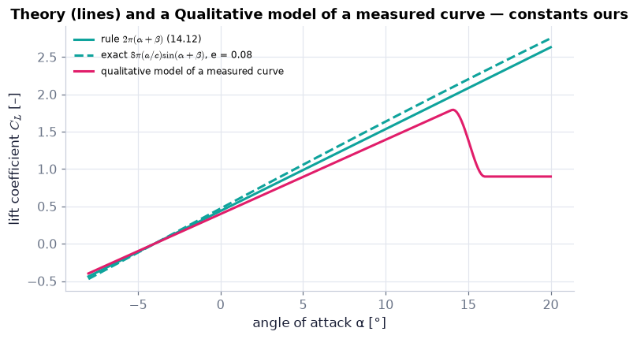

```python
al = np.deg2rad(np.linspace(-8.0, 20.0, 281))                # angles of attack [rad]
model = ch14.generic_lift_curve(alpha=al, K=5.7, beta=sec["beta"], alpha_stall=np.deg2rad(14.0), CL_post=0.9, width=np.deg2rad(2.0))   # a generic measured curve: slope 5.7/rad, stall at 14°, plateau 0.9 — constants ours
k8 = AF.zhukhovsky_lift_coefficient(alpha=0.1, beta=sec["beta"], e=sec["e"], exact=True)/np.sin(0.1 + sec["beta"])   # the factor 8π a/c of the exact formula (the chord does not depend on α)
exact = k8*np.sin(al + sec["beta"])                          # exact ideal-flow value 8π(a/c) sin(α + β)
fig, ax = plt.subplots(figsize=(6.6, 3.8))                   # one panel
ax.plot(np.degrees(al), AF.zhukhovsky_lift_coefficient(alpha=al, beta=sec["beta"]), color=COLORS["teal"], label=r"rule $2\pi(\alpha+\beta)$ (14.12)")   # the rule
ax.plot(np.degrees(al), exact, color=COLORS["teal"], ls="--", label=r"exact $8\pi(a/c)\sin(\alpha+\beta)$, e = 0.08")   # the exact ideal value
ax.plot(np.degrees(al), model, color=COLORS["rose"], label="qualitative model of a measured curve")   # the model with stall
ax.set(xlabel="angle of attack α [°]", ylabel="lift coefficient $C_L$ [–]", title="Theory (lines) and a Qualitative model of a measured curve — constants ours")   # labels
ax.legend(fontsize=8); plt.show()                            # legend and display
```

**What you see.** Two ideal-flow lines (rule and exact) and a rose curve that follows them at a slightly lower slope, then bends over and drops at 14°.

**How to read it.** All three cross zero at α = −4° = −β. Below stall the rose curve is a straight line a little flatter than the theory. At the stall angle it leaves the line: the Kutta condition no longer describes the flow. The stall angle, the plateau and the slope 5.7 per radian are our illustrative constants, not data.

**What would change if…** …the Reynolds number were lower? The stall would come earlier (N72 in C15); the straight part would hardly move.

> ▶️ **Live cell.** The widget below needs a running Python kernel. On the web page it is frozen — open this notebook in Colab (button at the top) or run it locally to drag the sliders.

```python
def show_section(alpha_deg=5.0, beta_deg=4.0, e=0.08):       # redraw for the slider values (angles in degrees)
    A_, B_ = np.deg2rad(alpha_deg), np.deg2rad(beta_deg)     # the functions take radians
    Fl = AF.zhukhovsky_flow(U=30.0, b=0.25, e=e, beta=B_, alpha=A_)   # the section's Kutta flow
    fig, ax = plt.subplots(figsize=(6.4, 3.4))               # one panel
    streamlines(ax=ax, flow=Fl, xlim=(-0.9, 0.9), ylim=(-0.5, 0.5), n=(120, 80), levels=21)   # streamlines and the filled section
    ax.set(xlabel="x [m]", ylabel="y [m]", title=f"α = {alpha_deg:.0f}°, β = {beta_deg:.0f}°, e = {e:.2f}: C_L = {AF.zhukhovsky_lift_coefficient(alpha=A_, beta=B_, e=e, exact=True):.3f} (rule {AF.zhukhovsky_lift_coefficient(alpha=A_, beta=B_):.3f}), Γ_K = {Fl.Gamma_kutta:.2f} m²/s clockwise")   # three numbers
    plt.show()                                               # display
_ = live(show_section, alpha_deg=(-5.0, 15.0, 1.0), beta_deg=(0.0, 10.0, 1.0), e=(0.0, 0.2, 0.02))   # three sliders (kernel only)
```

▶️ **Live cell.** These sliders need a running Python kernel, so they are frozen on this page. Press **Open in Colab** at the top (or run the notebook locally) to use them.

**What does the code above do?** Three sliders — angle of attack, camber angle (both in degrees) and thickness parameter — redraw the section with its streamlines and print the exact lift coefficient, the rule and the Kutta circulation. The slider figure above carries the same idea on the web page.

#### 🎮 Interactive: Which circulation does a wing choose?

**Why interactive rather than a static figure:** sliding Γ and watching the rear stagnation point crawl to the edge while the edge-speed readout falls from unbounded to a finite number — and rises again past the Kutta value — is the hypothesis as an experiment.

Start with the **Walkthrough**; the **Explain** tab works every number out with your settings, and the **Derivation** tab (where there is one) steps through the same derivation as above. Γ is the clockwise circulation in every readout; angles are shown in degrees and computed in radians.

**What to try:**

- Drag Γ/Γ_K from 0 to 1 and watch the amber dot reach the tail.
- Press 'too much': where is the rear stagnation point now?
- Set α = −β: what circulation does the edge ask for?
- Open the Derivation tab at step 3 and find the angle α + β in the circle view.

```python
show_viz("ch14", "kutta_condition")   # full-width explainer; ⤢ Full screen for more room
```

🎮 Interactive 3/9 Which circulation does a wing choose? Open alone ↗

[interactive chart not shown]

#### 🎮 Interactive: Does more angle always mean more lift?

**Why interactive rather than a static figure:** dragging α along the curve while the section view goes from attached to separated, with camber shifting the line and the regime chips moving the stall point, lets you find slope, shift and limit by experiment.

Start with the **Walkthrough**; the **Explain** tab works every number out with your settings, and the **Derivation** tab (where there is one) steps through the same derivation as above. Γ is the clockwise circulation in every readout; angles are shown in degrees and computed in radians.

**What to try:**

- Raise the camber: does the slope change?
- Find the zero-lift angle and compare it with −β.
- Put the flap down and read the new stall speed.
- Go just past stall: how far below the line is the model?

```python
show_viz("ch14", "lift_curve_stall")   # full-width explainer; ⤢ Full screen for more room
```

🎮 Interactive 4/9 Does more angle always mean more lift? Open alone ↗

[interactive chart not shown]

📝 **Note.** **N33 [C] · N35 [C]** - **N33 [C]** Zhukhovsky sections are not used on aircraft: a cusp cannot be built, and the camber peaks at mid-chord. The Kármán–Trefftz map (a finite edge angle) is the standard relative; this book does not develop it.

- **N35 [C]** Plotting a cambered section with its streamlines, and moving a known lift coefficient to a second incidence by $C_L(\alpha_2)=C_L(\alpha_1)+2\pi(\alpha_2-\alpha_1)$: `scripts/ch14_zhukhovsky_airfoil.py` does both with our parameters.

**What would change if…** …we ask *where on the surface* this lift is produced? C07 looks at the pressure.

### 🧩 Surface speed and pressure: $C_p=1-\dfrac{\lvert dw/dz\rvert^2}{U^2}$ on the contour (ours) `C07`

*The question:* Is a wing pushed up from below or pulled up from above — and where?

#### The problem in plain words

Put your hand out of a car window, palm tilted up. It feels pushed from below. A real wing is mostly *pulled* from above: the air speeds up over the curved upper surface, its pressure drops, and that suction — strongest just behind the nose — does most of the lifting. The same picture shows the wing's weak spot: behind the suction peak the pressure has to climb back (an *adverse pressure gradient*), and a boundary layer made to climb too steeply gives up. That is stall. **Not in the book — ours:** the book shows this pressure figure; we compute it.

#### The idea

```
    ↑ ↑ ↑                                        −C_p
   ↑↑ ↑  ↑   ↑    ↑     suction (arrows point       │╲
 ╭──────────────────────╮   away from the surface)  │ ╲___ upper surface
(                        ───────                    │     ╲______
 ╰───────────────────────╯                          │  area = normal force
   ↑    ↑      ↑       pressure pushes up, weakly   │_________________  lower surface
                                                    └──────────────────── x/c
```

> 🔁 **Recap — The pressure coefficient `R03`** (Ch. 6 §6.3). $C_p=\dfrac{p-p_\infty}{\tfrac12\rho U^2}$: +1 at a stagnation point, 0 where the speed equals $U$, negative where the flow is faster. **New here:** aerodynamicists plot $-C_p$ upward, so suction is "up", and the two surfaces make a loop.

> 🔁 **Recap — Bernoulli** (Ch. 4 §4.9). Along a streamline of steady ideal flow $p+\tfrac12\rho q^2$ is constant, so $C_p=1-q^2/U^2$ with $q$ the local speed.

```python
print(POT.pressure_coefficient(speed=45.0, U=30.0))          # a point where the air moves at 1.5 U: C_p = 1 − 1.5² = −1.25
```

```
-1.25
```

> 🔁 **Tools from earlier chapters used in this block** (one line each; the full primers are in the chapters named)
- **closed line integral round a contour** — the symbol ∮ means: walk once round a closed curve and add up the integrand times each small step; here the curve is the outline of the section and the integrand is the pressure. *(Ch. 5, P135)*

#### The maths, step by step

1. Points of the circle: $\zeta=\mu+ae^{it}$, with $t=-\beta$ at the tail point.
2. Circle velocity $dw/d\zeta$ there (derivation D06) with the Kutta circulation $\Gamma=4\pi Ua\sin(\alpha+\beta)$ (14.11).
3. Rescale by the map: $\dfrac{dw}{dz}=\dfrac{dw}{d\zeta}\,\dfrac{\zeta^2}{\zeta^2-b^2}$ (14.9).
4. Speed: $q=\lvert dw/dz\rvert$.
5. Pressure coefficient: $C_p=1-q^2/U^2$ (Bernoulli).
6. At $t=-\beta$ the 0/0 is replaced by its limit $U(b/a)\cos(\alpha+\beta)$ (N29, trap T8).

#### 🧮 Derivation — The normal-force coefficient is the area of the pressure loop, $C_y=\displaystyle\oint C_p\,d\Big(\dfrac xc\Big)$ `D10` ★★

**What we want to show.** Turn the two pressure curves of a section into a force — and see why they are plotted as a loop. The book leaves this to an exercise.

**Assumptions.** Shear stress neglected (pressure only); x along the chord, y across it.

**The plan.**

1. Write the normal along the contour.
2. Take the component across the chord.
3. Split the contour into upper and lower surface.
4. Subtract the ambient pressure.
5. Make it dimensionless.
6. Tilt to get the lift.

**Tools we use** (each explained before this point): normal of a parametric curve (P92, reminder) · closed line integral (P135, reminder) · P337 · N08

**We start from**

$$ \text{the force on a piece of surface of length ds,}\ d\mathbf F=-p\,\mathbf n\,ds\ \text{per unit span} $$

*In words:* Pressure pushes on the surface against the outward normal **n**

**Step 1 of 7 — Write the pressure force on an element.**

$$ d\mathbf F=-p\,\mathbf n\,ds $$

- *Why we can do this:* Pressure acts normal to a surface, pushing *into* the body, hence the minus sign with **n** pointing outward.
- *In words:* Each bit of skin is pushed inward by p times its length.

**Step 2 of 7 — Express the outward normal.**

$$ \mathbf n\,ds=(dy,\ -dx) $$

- *Why we can do this:* Walking counterclockwise with the body on the left, the step is (dx, dy); turning it by −90° gives the vector pointing to the right of the walk: outward.
- *In words:* The normal times the length, in terms of the step along the contour.

**Step 3 of 7 — Take the y-component and add round the contour.**

$$ F_y=\displaystyle\oint p\,dx $$

- *Why we can do this:* $dF_y=-p\,(-dx)=p\,dx$; sum over the closed contour, counterclockwise. Only the x-extent of an element matters for the force across the chord.
- *In words:* The force across the chord is the loop integral of p dx.

**Step 4 of 7 — Split into upper and lower surface.**

$$ F_y=\displaystyle\int_c^0p_u\,dx+\int_0^cp_l\,dx=-\int_0^cp_u\,dx+\int_0^cp_l\,dx $$

- *Why we can do this:* Counterclockwise from the tail the walk goes over the *upper* surface with x decreasing from c to 0, then back along the lower surface with x increasing. Reversing limits changes the sign.
- *In words:* Lower-surface pressure pushes up, upper-surface pressure pushes down.

**Step 5 of 7 — Subtract the ambient pressure.**

$$ F_y=\displaystyle\int_0^c\big[(p_l-p_\infty)-(p_u-p_\infty)\big]dx $$

- *Why we can do this:* A constant pressure all round gives no net force ($\oint p_\infty\,dx=0$), so it may be subtracted from both curves.
- *In words:* Only pressure differences from ambient matter.

**Step 6 of 7 — Divide by ½ρU²c.**

$$ C_y\equiv\dfrac{F_y}{\tfrac12\rho U^2c}=\displaystyle\int_0^1(C_{p,l}-C_{p,u})\,d\!\Big(\dfrac xc\Big)=\oint C_p\,d\!\Big(\dfrac xc\Big) $$

- *Why we can do this:* Each bracket over ½ρU² is a pressure coefficient; dx/c = d(x/c). The last form is the loop integral again.
- *In words:* The normal-force coefficient is the area between the two $C_p$ curves.

**Step 7 of 7 — Tilt from the chord to the stream.**

$$ C_L=C_y\cos\alpha-C_x\sin\alpha=\dfrac{C_y}{\cos\alpha}\ \ (\text{no drag}) $$

- *Why we can do this:* Lift is the force across the *stream*: $L=-F_x\sin\alpha+F_y\cos\alpha$ (N08). In ideal flow $D=F_x\cos\alpha+F_y\sin\alpha=0$, so $F_x=-F_y\tan\alpha$.
- *In words:* Divide the loop area by cos α to get the lift coefficient.

**Result**

$$ F_y=-\displaystyle\int_0^cp_u\,dx+\int_0^cp_l\,dx\ \text{,}\ C_y=\displaystyle\oint C_p\,d\!\Big(\dfrac xc\Big) $$

*In words:* The loop's area is the force across the chord

**What it means.** Plotting −$C_p$ upward makes the lift visible as an area, most of it from suction on the upper surface. **Fails when:** shear stress is not negligible (it adds mostly to drag), or the "no drag" step is used for a real, viscous flow — then $C_L=C_y\cos\alpha-C_x\sin\alpha$ needs the chordwise force too.

**Check it.** Units — Pa × m = N/m ✓; $C_y$ dimensionless ✓. Limits — a symmetric section at α = 0 has identical curves: zero area. Number — our section at 5°: loop area 1.054; ÷ cos 5° = 1.058 = 2Γ/(Uc) ✓. A toy loop with −0.6 above and +0.4 below: area 1.0.

📝 **Notes taught inside `D10`:** **N09 [B]** $F_y=-\displaystyle\int_0^cp_u\,dx+\int_0^cp_l\,dx$ and $C_y\equiv\dfrac{F_y}{\tfrac12\rho U^2c}=\displaystyle\oint C_p\,d\Big(\dfrac xc\Big)$: the normal-force coefficient is the area of the pressure loop.

> ⚠️ **Common confusion (traps in `D10`):** The sign of the normal on the lower surface (handled by walking the contour one way); subtracting $p_\infty$ changes nothing on a closed contour; x is along the chord, so this is the force normal to the chord — not the lift (trap T5).

#### ✏️ Tiny example: pressure by hand

$U$ = 30 m/s, ρ = 1.225 kg/m³: dynamic pressure 551 Pa.

1. A point where the speed is 45 m/s: $C_p$ = 1 − (45/30)² = −1.25, i.e. 689 Pa *below* ambient.
2. The stagnation point: $C_p$ = 1, 551 Pa above.
3. A toy loop: $C_p$ = −0.6 all along the top, +0.4 all along the bottom: $C_y$ = ∫(0.4 − (−0.6)) d(x/c) = 1.0 — and 60 % of it is suction.
4. Force normal to a 1 m chord: 1.0 × 551 × 1 = 551 N per metre of span.

```python
Sf = AF.zhukhovsky_surface(**SEC, n=2000)                    # speed and pressure on the contour of our section (Kutta circulation), 2000 steps round the circle
up, lo = Sf["upper"], Sf["lower"]                            # the two surfaces, each with x/c increasing
Cy = AF.normal_force_coefficient(xc_upper=up["xc"], cp_upper=up["cp"], xc_lower=lo["xc"], cp_lower=lo["cp"])    # area of the pressure loop
CL_ideal = AF.lift_from_cp(xc_upper=up["xc"], cp_upper=up["cp"], xc_lower=lo["xc"], cp_lower=lo["cp"], alpha=sec["alpha"], suction="ideal")   # C_y/cos α: no drag
CL_none = AF.lift_from_cp(xc_upper=up["xc"], cp_upper=up["cp"], xc_lower=lo["xc"], cp_lower=lo["cp"], alpha=sec["alpha"], suction="none")     # C_y cos α: no leading-edge suction
print(f"suction peak C_p = {Sf['cp_min']:.2f} at x/c = {100*Sf['xc_cp_min']:.2f} % (upper surface)")   # −2.24 at 0.45 % of the chord
print(f"loop area C_y = {Cy:.3f}; C_L = {CL_ideal:.3f} (ideal), {CL_none:.3f} (no leading-edge suction)")   # 1.054; 1.058; 1.050
print(f"2Γ/(Uc) = {2*Sf['Gamma_cw']/(sec['U']*Sf['chord_x']):.3f}")                                    # 1.058: the lift coefficient from the circulation
print(f"∮u_s ds round the contour = {AF.surface_circulation(surface=Sf):.2f} m²/s (clockwise)")        # 15.96 = Γ_K: the number promised in N10
```

```
suction peak C_p = -2.24 at x/c = 0.45 % (upper surface)
loop area C_y = 1.054; C_L = 1.058 (ideal), 1.050 (no leading-edge suction)
2Γ/(Uc) = 1.058
∮u_s ds round the contour = 15.96 m²/s (clockwise)
```

**What does the code above do?**

1. `AF.zhukhovsky_surface` carries out the six steps above on 2000 points of the contour and splits them into `upper` and `lower`.
2. The suction peak is −2.24 and sits at only 0.45 % of the chord: right behind the nose, on the upper surface.
3. `AF.normal_force_coefficient` is the area of the loop, $C_y$ = 1.054.
4. The loop gives the force normal to the *chord*; the lift is normal to the *stream* (trap T5). Dividing by cos α (ideal flow, no drag) gives 1.058 — exactly $2\Gamma/(Uc)$ from the circulation.
5. `AF.surface_circulation` adds up the surface speed round the contour: 15.96 m²/s, the Kutta circulation. The faster flow over the top *is* the circulation (N10).

```python
U, b, al, beta = sec["U"], sec["b"], sec["alpha"], sec["beta"]   # speed [m/s], map constant [m], angle of attack and camber angle [rad]
t = -beta + 2*np.pi*np.arange(1, 2000)/2000                  # 1999 angles round the circle, leaving out the tail point itself (0/0 there)
zeta = mu + a*np.exp(1j*t)                                   # points of the circle
dw = U*(np.exp(-1j*al) - a**2*np.exp(1j*al)/(zeta - mu)**2) + 1j*GK/(2*np.pi*(zeta - mu))   # circle velocity with the Kutta circulation
q = np.abs(dw*zeta**2/(zeta**2 - b**2))                      # Eq. (14.9), then the speed on the section [m/s]
cp = 1 - (q/U)**2                                            # Bernoulli: pressure coefficient
assert np.allclose(cp, Sf["cp"][1:], rtol=1e-9)              # same numbers → the library does exactly this
print(f"C_p from {cp.min():.3f} (suction peak) to {cp.max():.3f} (stagnation point)")   # −2.24 … 1.000
```

```
C_p from -2.237 (suction peak) to 1.000 (stagnation point)
```

**What does the code above do?**

The six steps of "the maths" as five lines of complex arithmetic on a whole array of points, compared with `AF.zhukhovsky_surface`.

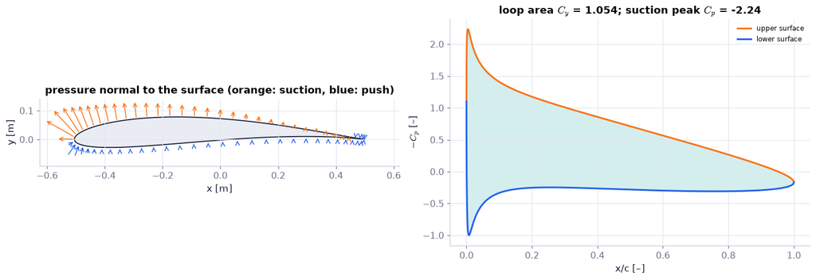

```python
fig = fig_pressure_two_ways(S=AF.zhukhovsky_surface(**SEC, n=400))   # left: pressure arrows on the section; right: −C_p against x/c for both surfaces
plt.show()                                                   # display
```

**What you see.** Left: our section with arrows normal to the surface — pointing outward where the pressure is below ambient (suction), inward where it is above. Right: $-C_p$ against $x/c$ for both surfaces, with the loop between them shaded.

**How to read it.** The tall thin spike at the nose is the suction peak; behind it the upper curve slopes down all the way to the tail — the pressure is *rising* there, which the boundary layer has to climb. The lower surface pushes up only weakly. The shaded area is the normal-force coefficient, and most of it lies above the axis: the wing is pulled up.

**What would change if…** …α were 10°? The peak would pass −7 and the slope behind it would steepen: closer to stall.

```python
def cp_loop(alpha_deg):                                      # the two pressure curves for one angle of attack
    Sx = AF.zhukhovsky_surface(U=sec["U"], b=sec["b"], e=sec["e"], beta=sec["beta"], alpha=np.deg2rad(alpha_deg), n=400)   # surface pressure at this α
    return {"upper surface": (Sx["upper"]["xc"], -Sx["upper"]["cp"]), "lower surface": (Sx["lower"]["xc"], -Sx["lower"]["cp"])}   # −C_p, so suction is up
figF5 = slider_figure(cp_loop, "angle of attack α", np.linspace(-4.0, 12.0, 17), unit="°", xlabel="x/c [–]", ylabel="−C_p [–]",
                      yrange=[-1.1, 6.0], active=9, title="The loop between the two curves is the normal force")   # 17 slider positions, starting at 5°
figF5.show()                                                 # display
rows = []                                                    # the loop area at four angles
for A_deg in (-4.0, 0.0, 5.0, 10.0):                         # angles of attack [degrees]
    Sx = AF.zhukhovsky_surface(U=sec["U"], b=sec["b"], e=sec["e"], beta=sec["beta"], alpha=np.deg2rad(A_deg), n=2000)   # surface pressure
    Cy_ = AF.normal_force_coefficient(xc_upper=Sx["upper"]["xc"], cp_upper=Sx["upper"]["cp"], xc_lower=Sx["lower"]["xc"], cp_lower=Sx["lower"]["cp"])   # loop area
    rows.append({"α [°]": A_deg, "α [rad]": np.deg2rad(A_deg), "loop area C_y": Cy_, "2Γ/(Uc)": 2*Sx["Gamma_cw"]/(sec["U"]*Sx["chord_x"]), "peak −C_p": -Sx["cp_min"]})   # collect
print(pd.DataFrame(rows).round(3).to_string(index=False))    # zero net area at α = −β = −4°
```

[interactive chart not shown]

```
 α [°]  α [rad]  loop area C_y  2Γ/(Uc)  peak −C_p
  -4.0   -0.070         -0.000    0.000      1.784
   0.0    0.000          0.472    0.472      0.637
   5.0    0.087          1.054    1.058      2.237
  10.0    0.175          1.612    1.637      7.455
```

**What does the code above do?**

1. `cp_loop` returns $-C_p$ on both surfaces for one angle of attack (degrees on the slider, radians in the call).
2. The table lists the loop area and $2\Gamma/(Uc)$ at four angles: they differ only by the factor cos α.

**What you see.** The pressure loop of our section as the angle of attack goes from −4° to 12°.

**How to read it.** At α = −4° (= −β) the two curves cross and the net area is zero: no lift. As α grows the suction peak near the nose shoots up (the vertical axis is cut at 6) and the loop opens. The area grows in step with $2\Gamma/(Uc)$.

**What would change if…** …the section were a flat plate? The peak would be infinite at the leading edge for every α ≠ 0 — a rounded nose is what keeps it finite (N12 below).

> 🔁 **Recap — The Blasius force `R10`** (Ch. 6 §6.5). $D-iL=\dfrac{i\rho}{2}\displaystyle\oint\Big(\dfrac{dw}{dz}\Big)^2dz$ (6.60): the force from a contour integral of the squared complex velocity. **New here:** with the stream inclined, the force comes out perpendicular to the *stream* — size $\rho U\Gamma$, no drag.

```python
fb = AF.zhukhovsky_force(**SEC, rho=1.225, method="blasius")    # force from the Blasius contour integral, Eq. (6.60)
fp = AF.zhukhovsky_force(**SEC, rho=1.225, method="pressure")   # force from adding up the surface pressure
for name, f_ in (("Blasius ", fb), ("pressure", fp)):         # the two routes share no line of code
    print(f"{name}: Fx = {f_['Fx']:7.2f}, Fy = {f_['Fy']:7.2f} N/m → L = {f_['L']:.2f}, D = {f_['D']:.1e} N/m; centre of pressure at {100*f_['xcp_over_c']:.1f} % chord")   # −51.1, 584.4 → 586.6, ≈ 0; 35.7 %
```

```
Blasius : Fx =  -51.13, Fy =  584.37 N/m → L = 586.60, D = 3.4e-13 N/m; centre of pressure at 35.7 % chord
pressure: Fx =  -51.13, Fy =  584.37 N/m → L = 586.60, D = 8.7e-05 N/m; centre of pressure at 35.7 % chord
```

**What does this show?** Two routes that never share a line of code agree: the force has components $F_x$ = −51.1 and $F_y$ = 584.4 N/m along and across the chord, which resolve (N08) into a lift of 586.6 N/m $=\rho U\Gamma$ and no drag. The force leans *forward* of the chord normal by exactly α. It acts at 35.7 % of the chord.

📝 **Note.** **N12 [B]** The pressure on a flat plate is normal to the plate, so why is the force normal to the stream? Because the flow whipping round the sharp *leading* edge pulls the plate forward: the **leading-edge suction** $S=L\sin\alpha=\pi\rho U^2c\sin^2\alpha$, with the normal force $N=L\cos\alpha$ (ours; stated, not derived). A rounded nose spreads that suction over a real surface — the −2.24 peak above — and keeps the boundary layer attached.

```python
fpl = AF.flat_plate_forces(rho=1.225, U=30.0, c=1.0, alpha=sec["alpha"])   # flat plate of chord 1 m at 5° in air at 30 m/s
print(f"L = {fpl['L']:.1f}, N = {fpl['N']:.1f}, S = {fpl['S']:.1f} N/m")     # 301.9, 300.7, 26.3 N/m
cv = ch14.edge_flow_suction(rho=1.225, Uo=30.0*np.sin(sec["alpha"]), a=1.0)  # control volume round the edge: near the nose the speed is U sin α · sqrt(c/r)
print(f"edge suction from the control volume = {cv['closed_form']:.1f} N/m") # 26.3 N/m: the same S
```

```
L = 301.9, N = 300.7, S = 26.3 N/m
edge suction from the control volume = 26.3 N/m
```

**What does this show?** The plate's lift is 301.9 N/m; its normal force is 300.7 N/m and the leading-edge suction 26.3 N/m. A momentum balance on a tiny circle round the edge (`ch14.edge_flow_suction`) gives the same 26.3 N/m.

📝 **Note.** **N13 [B]** **Stall.** At high α the suction-side boundary layer cannot climb the pressure rise behind the peak; it *separates* ahead of the trailing edge (where the wall shear stress $\tau_0=0$), the Kutta condition fails and the lift collapses.

> 🔁 **Recap — Thwaites' method** (Ch. 9 §9.6). It marches a laminar boundary layer along a given outer speed $U_e(x)$ and reports where the wall shear stress $\tau_0$ reaches zero — the separation point.

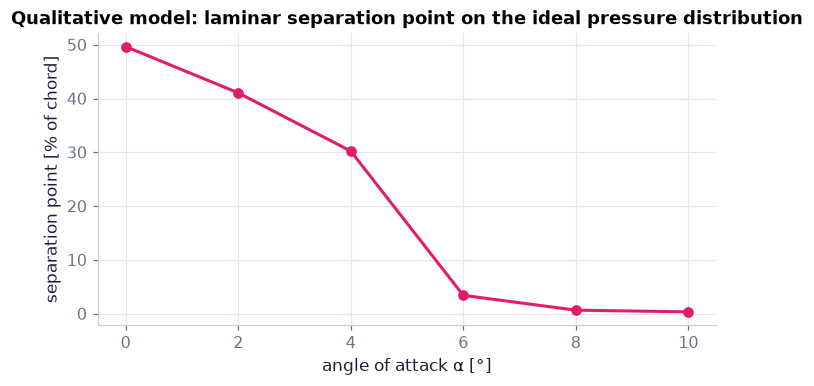

```
 α [°]  α [rad]  x_sep/c [%]
   0.0    0.000       49.653
   2.0    0.035       41.056
   4.0    0.070       30.225
   6.0    0.105        3.397
   8.0    0.140        0.641
  10.0    0.175        0.327
```

```python
angles_deg = np.array([0.0, 2.0, 4.0, 6.0, 8.0, 10.0]) if not FAST else np.array([0.0, 5.0, 10.0])   # angles of attack to try [degrees]
xsep = [ch14.suction_side_separation(alpha=np.deg2rad(A_), e=sec["e"], beta=sec["beta"], Re_c=1e6, n=120)["x_sep_over_c"] for A_ in angles_deg]   # laminar separation point on the suction side, as a fraction of the chord, at chord Reynolds number 1e6
fig, ax = plt.subplots(figsize=(6.2, 3.4))                   # one panel
ax.plot(angles_deg, 100*np.array(xsep, dtype=float), "o-", color=COLORS["rose"])   # separation position against α
ax.set(xlabel="angle of attack α [°]", ylabel="separation point [% of chord]", title="Qualitative model: laminar separation point on the ideal pressure distribution")   # labels
plt.show()                                                   # display
print(pd.DataFrame({"α [°]": angles_deg, "α [rad]": np.deg2rad(angles_deg), "x_sep/c [%]": 100*np.array(xsep, dtype=float)}).round(3).to_string(index=False))   # the numbers
```

**What you see.** Where a *laminar* boundary layer, marched by Thwaites' method along the ideal-flow surface speed, would separate on the upper surface, for several angles of attack.

**How to read it.** As α grows, the separation point moves forward toward the suction peak: the pressure rise behind the peak gets steeper and the layer gives up earlier. That forward march is the mechanism of stall.

**What would change if…** …the layer were turbulent? It would survive a much steeper rise and separate far later (N72 in C15).

> ⚠️ **Common confusion:** (trap T16) this model **cannot predict the maximum lift**: the real layer turns turbulent, and once it separates the outer flow itself changes. It shows the trend only.

#### 🎮 Interactive: Is a wing pushed up or pulled up?

**Why interactive rather than a static figure:** turning α and seeing the suction peak sharpen, the stagnation point slide under the nose and the loop area grow in step with the lift readout connects three pictures of one flow; clicking a point traces Bernoulli's arithmetic there.

Start with the **Walkthrough**; the **Explain** tab works every number out with your settings, and the **Derivation** tab (where there is one) steps through the same derivation as above. Γ is the clockwise circulation in every readout; angles are shown in degrees and computed in radians.

**What to try:**

- Raise α from 0° to 8° and watch the peak.
- Click the stagnation point: what is $C_p$ there?
- Compare the two bars 'upper suction' and 'lower pressure'.
- Choose 'flat plate': what happens to the peak?

```python
show_viz("ch14", "airfoil_pressure_lift")   # full-width explainer; ⤢ Full screen for more room
```

🎮 Interactive 5/9 Is a wing pushed up or pulled up? Open alone ↗

[interactive chart not shown]

**What would change if…** …the wing has ends? Everything so far was per metre of an endless span. §14.6.

## 14.6 Elementary Lifting Line Theory for Wings of Finite Span

**What is this section about?** A real wing has tips. The circulation must fall to zero there, a vortex cannot simply end, so vorticity streams off the wing and trails behind. That wake makes the air at the wing sink, the sinking tilts the lift backward, and the wing has a drag even in ideal flow. Seven steps: the trailing filaments, their downwash, the induced drag, a sine series, one linear system for any wing, the forces from its coefficients, and the best loading.

> ⚠️ **Axes change here (trap T5).** From here on $y$ runs **along the span** ($-s/2$ at the port tip … $+s/2$ at the starboard tip) and the downwash $w$ is positive **downward**. The letter $w$ is now a velocity, no longer the complex potential.

### 🧩 Bound vortex and trailing filaments: $d\Gamma_{\text{trail}}=-\dfrac{d\Gamma}{dy}\,dy$ `C08`

*The question:* The circulation round a wing must vanish at the tips. Where does it go?

#### The problem in plain words

On a damp day you can see two white cords streaming back from an airliner's wing tips or flap ends: tip vortices. Below a lifting wing the pressure is high, above it low; at the tips the air leaks round from below to above. That leak is the visible end of something that happens all along the trailing edge: wherever the wing carries a little less circulation than it did a step further inboard, the difference leaves as a thin vortex trailing downstream.

#### The idea

```
top view (flight direction up the page)

         Γ(y):        _.--._              the bound circulation: largest at mid-span, zero at the tips
                    .'            '.
lifting line   ════════════════════════
               ║  ║  ║          ║  ║  ║         many weak horseshoe vortices, one inside the next
               ║  ║  ╚══════════╝  ║  ║         = one bound vortex of varying strength
               ║  ╚════════════════╝  ║         + a sheet of trailing filaments
               ╚══════════════════════╝
               ↓  ↓  ↓          ↓  ↓  ↓         (the legs trail downstream)
```

> 🔁 **Tools from earlier chapters used in this block** (one line each; the full primers are in the chapters named)
- **derivative as a difference; first-order Taylor step** — over a small step dy a function changes by (df/dy)·dy; here the bound circulation changes by (dΓ/dy)·dy between two neighbouring stations, and that much is shed into the wake. *(Ch. 1, P26)*
- **point-vortex dynamics and invariants** — each point vortex moves with the velocity all the others induce where it sits, while the total circulation and the impulse ΣΓy stay constant (which checks the time stepping); here the vortices are pieces of the wing's trailing sheet. *(Ch. 5, P147)*

📝 **Note.** **N36 [B]** Air flows outward under the wing and inward over it. Behind the trailing edge the two streams meet with different spanwise velocities: a surface across which the tangential velocity jumps — a **vortex sheet** — of opposite sense on the two half-wings.

> 🔁 **Recap — vortex sheet** (Ch. 5 §5.8). A jump in tangential velocity across a surface is a sheet of vorticity whose strength per unit length equals the jump, $\gamma_{\text{sheet}}=\Delta u_{\text{tangential}}$.

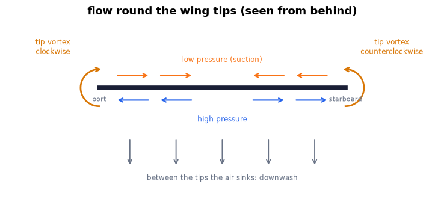

```python
fig = draw_tip_flow_rear_view()                              # rear view of a lifting wing: high pressure below, low above, the leak round each tip
plt.show()                                                   # display
```

**What you see.** A wing seen from behind: high pressure under it, low pressure over it, and the air moving outward below, inward above and round each tip.

**How to read it.** The two tip flows turn in opposite senses — the left one clockwise, the right one counterclockwise as drawn — and between the tips the air they set in motion goes *down*.

**What would change if…** …the wing carried no lift? No pressure difference, no leak, no trailing vortices.

> 🔁 **Recap — A vortex cannot end in the fluid `R11`** (Ch. 5 §5.3). Helmholtz: the strength of a vortex tube is the same all along it, $\Gamma_{\text{tube}}=\text{const}$, so a tube must close on itself or end on a boundary. **New here:** the wing's vortex system is one closed loop — the bound vortex on the wing, two trailing vortices, and far behind the starting vortex of C03.

📝 **Note.** **N39 [B]** **The three assumptions of lifting-line theory** (later blocks cite them by number):

1. the aspect ratio is large, so each spanwise strip sees a two-dimensional flow — rules out stubby and delta wings;
2. the wing is one straight bound vortex of strength $\Gamma(y)$, the **lifting line** — rules out sweep;
3. the trailing filaments are straight, parallel to the stream, and do not act on one another — rules out the roll-up we are about to watch.

📝 **Note.** **N40 [B]** The **bound vortex** moves with the wing, is strongest at mid-span and vanishes at the tips, $\Gamma(\pm s/2)=0$.

> 📎 **Primer — elliptic loading and the sine coefficients `Gn` (first look).** `P351` · Two things that later blocks teach properly are needed already. **The sine coefficients.** A loading $\Gamma(y)$ is written as a sum of sine shapes in the *span angle* γ, which runs from 0 at the port tip through π/2 at mid-span to π at the starboard tip, $y=-(s/2)\cos\gamma$: $\Gamma=\displaystyle\sum_{n=1}^{\infty}\Gamma_n\sin(n\gamma)$ (14.18). In code the list of amplitudes is `Gn=[Γ₁, Γ₂, …]` [m²/s]; C11 says why sines. **The elliptic loading** is the first sine alone, `Gn=[Γ₁]`: $\Gamma=\Gamma_1\sin(\gamma)=\Gamma_1\sqrt{1-(2y/s)^2}$ (14.23) — a half-ellipse over the span, equal to Γ₁ at mid-span and zero at both tips. It is the standard example from here on because it turns out to be the loading with the least induced drag (C14).

```python
s, G1 = 12.0, 14.17                                   # span [m] and mid-span circulation [m²/s]
y = np.array([-6.0, -3.0, 0.0, 3.0, 6.0])             # five stations along the span [m]
print((G1*np.sqrt(1 - (2*y/s)**2)).round(2))          # the half-ellipse: 0, 12.27, 14.17, 12.27, 0
```

```
[ 0.   12.27 14.17 12.27  0.  ]
```

```python
print(LL.circulation_series(Gn=np.array([12.0, 0.0, 1.0]), gamma=np.array([0.0, np.pi/2, np.pi])))   # a loading made of two sine shapes (C11), at port tip, mid-span, starboard tip: 0, 11, 0 m²/s
```

```
[ 0. 11.  0.]
```

#### 🧮 Derivation — The strength of a shed filament, $d\Gamma_{\text{trail}}=-\dfrac{d\Gamma}{dy}\,dy$ `D11` ★

**What we want to show.** Find how much vorticity leaves the wing where the bound circulation changes along the span.

**Assumptions.** The shed filament leaves straight back (lifting-line assumption (iii)).

**The plan.**

1. Balance the strength at a junction.
2. Expand the bound strength one step along the span.
3. Subtract.
4. Read the sign.

**Tools we use** (each explained before this point): Helmholtz's theorem (R11) · a first-order Taylor step (P26, reminder)

**We start from**

$$ \Gamma_{\text{tube}}=\text{the same all along a vortex tube (Helmholtz)} $$

*In words:* The strength of a vortex tube is the same all along it; a tube cannot end in the fluid (recap R11).

**Step 1 of 4 — Balance the strength at a junction.**

$$ \Gamma(y)=\Gamma(y+dy)+d\Gamma_{\text{trail}} $$

- *Why we can do this:* Between y and y + dy the bound vortex splits into the part that continues along the wing and the part that turns downstream; the total strength is conserved (Helmholtz).
- *In words:* What arrives equals what goes on plus what leaves.

**Step 2 of 4 — Expand the bound strength.**

$$ \Gamma(y+dy)=\Gamma(y)+\dfrac{d\Gamma}{dy}\,dy $$

- *Why we can do this:* First-order Taylor step for a small dy: value plus slope times step.
- *In words:* The bound vortex a little further out differs by its slope times dy.

**Step 3 of 4 — Subtract.**

$$ d\Gamma_{\text{trail}}=-\dfrac{d\Gamma}{dy}\,dy $$

- *Why we can do this:* Insert step 2 into step 1 and cancel Γ(y).
- *In words:* A filament leaves with the strength the bound vortex has lost.

**Step 4 of 4 — Read the sign on each half.**

$$ y>0:\ \dfrac{d\Gamma}{dy}<0\Rightarrow d\Gamma_{\text{trail}}>0;\qquad\displaystyle\int_{-s/2}^{s/2}\!\!-\dfrac{d\Gamma}{dy}\,dy=\Gamma(-\tfrac s2)-\Gamma(\tfrac s2)=0 $$

- *Why we can do this:* Γ falls toward the starboard tip and rises from the port tip; the integral is exact because Γ vanishes at both tips.
- *In words:* The two half-wings shed vorticity of opposite sense, and equal amounts.

**Result**

$$ d\Gamma_{\text{trail}}=-\dfrac{d\Gamma}{dy}\,dy $$

*In words:* Every drop in the bound circulation trails off as a vortex

**What it means.** The trailing vorticity is strongest where Γ changes fastest — near the tips; each half-sheet carries the mid-span circulation Γ₀ in total. **Fails when:** nothing here says the filaments stay straight — they roll up (N37).

**Check it.** Units — (m²/s per m) × m = m²/s ✓. Number — a staircase 10, 8, 5, 0 m²/s sheds 2, 3 and 5 m²/s: total 10 = the root value. Limit — constant Γ sheds nothing except at the tips (the horseshoe).

> ⚠️ **Common confusion (traps in `D11`):** The sign (dΓ < 0 for dy > 0 on the starboard half gives a positive shed strength); the two half-sheets rotate in opposite senses.